# Cell cycle dynamics of synthetic mRNA-induced β-cell proliferation

## 16.2 Models

### 16.2.1 Choose model

AIC/BIC

**Open code**

```r
model_NR <- glmmTMB::glmmTMB(
  Proportion ~ Time,
  data = data_long %>%
    filter(
      grepl('G0G1_CYCLE_FC', Table),
      !is.na(Proportion)
    ) %>%
    mutate(Time = factor(Time)),
  REML = FALSE
)

model_RI <- glmmTMB::glmmTMB(
  Proportion ~ Time + (1 | Experiment),
  data = data_long %>%
    filter(
      grepl('G0G1_CYCLE_FC', Table),
      !is.na(Proportion)
    ) %>%
    mutate(Time = factor(Time)),
  REML = FALSE
)

model_NR_difvar <- glmmTMB::glmmTMB(
  Proportion ~ Time,
  data = data_long %>%
    filter(
      grepl('G0G1_CYCLE_FC', Table),
      !is.na(Proportion)
    ) %>%
    mutate(Time = factor(Time)),
  REML = FALSE,
  dispformula = ~ 0 + Time
)

model_RI_difvar <- glmmTMB::glmmTMB(
  Proportion ~ Time + (1 | Experiment),
  data = data_long %>%
    filter(
      grepl('G0G1_CYCLE_FC', Table),
      !is.na(Proportion)
    ) %>%
    mutate(Time = factor(Time)),
  REML = FALSE,
  dispformula = ~ 0 + Time,
  control = glmmTMB::glmmTMBControl(
  optCtrl = list(
    iter.max = 1e6,
    eval.max = 1e6
  )
)
)
## Warning in finalizeTMB(TMBStruc, obj, fit, h, data.tmb.old): Model convergence
## problem; non-positive-definite Hessian matrix. See vignette('troubleshooting')
```

Because the ML fit of the random-intercept model with group-specific residual variance showed convergence problems, the two random-intercept models will be refitted using REML and compared only using residual diagnostics if the convergence issue will be resolved with REML.

**Open code**

```r
model_RI <- glmmTMB::glmmTMB(
  Proportion ~ Time + (1 | Experiment),
  data = data_long %>%
    filter(
      grepl('G0G1_CYCLE_FC', Table),
      !is.na(Proportion)
    ) %>%
    mutate(Time = factor(Time)),
  REML = TRUE
)

model_RI_difvar <- glmmTMB::glmmTMB(
  Proportion ~ Time + (1 | Experiment),
  data = data_long %>%
    filter(
      grepl('G0G1_CYCLE_FC', Table),
      !is.na(Proportion)
    ) %>%
    mutate(Time = factor(Time)),
  REML = TRUE,
  dispformula = ~ 0 + Time
)
```

$\Rightarrow$ Both random-intercept models re-fitted with REML, are without any convergence issue.

Diagnostics

**Open code**

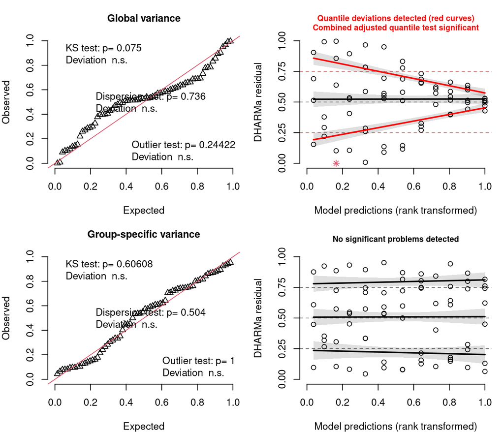

Diagnostic plots from DHARMa simulated residuals for models with and without group-specific residual variance. Top: random-intercept model with a single (global) residual variance. Bottom: random-intercept model allowing group-specific residual variance. Left: quantile–quantile plot comparing simulated residuals to the expected distribution. Right: residuals plotted against predicted values; black lines show the median (0.5) and lower/upper quartiles (0.25, 0.75) with shaded 95% simulation envelopes. Deviations from expected values suggest potential model misspecification

```r
set.seed(709)

res1 <- simulateResiduals(model_RI, n = 500)
res2 <- simulateResiduals(model_RI_difvar, n = 500)

op <- par(mfrow = c(2, 2), mar = c(4, 4, 3, 1))

plotQQunif(res1, main = "Global variance")
plotResiduals(res1, main = "")

plotQQunif(res2, main = "Group-specific variance")
plotResiduals(res2, main = "")
```

**Open code**

```r
par(op)
```

$\Rightarrow$ Addition group-specific residual variance substantially improved diagnostics. We will use random-intercept model with allowance of the group-specific residual variance.

### 16.2.2 Fit final model

**Open code**

```r
model_final <- glmmTMB::glmmTMB(
  Proportion ~ Time + (1 | Experiment),
  data = data_long %>%
    filter(
      grepl('G0G1_CYCLE_FC', Table),
      !is.na(Proportion)
    ),
  REML = TRUE,
  dispformula = ~ 0 + Time
)
```

### 16.2.3 Results

**Open code**

```r
kableExtra::kable(car::Anova(model_final))
```

|  | Chisq | Df | Pr(>Chisq) |
| --- | --- | --- | --- |
| Time | 3514.201 | 11 | 0 |

**Open code**

```r
summary(model_final)
##  Family: gaussian  ( identity )
## Formula:          Proportion ~ Time + (1 | Experiment)
## Dispersion:                  ~0 + Time
## Data: data_long %>% filter(grepl("G0G1_CYCLE_FC", Table), !is.na(Proportion))
##
##      AIC      BIC   logLik deviance df.resid
##    363.5    419.7   -156.7    313.5       57
##
## Random effects:
##
## Conditional model:
##  Groups     Name        Variance  Std.Dev.
##  Experiment (Intercept) 1.228e-09 3.505e-05
##  Residual                      NA        NA
## Number of obs: 70, groups:  Experiment, 7
##
## Conditional model:
##                       Estimate Std. Error z value Pr(>|z|)
## (Intercept)            99.4314     0.1762   564.5  < 2e-16 ***
## Time12 hours           -3.7057     0.6093    -6.1 1.19e-09 ***
## Time14 hours          -13.6286     1.1613   -11.7  < 2e-16 ***
## Time18 hours          -29.8057     1.7509   -17.0  < 2e-16 ***
## Time20 hours          -40.1271     2.0265   -19.8  < 2e-16 ***
## Time24 hours          -55.9943     2.8522   -19.6  < 2e-16 ***
## TimeControl 24 hours   -3.3214     0.4539    -7.3 2.53e-13 ***
## Time40 hours          -71.8314     5.2852   -13.6  < 2e-16 ***
## Time32 hours          -65.5134     2.1771   -30.1  < 2e-16 ***
## Time50 hours          -79.2139     2.6429   -30.0  < 2e-16 ***
## Time70 hours          -77.8739     4.2058   -18.5  < 2e-16 ***
## TimeControl 70 hours   -7.5139     0.5793   -13.0  < 2e-16 ***
## ---
## Signif. codes:  0 '***' 0.001 '**' 0.01 '*' 0.05 '.' 0.1 ' ' 1
##
## Dispersion model:
##                       Estimate Std. Error z value Pr(>|z|)
## Time0 hours           -0.76344    0.28868  -2.645 0.008178 **
## Time12 hours           0.43393    0.28868   1.503 0.132789
## Time14 hours           1.11088    0.28868   3.848 0.000119 ***
## Time18 hours           1.52799    0.28868   5.293 1.20e-07 ***
## Time20 hours           1.67546    0.28868   5.804 6.48e-09 ***
## Time24 hours           2.01914    0.28868   6.995 2.66e-12 ***
## TimeControl 24 hours   0.02443    0.31623   0.077 0.938413
## Time40 hours           2.46907    0.35355   6.984 2.88e-12 ***
## Time32 hours           1.57944    0.35355   4.467 7.92e-06 ***
## Time50 hours           1.66281    0.40825   4.073 4.64e-05 ***
## Time70 hours           2.12874    0.40825   5.214 1.84e-07 ***
## TimeControl 70 hours   0.09878    0.40825   0.242 0.808812
## ---
## Signif. codes:  0 '***' 0.001 '**' 0.01 '*' 0.05 '.' 0.1 ' ' 1

contrast <- con_tab(model_final)

kableExtra::kable(
  contrast,
  caption = "Estimated pairwise differences in the proportion of G0G1-phase EdU⁻ β cells (%; flow cytometry), obtained from a linear mixed-effects model with experiment as a random intercept, time as a categorical predictor, and allowance for group-specific residual variance. Columns: `contrast` (time points compared), `estimate` (mean difference in %), `CI` (Bonferroni-adjusted 95% confidence interval [lower, upper]), `SE` (standard error), `df` (degrees of freedom), `t.ratio` (test statistic), `p.value` (Bonferroni-adjusted p-value), and `stars` (significance code)"
)
```

Estimated pairwise differences in the proportion of G0G1-phase EdU⁻ β cells (%; flow cytometry), obtained from a linear mixed-effects model with experiment as a random intercept, time as a categorical predictor, and allowance for group-specific residual variance. Columns: `contrast` (time points compared), `estimate` (mean difference in %), `CI` (Bonferroni-adjusted 95% confidence interval [lower, upper]), `SE` (standard error), `df` (degrees of freedom), `t.ratio` (test statistic), `p.value` (Bonferroni-adjusted p-value), and `stars` (significance code)

| contrast | estimate | CI | SE | df | t.ratio | p.value | stars |
| --- | --- | --- | --- | --- | --- | --- | --- |
| 0 hours - 12 hours | 3.71 | [1.54, 5.87] | 0.61 | 57 | 6.08 | 0.0000070 | *** |
| 0 hours - 14 hours | 13.63 | [9.49, 17.76] | 1.16 | 57 | 11.74 | 0.0000000 | *** |
| 0 hours - 18 hours | 29.81 | [23.57, 36.04] | 1.75 | 57 | 17.02 | 0.0000000 | *** |
| 0 hours - 20 hours | 40.13 | [32.91, 47.34] | 2.03 | 57 | 19.80 | 0.0000000 | *** |
| 0 hours - 24 hours | 55.99 | [45.84, 66.15] | 2.85 | 57 | 19.63 | 0.0000000 | *** |
| 0 hours - Control 24 hours | 3.32 | [1.71, 4.94] | 0.45 | 57 | 7.32 | 0.0000001 | *** |
| 0 hours - 40 hours | 71.83 | [53.02, 90.64] | 5.29 | 57 | 13.59 | 0.0000000 | *** |
| 0 hours - 32 hours | 65.51 | [57.76, 73.26] | 2.18 | 57 | 30.09 | 0.0000000 | *** |
| 0 hours - 50 hours | 79.21 | [69.81, 88.62] | 2.64 | 57 | 29.97 | 0.0000000 | *** |
| 0 hours - 70 hours | 77.87 | [62.90, 92.84] | 4.21 | 57 | 18.52 | 0.0000000 | *** |
| 0 hours - Control 70 hours | 7.51 | [5.45, 9.58] | 0.58 | 57 | 12.97 | 0.0000000 | *** |
| 12 hours - 14 hours | 9.92 | [5.34, 14.51] | 1.29 | 57 | 7.71 | 0.0000000 | *** |
| 12 hours - 18 hours | 26.10 | [19.56, 32.64] | 1.84 | 57 | 14.21 | 0.0000000 | *** |
| 12 hours - 20 hours | 36.42 | [28.94, 43.90] | 2.10 | 57 | 17.33 | 0.0000000 | *** |
| 12 hours - 24 hours | 52.29 | [41.95, 62.63] | 2.91 | 57 | 17.99 | 0.0000000 | *** |
| 12 hours - Control 24 hours | -0.38 | [-2.94, 2.17] | 0.72 | 57 | -0.54 | 1.0000000 | ns |
| 12 hours - 40 hours | 68.13 | [49.21, 87.04] | 5.31 | 57 | 12.82 | 0.0000000 | *** |
| 12 hours - 32 hours | 61.81 | [53.81, 69.81] | 2.25 | 57 | 27.51 | 0.0000000 | *** |
| 12 hours - 50 hours | 75.51 | [65.89, 85.12] | 2.70 | 57 | 27.96 | 0.0000000 | *** |
| 12 hours - 70 hours | 74.17 | [59.07, 89.27] | 4.24 | 57 | 17.48 | 0.0000000 | *** |
| 12 hours - Control 70 hours | 3.81 | [0.95, 6.67] | 0.80 | 57 | 4.74 | 0.0009604 | *** |
| 14 hours - 18 hours | 16.18 | [8.75, 23.60] | 2.09 | 57 | 7.75 | 0.0000000 | *** |
| 14 hours - 20 hours | 26.50 | [18.23, 34.76] | 2.32 | 57 | 11.41 | 0.0000000 | *** |
| 14 hours - 24 hours | 42.37 | [31.44, 53.29] | 3.07 | 57 | 13.80 | 0.0000000 | *** |
| 14 hours - Control 24 hours | -10.31 | [-14.66, -5.96] | 1.22 | 57 | -8.44 | 0.0000000 | *** |
| 14 hours - 40 hours | 58.20 | [38.96, 77.44] | 5.41 | 57 | 10.77 | 0.0000000 | *** |
| 14 hours - 32 hours | 51.88 | [43.15, 60.62] | 2.45 | 57 | 21.14 | 0.0000000 | *** |
| 14 hours - 50 hours | 65.59 | [55.35, 75.82] | 2.88 | 57 | 22.80 | 0.0000000 | *** |
| 14 hours - 70 hours | 64.25 | [48.74, 79.75] | 4.36 | 57 | 14.75 | 0.0000000 | *** |
| 14 hours - Control 70 hours | -6.11 | [-10.65, -1.58] | 1.27 | 57 | -4.80 | 0.0007805 | *** |
| 18 hours - 20 hours | 10.32 | [0.83, 19.81] | 2.67 | 57 | 3.87 | 0.0185880 | * |
| 18 hours - 24 hours | 26.19 | [14.31, 38.07] | 3.34 | 57 | 7.85 | 0.0000000 | *** |
| 18 hours - Control 24 hours | -26.48 | [-32.86, -20.11] | 1.79 | 57 | -14.78 | 0.0000000 | *** |
| 18 hours - 40 hours | 42.03 | [22.23, 61.82] | 5.56 | 57 | 7.56 | 0.0000000 | *** |
| 18 hours - 32 hours | 35.71 | [25.80, 45.61] | 2.78 | 57 | 12.83 | 0.0000000 | *** |
| 18 hours - 50 hours | 49.41 | [38.16, 60.66] | 3.16 | 57 | 15.63 | 0.0000000 | *** |
| 18 hours - 70 hours | 48.07 | [31.88, 64.26] | 4.55 | 57 | 10.57 | 0.0000000 | *** |
| 18 hours - Control 70 hours | -22.29 | [-28.80, -15.79] | 1.83 | 57 | -12.20 | 0.0000000 | *** |
| 20 hours - 24 hours | 15.87 | [3.44, 28.29] | 3.49 | 57 | 4.55 | 0.0019088 | ** |
| 20 hours - Control 24 hours | -36.81 | [-44.14, -29.47] | 2.06 | 57 | -17.85 | 0.0000000 | *** |
| 20 hours - 40 hours | 31.70 | [11.58, 51.83] | 5.65 | 57 | 5.61 | 0.0000415 | *** |
| 20 hours - 32 hours | 25.39 | [14.84, 35.94] | 2.96 | 57 | 8.57 | 0.0000000 | *** |
| 20 hours - 50 hours | 39.09 | [27.27, 50.91] | 3.32 | 57 | 11.77 | 0.0000000 | *** |
| 20 hours - 70 hours | 37.75 | [21.15, 54.34] | 4.66 | 57 | 8.10 | 0.0000000 | *** |
| 20 hours - Control 70 hours | -32.61 | [-40.06, -25.16] | 2.09 | 57 | -15.58 | 0.0000000 | *** |
| 24 hours - Control 24 hours | -52.67 | [-62.91, -42.43] | 2.88 | 57 | -18.31 | 0.0000000 | *** |
| 24 hours - 40 hours | 15.84 | [-5.52, 37.20] | 6.00 | 57 | 2.64 | 0.7059230 | ns |
| 24 hours - 32 hours | 9.52 | [-3.22, 22.26] | 3.58 | 57 | 2.66 | 0.6696937 | ns |
| 24 hours - 50 hours | 23.22 | [9.41, 37.03] | 3.88 | 57 | 5.98 | 0.0000101 | *** |
| 24 hours - 70 hours | 21.88 | [3.81, 39.95] | 5.08 | 57 | 4.31 | 0.0043001 | ** |
| 24 hours - Control 70 hours | -48.48 | [-58.80, -38.16] | 2.90 | 57 | -16.72 | 0.0000000 | *** |
| Control 24 hours - 40 hours | 68.51 | [49.65, 87.37] | 5.30 | 57 | 12.93 | 0.0000000 | *** |
| Control 24 hours - 32 hours | 62.19 | [54.33, 70.06] | 2.21 | 57 | 28.14 | 0.0000000 | *** |
| Control 24 hours - 50 hours | 75.89 | [66.39, 85.40] | 2.67 | 57 | 28.42 | 0.0000000 | *** |
| Control 24 hours - 70 hours | 74.55 | [59.52, 89.58] | 4.22 | 57 | 17.65 | 0.0000000 | *** |
| Control 24 hours - Control 70 hours | 4.19 | [1.73, 6.66] | 0.69 | 57 | 6.05 | 0.0000078 | *** |
| 40 hours - 32 hours | -6.32 | [-26.64, 14.01] | 5.71 | 57 | -1.11 | 1.0000000 | ns |
| 40 hours - 50 hours | 7.38 | [-13.63, 28.40] | 5.90 | 57 | 1.25 | 1.0000000 | ns |
| 40 hours - 70 hours | 6.04 | [-17.98, 30.07] | 6.75 | 57 | 0.90 | 1.0000000 | ns |
| 40 hours - Control 70 hours | -64.32 | [-83.22, -45.41] | 5.31 | 57 | -12.11 | 0.0000000 | *** |
| 32 hours - 50 hours | 13.70 | [1.54, 25.86] | 3.42 | 57 | 4.01 | 0.0117207 | * |
| 32 hours - 70 hours | 12.36 | [-4.47, 29.19] | 4.73 | 57 | 2.61 | 0.7550236 | ns |
| 32 hours - Control 70 hours | -58.00 | [-65.97, -50.03] | 2.24 | 57 | -25.90 | 0.0000000 | *** |
| 50 hours - 70 hours | -1.34 | [-19.00, 16.32] | 4.96 | 57 | -0.27 | 1.0000000 | ns |
| 50 hours - Control 70 hours | -71.70 | [-81.29, -62.11] | 2.69 | 57 | -26.61 | 0.0000000 | *** |
| 70 hours - Control 70 hours | -70.36 | [-85.45, -55.27] | 4.24 | 57 | -16.60 | 0.0000000 | *** |

### 16.2.4 Visualisation

**Open code**

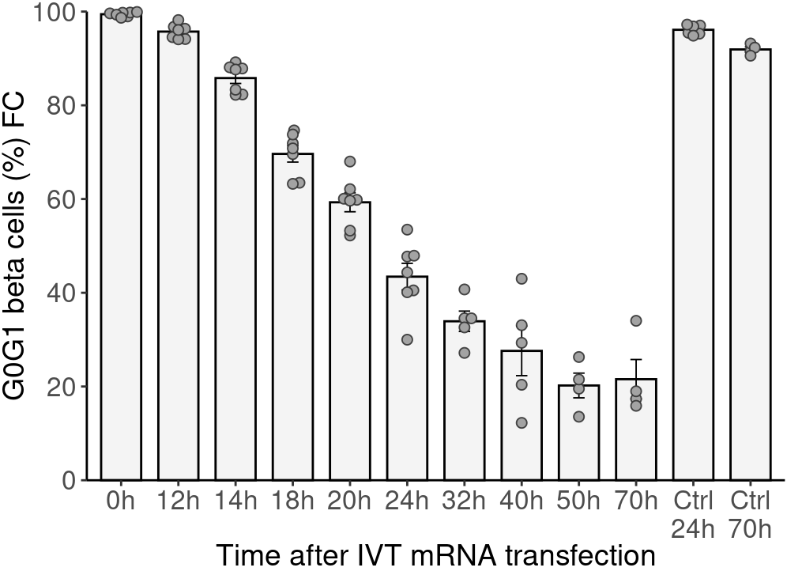

Proportion of G0G1-phase EdU⁻ beta cells (% by flow cytometry) at different time points after IVT mRNA transfection. Bars show means ± SEM

```r
scale <- 1

p <- data_long %>%
  filter(
    grepl("G0G1_CYCLE_FC", Table),
    !is.na(Proportion)
  ) %>%
  mutate(
    Time = factor(
      Time,
      levels = unique(Time),
      labels = gsub(" hour[s]?", "h", gsub("Control", "Ctrl", unique(Time)))
    ),
    Time = stringr::str_trim(Time)
  ) %>%
  mutate(
    Time = forcats::fct_relevel(Time, "Ctrl 24h", "Ctrl 70h", after = Inf)
  ) %>%
  ggplot(
    aes(x = Time, y = Proportion)
  ) +
  stat_summary(
    fun = "mean",
    geom = "col",
    fill = 'grey80', color = 'black',
    width = 0.7,
    alpha = 0.2
  ) +
  stat_summary(fun.data = mean_se, geom = "errorbar", width = 0.2, linewidth = 0.324) +
  scale_y_continuous(
    breaks = seq(0, 100/scale, 20/scale),
    name = "G0G1 beta cells (%) FC",
    expand = expansion(mult = c(0, 0), add = c(0, 0))
  ) +
  coord_cartesian(ylim = c(0, 100/scale), clip = "off") +
  scale_x_discrete(name = "Time after IVT mRNA transfection",
    labels = function(x) gsub("Ctrl (.*)", "Ctrl\n\\1", x)) +
  geom_beeswarm(
    cex = 1.01,
    fill = 'grey64',
    size = 1.97,
    shape = 21,
    color = rgb(0.2, 0.2, 0.2, 0.9),
    stroke = 0.5
  ) +
  theme_classic() +
  theme(
    plot.margin = margin(t = 5.5, r = 1, b = 1, l = 1),
    axis.text.x = element_text(size = ax_text2),
    axis.text.y = element_text(size = ax_text2),
    axis.title.x = element_text(
      size = tit_text2,
      margin = margin(t = mar2)
      ),
    axis.title.y = element_text(size = tit_text2, margin = margin(r = 0.4))
  )


p
```

**Open code**

```r
if (!file.exists("gitignore/figures/fig_14.pdf")) {
  ggsave("gitignore/figures/fig_14.pdf", plot = p, width = figw3, height = figh3, units = "in")
  ggsave("gitignore/figures/fig_14.svg", plot = p, width = figw3, height = figh3, units = "in")
  }
```

### 16.2.5 Summary statistics over timpoints

**Open code**

```r
kableExtra::kable(
  data_long %>%
    dplyr::filter(grepl("G0G1_CYCLE_FC", Table)) %>%
    tidyr::drop_na(Proportion) %>%
    dplyr::group_by(Time) %>%
    dplyr::summarise(
      mean = mean(Proportion),
      median = quantile(Proportion, probs = 0.5),
      SD = sd(Proportion),
      SEM = sem(Proportion)
    ),
  caption = "Summary statistics for the proportion of G0G1-phase EdU⁻ beta cells (% by flow cytometry) at different time points after IVT mRNA transfection. Mean, median, SD, and SEM are shown; SD, standard deviation; SEM, standard error of the mean"
)
```

Summary statistics for the proportion of G0G1-phase EdU⁻ beta cells (% by flow cytometry) at different time points after IVT mRNA transfection. Mean, median, SD, and SEM are shown; SD, standard deviation; SEM, standard error of the mean

| Time | mean | median | SD | SEM |
| --- | --- | --- | --- | --- |
| 0 hours | 99.43143 | 99.610 | 0.4660625 | 0.1761551 |
| 12 hours | 95.72571 | 96.070 | 1.5433174 | 0.5833191 |
| 14 hours | 85.80286 | 87.630 | 3.0370255 | 1.1478877 |
| 18 hours | 69.62571 | 70.800 | 4.6088894 | 1.7419965 |
| 20 hours | 59.30429 | 59.830 | 5.3412697 | 2.0188102 |
| 24 hours | 43.43714 | 44.340 | 7.5318451 | 2.8467699 |
| Control 24 hours | 96.11000 | 96.145 | 1.0247341 | 0.4183459 |
| 40 hours | 27.60000 | 29.320 | 11.8114711 | 5.2822505 |
| 32 hours | 33.91800 | 34.550 | 4.8522284 | 2.1699825 |
| 50 hours | 20.21750 | 20.515 | 5.2740963 | 2.6370481 |
| 70 hours | 21.55750 | 18.165 | 8.4042544 | 4.2021272 |
| Control 70 hours | 91.91750 | 91.950 | 1.1038229 | 0.5519115 |

# 17 S cycle FC

## 17.1 Show Data

**Open code**

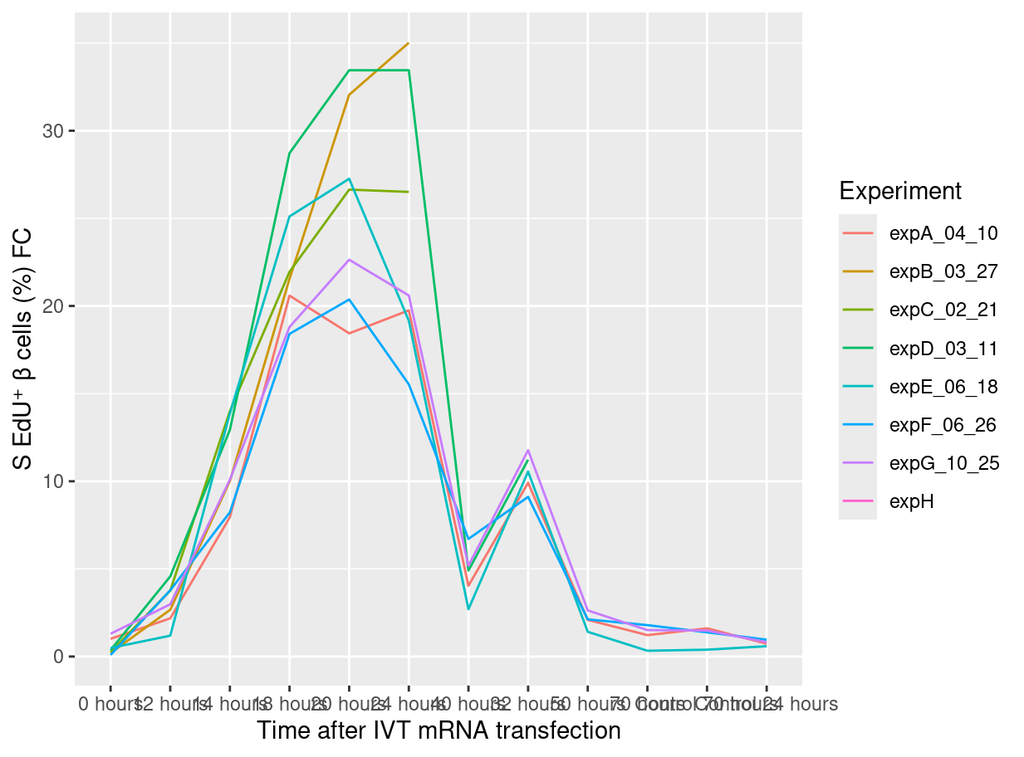

Mean proportion of S-phase EdU⁺ β cells (% by flow cytometry) at different time points after IVT mRNA transfection and across individual experiments

```r
data_long %>% filter(
  grepl('S_CYCLE_FC_X_Cell_cycle_occupation4_X_S Ed', Table)) %>%
  ggplot(
    aes(x = Time, y = Proportion, group = Experiment, color = Experiment)
    ) +
  geom_line() +
  scale_y_continuous(
    name = "S EdU⁺ β cells (%) FC"
  ) +
  scale_x_discrete(name = "Time after IVT mRNA transfection")
## Warning: Removed 16 rows containing missing values or values outside the scale range
## (`geom_line()`).
```

$\Rightarrow$ Variances sharply increase as going toward 50% proportion, clear heteroscedasticity

## 17.2 Models

### 17.2.1 Choose model

AIC/BIC

**Open code**

```r
model_NR <- glmmTMB::glmmTMB(
  Proportion ~ Time,
  data = data_long %>%
    filter(
      grepl('S_CYCLE_FC_X_Cell_cycle_occupation4_X_S Ed', Table),
      !is.na(Proportion)
    ) %>%
    mutate(Time = factor(Time)),
  REML = FALSE
)

model_RI <- glmmTMB::glmmTMB(
  Proportion ~ Time + (1 | Experiment),
  data = data_long %>%
    filter(
      grepl('S_CYCLE_FC_X_Cell_cycle_occupation4_X_S Ed', Table),
      !is.na(Proportion)
    ) %>%
    mutate(Time = factor(Time)),
  REML = FALSE
)

model_NR_difvar <- glmmTMB::glmmTMB(
  Proportion ~ Time,
  data = data_long %>%
    filter(
      grepl('S_CYCLE_FC_X_Cell_cycle_occupation4_X_S Ed', Table),
      !is.na(Proportion)
    ) %>%
    mutate(Time = factor(Time)),
  REML = FALSE,
  dispformula = ~ 0 + Time
)

model_RI_difvar <- glmmTMB::glmmTMB(
  Proportion ~ Time + (1 | Experiment),
  data = data_long %>%
    filter(
      grepl('S_CYCLE_FC_X_Cell_cycle_occupation4_X_S Ed', Table),
      !is.na(Proportion)
    ) %>%
    mutate(Time = factor(Time)),
  REML = FALSE,
  dispformula = ~ Time
)

kableExtra::kable(AIC(model_NR, model_RI, model_NR_difvar, model_RI_difvar))
```

|  | df | AIC |
| --- | --- | --- |
| model_NR | 13 | 384.0395 |
| model_RI | 14 | 376.9251 |
| model_NR_difvar | 24 | 293.8989 |
| model_RI_difvar | 25 | 285.9437 |

**Open code**

```r
kableExtra::kable(BIC(model_NR, model_RI, model_NR_difvar, model_RI_difvar))
```

|  | df | BIC |
| --- | --- | --- |
| model_NR | 13 | 413.2699 |
| model_RI | 14 | 408.4040 |
| model_NR_difvar | 24 | 347.8628 |
| model_RI_difvar | 25 | 342.1561 |

Diagnostics

**Open code**

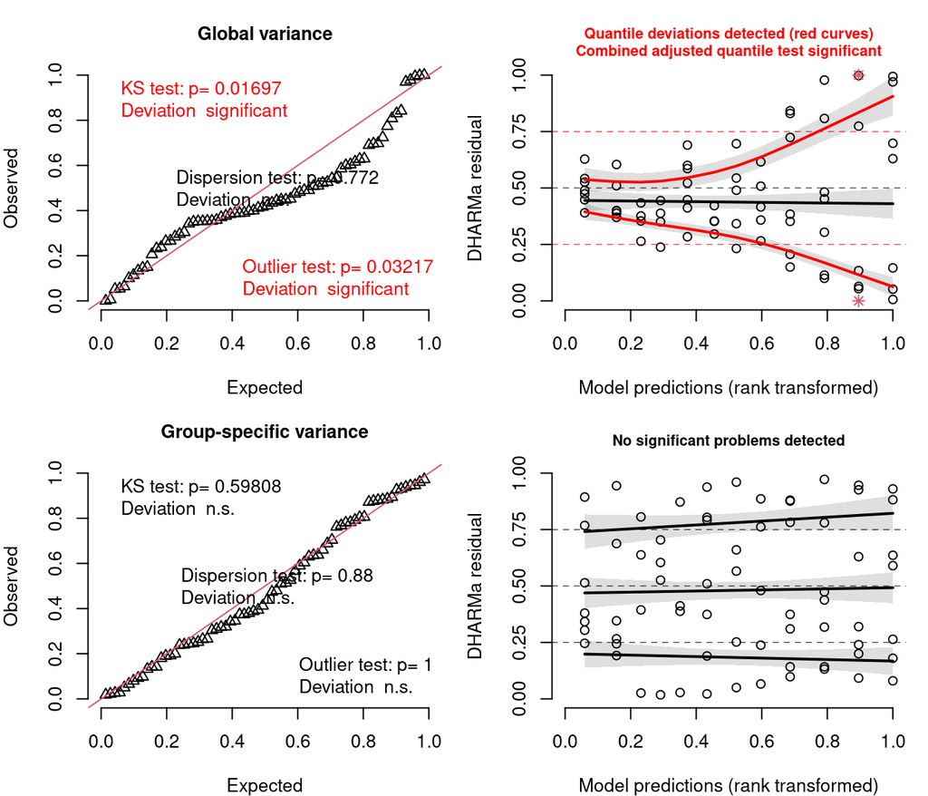

Diagnostic plots from DHARMa simulated residuals for models with and without group-specific residual variance. Top: random-intercept model with a single (global) residual variance. Bottom: random-intercept model allowing group-specific residual variance. Left: quantile–quantile plot comparing simulated residuals to the expected distribution. Right: residuals plotted against predicted values; black lines show the median (0.5) and lower/upper quartiles (0.25, 0.75) with shaded 95% simulation envelopes. Deviations from expected values suggest potential model misspecification

```r
set.seed(709)

res1 <- simulateResiduals(model_RI, n = 500)
res2 <- simulateResiduals(model_RI_difvar, n = 500)

op <- par(mfrow = c(2, 2), mar = c(4, 4, 3, 1))

plotQQunif(res1, main = "Global variance")
plotResiduals(res1, main = "")

plotQQunif(res2, main = "Group-specific variance")
plotResiduals(res2, main = "")
```

**Open code**

```r
par(op)
```

$\Rightarrow$ The random-intercept model with group-specific variance provided the best fit according to both AIC and BIC, and sharply improved model diagnostics, and was therefore retained

### 17.2.2 Fit final model

**Open code**

```r
model_final <- glmmTMB::glmmTMB(
  Proportion ~ Time + (1 | Experiment),
  data = data_long %>%
    filter(
      grepl('S_CYCLE_FC_X_Cell_cycle_occupation4_X_S Ed', Table),
      !is.na(Proportion)
    ),
  REML = TRUE,
  dispformula = ~ 0 + Time
)
```

### 17.2.3 Results

**Open code**

```r
kableExtra::kable(car::Anova(model_final))
```

|  | Chisq | Df | Pr(>Chisq) |
| --- | --- | --- | --- |
| Time | 972.7647 | 11 | 0 |

**Open code**

```r
summary(model_final)
##  Family: gaussian  ( identity )
## Formula:          Proportion ~ Time + (1 | Experiment)
## Dispersion:                  ~0 + Time
## Data: data_long %>% filter(grepl("S_CYCLE_FC_X_Cell_cycle_occupation4_X_S Ed",
##     Table), !is.na(Proportion))
##
##      AIC      BIC   logLik deviance df.resid
##    281.7    337.9   -115.9    231.7       57
##
## Random effects:
##
## Conditional model:
##  Groups     Name        Variance Std.Dev.
##  Experiment (Intercept) 0.1883   0.434
##  Residual                   NA      NA
## Number of obs: 70, groups:  Experiment, 7
##
## Conditional model:
##                      Estimate Std. Error z value Pr(>|z|)
## (Intercept)            0.5300     0.2715   1.952  0.05096 .
## Time12 hours           2.4886     0.4079   6.101 1.06e-09 ***
## Time14 hours          10.4814     1.0428  10.051  < 2e-16 ***
## Time18 hours          21.6314     1.4310  15.116  < 2e-16 ***
## Time20 hours          25.3057     2.1490  11.776  < 2e-16 ***
## Time24 hours          23.7586     2.8003   8.484  < 2e-16 ***
## Time40 hours           4.2232     0.6042   6.989 2.76e-12 ***
## Time32 hours          10.0292     0.4943  20.289  < 2e-16 ***
## Time50 hours           1.6610     0.2666   6.231 4.63e-10 ***
## Time70 hours           0.8110     0.3172   2.557  0.01056 *
## TimeControl 70 hours   0.8135     0.2999   2.712  0.00669 **
## TimeControl 24 hours   0.6880     0.3484   1.975  0.04828 *
## ---
## Signif. codes:  0 '***' 0.001 '**' 0.01 '*' 0.05 '.' 0.1 ' ' 1
##
## Dispersion model:
##                      Estimate Std. Error z value Pr(>|z|)
## Time0 hours          -0.55767    0.39025  -1.429 0.153002
## Time12 hours         -0.08896    0.31562  -0.282 0.778045
## Time14 hours          0.99288    0.29050   3.418 0.000631 ***
## Time18 hours          1.31976    0.29032   4.546 5.47e-06 ***
## Time20 hours          1.73286    0.29000   5.975 2.29e-09 ***
## Time24 hours          1.99967    0.28972   6.902 5.12e-12 ***
## Time40 hours          0.21817    0.35523   0.614 0.539098
## Time32 hours         -0.02914    0.37785  -0.077 0.938531
## Time50 hours         -2.55183    3.18890  -0.800 0.423582
## Time70 hours         -1.04262    0.46184  -2.258 0.023975 *
## TimeControl 70 hours -1.25226    0.50427  -2.483 0.013017 *
## TimeControl 24 hours -0.42426    0.40422  -1.050 0.293907
## ---
## Signif. codes:  0 '***' 0.001 '**' 0.01 '*' 0.05 '.' 0.1 ' ' 1

contrast <- con_tab(model_final)

kableExtra::kable(
  contrast,
  caption = "Estimated pairwise differences in the proportion of S-phase EdU⁺ β cells (%; flow cytometry), obtained from a linear mixed-effects model with experiment as a random intercept, time as a categorical predictor, and allowance for group-specific residual variance. Columns: `contrast` (time points compared), `estimate` (mean difference in %), `CI` (Bonferroni-adjusted 95% confidence interval [lower, upper]), `SE` (standard error), `df` (degrees of freedom), `t.ratio` (test statistic), `p.value` (Bonferroni-adjusted p-value), and `stars` (significance code)"
)
```

Estimated pairwise differences in the proportion of S-phase EdU⁺ β cells (%; flow cytometry), obtained from a linear mixed-effects model with experiment as a random intercept, time as a categorical predictor, and allowance for group-specific residual variance. Columns: `contrast` (time points compared), `estimate` (mean difference in %), `CI` (Bonferroni-adjusted 95% confidence interval [lower, upper]), `SE` (standard error), `df` (degrees of freedom), `t.ratio` (test statistic), `p.value` (Bonferroni-adjusted p-value), and `stars` (significance code)

| contrast | estimate | CI | SE | df | t.ratio | p.value | stars |
| --- | --- | --- | --- | --- | --- | --- | --- |
| 0 hours - 12 hours | -2.49 | [-3.94, -1.04] | 0.41 | 57 | -6.10 | 0.0000065 | *** |
| 0 hours - 14 hours | -10.48 | [-14.19, -6.77] | 1.04 | 57 | -10.05 | 0.0000000 | *** |
| 0 hours - 18 hours | -21.63 | [-26.72, -16.54] | 1.43 | 57 | -15.12 | 0.0000000 | *** |
| 0 hours - 20 hours | -25.31 | [-32.95, -17.66] | 2.15 | 57 | -11.78 | 0.0000000 | *** |
| 0 hours - 24 hours | -23.76 | [-33.73, -13.79] | 2.80 | 57 | -8.48 | 0.0000000 | *** |
| 0 hours - 40 hours | -4.22 | [-6.37, -2.07] | 0.60 | 57 | -6.99 | 0.0000002 | *** |
| 0 hours - 32 hours | -10.03 | [-11.79, -8.27] | 0.49 | 57 | -20.29 | 0.0000000 | *** |
| 0 hours - 50 hours | -1.66 | [-2.61, -0.71] | 0.27 | 57 | -6.23 | 0.0000040 | *** |
| 0 hours - 70 hours | -0.81 | [-1.94, 0.32] | 0.32 | 57 | -2.56 | 0.8746477 | ns |
| 0 hours - Control 70 hours | -0.81 | [-1.88, 0.25] | 0.30 | 57 | -2.71 | 0.5823044 | ns |
| 0 hours - Control 24 hours | -0.69 | [-1.93, 0.55] | 0.35 | 57 | -1.97 | 1.0000000 | ns |
| 12 hours - 14 hours | -7.99 | [-11.83, -4.16] | 1.08 | 57 | -7.42 | 0.0000000 | *** |
| 12 hours - 18 hours | -19.14 | [-24.33, -13.96] | 1.46 | 57 | -13.15 | 0.0000000 | *** |
| 12 hours - 20 hours | -22.82 | [-30.53, -15.11] | 2.17 | 57 | -10.53 | 0.0000000 | *** |
| 12 hours - 24 hours | -21.27 | [-31.28, -11.26] | 2.81 | 57 | -7.56 | 0.0000000 | *** |
| 12 hours - 40 hours | -1.73 | [-4.09, 0.62] | 0.66 | 57 | -2.62 | 0.7395014 | ns |
| 12 hours - 32 hours | -7.54 | [-9.55, -5.54] | 0.56 | 57 | -13.39 | 0.0000000 | *** |
| 12 hours - 50 hours | 0.83 | [-0.52, 2.18] | 0.38 | 57 | 2.18 | 1.0000000 | ns |
| 12 hours - 70 hours | 1.68 | [0.20, 3.16] | 0.42 | 57 | 4.03 | 0.0110588 | * |
| 12 hours - Control 70 hours | 1.68 | [0.24, 3.11] | 0.40 | 57 | 4.15 | 0.0073316 | ** |
| 12 hours - Control 24 hours | 1.80 | [0.23, 3.37] | 0.44 | 57 | 4.09 | 0.0091326 | ** |
| 14 hours - 18 hours | -11.15 | [-17.36, -4.94] | 1.74 | 57 | -6.39 | 0.0000021 | *** |
| 14 hours - 20 hours | -14.82 | [-23.26, -6.39] | 2.37 | 57 | -6.26 | 0.0000036 | *** |
| 14 hours - 24 hours | -13.28 | [-23.86, -2.70] | 2.97 | 57 | -4.47 | 0.0025171 | ** |
| 14 hours - 40 hours | 6.26 | [2.11, 10.41] | 1.17 | 57 | 5.37 | 0.0001000 | *** |
| 14 hours - 32 hours | 0.45 | [-3.51, 4.41] | 1.11 | 57 | 0.41 | 1.0000000 | ns |
| 14 hours - 50 hours | 8.82 | [5.15, 12.49] | 1.03 | 57 | 8.55 | 0.0000000 | *** |
| 14 hours - 70 hours | 9.67 | [5.95, 13.39] | 1.05 | 57 | 9.24 | 0.0000000 | *** |
| 14 hours - Control 70 hours | 9.67 | [5.96, 13.37] | 1.04 | 57 | 9.29 | 0.0000000 | *** |
| 14 hours - Control 24 hours | 9.79 | [6.03, 13.55] | 1.06 | 57 | 9.27 | 0.0000000 | *** |
| 18 hours - 20 hours | -3.67 | [-12.80, 5.45] | 2.56 | 57 | -1.43 | 1.0000000 | ns |
| 18 hours - 24 hours | -2.13 | [-13.27, 9.01] | 3.13 | 57 | -0.68 | 1.0000000 | ns |
| 18 hours - 40 hours | 17.41 | [11.99, 22.83] | 1.52 | 57 | 11.43 | 0.0000000 | *** |
| 18 hours - 32 hours | 11.60 | [6.32, 16.88] | 1.48 | 57 | 7.82 | 0.0000000 | *** |
| 18 hours - 50 hours | 19.97 | [14.91, 25.04] | 1.42 | 57 | 14.03 | 0.0000000 | *** |
| 18 hours - 70 hours | 20.82 | [15.72, 25.92] | 1.43 | 57 | 14.52 | 0.0000000 | *** |
| 18 hours - Control 70 hours | 20.82 | [15.73, 25.91] | 1.43 | 57 | 14.56 | 0.0000000 | *** |
| 18 hours - Control 24 hours | 20.94 | [15.82, 26.07] | 1.44 | 57 | 14.54 | 0.0000000 | *** |
| 20 hours - 24 hours | 1.55 | [-10.97, 14.06] | 3.52 | 57 | 0.44 | 1.0000000 | ns |
| 20 hours - 40 hours | 21.08 | [13.21, 28.95] | 2.21 | 57 | 9.53 | 0.0000000 | *** |
| 20 hours - 32 hours | 15.28 | [7.50, 23.05] | 2.18 | 57 | 7.00 | 0.0000002 | *** |
| 20 hours - 50 hours | 23.64 | [16.01, 31.28] | 2.14 | 57 | 11.03 | 0.0000000 | *** |
| 20 hours - 70 hours | 24.49 | [16.84, 32.15] | 2.15 | 57 | 11.39 | 0.0000000 | *** |
| 20 hours - Control 70 hours | 24.49 | [16.85, 32.14] | 2.15 | 57 | 11.40 | 0.0000000 | *** |
| 20 hours - Control 24 hours | 24.62 | [16.95, 32.29] | 2.16 | 57 | 11.42 | 0.0000000 | *** |
| 24 hours - 40 hours | 19.54 | [9.40, 29.67] | 2.85 | 57 | 6.86 | 0.0000004 | *** |
| 24 hours - 32 hours | 13.73 | [3.67, 23.79] | 2.83 | 57 | 4.86 | 0.0006402 | *** |
| 24 hours - 50 hours | 22.10 | [12.14, 32.05] | 2.80 | 57 | 7.90 | 0.0000000 | *** |
| 24 hours - 70 hours | 22.95 | [12.98, 32.92] | 2.80 | 57 | 8.19 | 0.0000000 | *** |
| 24 hours - Control 70 hours | 22.95 | [12.98, 32.91] | 2.80 | 57 | 8.20 | 0.0000000 | *** |
| 24 hours - Control 24 hours | 23.07 | [13.09, 33.06] | 2.81 | 57 | 8.22 | 0.0000000 | *** |
| 40 hours - 32 hours | -5.81 | [-8.32, -3.29] | 0.71 | 57 | -8.23 | 0.0000000 | *** |
| 40 hours - 50 hours | 2.56 | [0.55, 4.57] | 0.56 | 57 | 4.54 | 0.0019754 | ** |
| 40 hours - 70 hours | 3.41 | [1.31, 5.51] | 0.59 | 57 | 5.78 | 0.0000217 | *** |
| 40 hours - Control 70 hours | 3.41 | [1.34, 5.48] | 0.58 | 57 | 5.87 | 0.0000157 | *** |
| 40 hours - Control 24 hours | 3.54 | [1.31, 5.76] | 0.63 | 57 | 5.65 | 0.0000356 | *** |
| 32 hours - 50 hours | 8.37 | [6.78, 9.95] | 0.45 | 57 | 18.79 | 0.0000000 | *** |
| 32 hours - 70 hours | 9.22 | [7.52, 10.92] | 0.48 | 57 | 19.31 | 0.0000000 | *** |
| 32 hours - Control 70 hours | 9.22 | [7.56, 10.87] | 0.47 | 57 | 19.78 | 0.0000000 | *** |
| 32 hours - Control 24 hours | 9.34 | [7.49, 11.19] | 0.52 | 57 | 17.94 | 0.0000000 | *** |
| 50 hours - 70 hours | 0.85 | [0.21, 1.49] | 0.18 | 57 | 4.71 | 0.0010818 | ** |
| 50 hours - Control 70 hours | 0.85 | [0.32, 1.37] | 0.15 | 57 | 5.72 | 0.0000271 | *** |
| 50 hours - Control 24 hours | 0.97 | [-0.08, 2.03] | 0.30 | 57 | 3.28 | 0.1174190 | ns |
| 70 hours - Control 70 hours | 0.00 | [-0.81, 0.81] | 0.23 | 57 | -0.01 | 1.0000000 | ns |
| 70 hours - Control 24 hours | 0.12 | [-1.10, 1.34] | 0.34 | 57 | 0.36 | 1.0000000 | ns |
| Control 70 hours - Control 24 hours | 0.13 | [-1.04, 1.29] | 0.33 | 57 | 0.38 | 1.0000000 | ns |

### 17.2.4 Visualisation

**Open code**

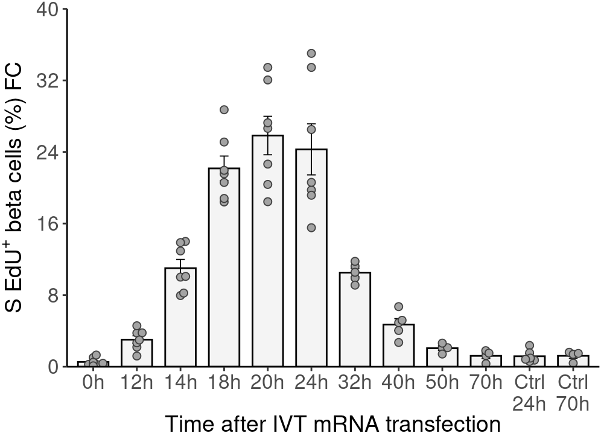

Proportion of S-phase EdU⁺ beta cells (% by flow cytometry) at different time points after IVT mRNA transfection. Bars show means ± SEM

```r
scale <- 10/4

p <- data_long %>%
  filter(
      grepl('S_CYCLE_FC_X_Cell_cycle_occupation4_X_S Ed', Table),
      !is.na(Proportion)
    ) %>%
  mutate(
    Time = factor(
      Time,
      levels = unique(Time),
      labels = gsub(" hour[s]?", "h", gsub("Control", "Ctrl", unique(Time)))
    ),
    Time = stringr::str_trim(Time)
  ) %>%
  mutate(
    Time = forcats::fct_relevel(Time, "Ctrl 24h", "Ctrl 70h", after = Inf)
  ) %>%
  ggplot(
    aes(x = Time, y = Proportion)
  ) +
  stat_summary(
    fun = 'mean',
    geom = 'col',
    fill = 'grey80', color = 'black',
    width = 0.7,
    alpha = 0.2
  ) +
  stat_summary(fun.data = mean_se, geom = "errorbar", width = 0.2, linewidth = 0.324) +
  scale_y_continuous(
    breaks = seq(0, 100/scale, 20/scale),
    name = expression("S EdU"^"+"~"beta cells (%) FC"),
    expand = expansion(mult = c(0, 0), add = c(0, 0))
  ) +
  coord_cartesian(ylim = c(0, 100/scale)) +
  scale_x_discrete(name = "Time after IVT mRNA transfection",
    labels = function(x) gsub("Ctrl (.*)", "Ctrl\n\\1", x)) +
  geom_beeswarm(
    cex = 1.01,
    fill = 'grey64',
    size = 1.97,
    shape = 21,
    color = rgb(0.2, 0.2, 0.2, 0.9),
    stroke = 0.5
  ) +
  theme_classic() +
  theme(
    plot.margin = margin(t = 5.5, r = 1, b = 1, l = 1),
    axis.text.x = element_text(size = ax_text2),
    axis.text.y = element_text(size = ax_text2),
    axis.title.x = element_text(
      size = tit_text2,
      margin = margin(t = mar2)
      ),
    axis.title.y = element_text(size = tit_text2)
  )

p
```

**Open code**

```r
if (!file.exists("gitignore/figures/fig_15.pdf")) {
  ggsave("gitignore/figures/fig_15.pdf", plot = p, width = figw3, height = figh3, units = "in")
  ggsave("gitignore/figures/fig_15.svg", plot = p, width = figw3, height = figh3, units = "in")
  }
```

### 17.2.5 Summary statistics over timpoints

**Open code**

```r
kableExtra::kable(
  data_long %>%
    dplyr::filter(grepl("S_CYCLE_FC_X_Cell_cycle_occupation4_X_S Ed", Table)) %>%
    tidyr::drop_na(Proportion) %>%
    dplyr::group_by(Time) %>%
    dplyr::summarise(
      mean = mean(Proportion),
      median = quantile(Proportion, probs = 0.5),
      SD = sd(Proportion),
      SEM = sem(Proportion)
    ),
  caption = "Summary statistics for the proportion of S-phase EdU⁺ beta cells (% by flow cytometry) at different time points after IVT mRNA transfection. Mean, median, SD, and SEM are shown; SD, standard deviation; SEM, standard error of the mean"
)
```

Summary statistics for the proportion of S-phase EdU⁺ beta cells (% by flow cytometry) at different time points after IVT mRNA transfection. Mean, median, SD, and SEM are shown; SD, standard deviation; SEM, standard error of the mean

| Time | mean | median | SD | SEM |
| --- | --- | --- | --- | --- |
| 0 hours | 0.530000 | 0.370 | 0.4530269 | 0.1712281 |
| 12 hours | 3.018571 | 2.980 | 1.1333053 | 0.4283491 |
| 14 hours | 11.011429 | 10.090 | 2.5737290 | 0.9727781 |
| 18 hours | 22.161429 | 21.550 | 3.6507827 | 1.3798662 |
| 20 hours | 25.835714 | 26.640 | 5.6870228 | 2.1494926 |
| 24 hours | 24.288571 | 20.600 | 7.5415415 | 2.8504347 |
| 40 hours | 4.708000 | 4.910 | 1.4790098 | 0.6614333 |
| 32 hours | 10.514000 | 10.550 | 1.0520836 | 0.4705061 |
| 50 hours | 2.062500 | 2.105 | 0.5006246 | 0.2503123 |
| 70 hours | 1.212500 | 1.365 | 0.6326861 | 0.3163430 |
| Control 70 hours | 1.215000 | 1.430 | 0.5580024 | 0.2790012 |
| Control 24 hours | 1.170000 | 0.890 | 0.6754258 | 0.2757414 |

# 18 G2M cycle FC

## 18.1 Show Data

**Open code**

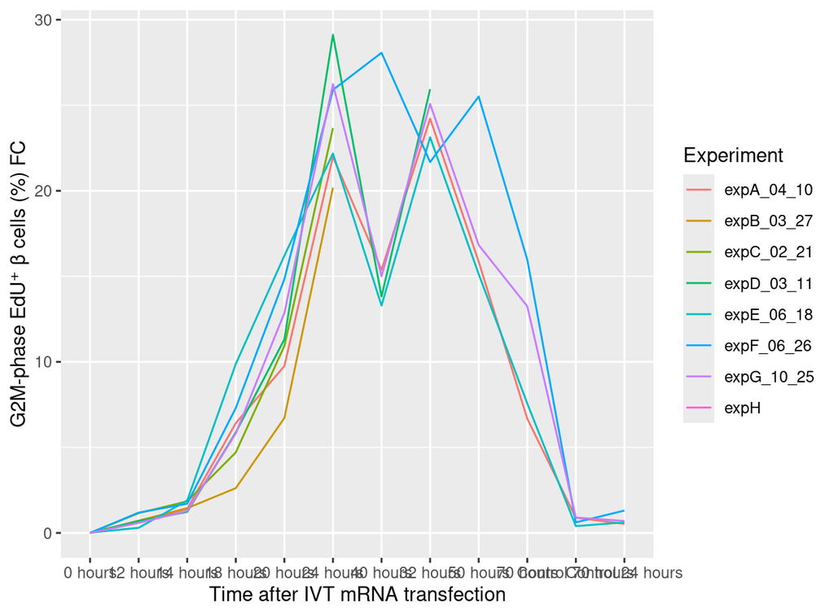

Mean proportion of G2M-phase EdU⁺ β cells (% by flow cytometry) at different time points after IVT mRNA transfection and across individual experiments

```r
data_long %>% filter(grepl('G2M_CYCLE_FC', Table)) %>%
  ggplot(
    aes(x = Time, y = Proportion, group = Experiment, color = Experiment)
    ) +
  geom_line() +
  scale_y_continuous(
    name = "G2M-phase EdU⁺ β cells (%) FC"
  ) +
  scale_x_discrete(name = "Time after IVT mRNA transfection")
## Warning: Removed 16 rows containing missing values or values outside the scale range
## (`geom_line()`).
```

$\Rightarrow$ Variances sharply increase as going toward 50% proportion, clear heteroscedasticity

## 18.2 Models

### 18.2.1 Choose model

AIC/BIC

**Open code**

```r
model_NR <- glmmTMB::glmmTMB(
  Proportion ~ Time,
  data = data_long %>%
    filter(
      grepl('G2M_CYCLE_FC', Table),
      !is.na(Proportion)
    ) %>%
    mutate(Time = factor(Time)),
  REML = FALSE
)

model_RI <- glmmTMB::glmmTMB(
  Proportion ~ Time + (1 | Experiment),
  data = data_long %>%
    filter(
      grepl('G2M_CYCLE_FC', Table),
      !is.na(Proportion)
    ) %>%
    mutate(Time = factor(Time)),
  REML = FALSE
)

model_NR_difvar <- glmmTMB::glmmTMB(
  Proportion ~ Time,
  data = data_long %>%
    filter(
      grepl('G2M_CYCLE_FC', Table),
      !is.na(Proportion)
    ) %>%
    mutate(Time = factor(Time)),
  REML = FALSE,
  dispformula = ~ 0 + Time
)

model_RI_difvar <- glmmTMB::glmmTMB(
  Proportion ~ Time + (1 | Experiment),
  data = data_long %>%
    filter(
      grepl('G2M_CYCLE_FC', Table),
      !is.na(Proportion)
    ) %>%
    mutate(Time = factor(Time)),
  REML = FALSE,
  dispformula = ~ 0 + Time
)

kableExtra::kable(AIC(model_NR, model_RI, model_NR_difvar, model_RI_difvar))
```

|  | df | AIC |
| --- | --- | --- |
| model_NR | 13 | 353.8702 |
| model_RI | 14 | 351.0464 |
| model_NR_difvar | 24 | 195.0176 |
| model_RI_difvar | 25 | 197.0176 |

**Open code**

```r
kableExtra::kable(BIC(model_NR, model_RI, model_NR_difvar, model_RI_difvar))
```

|  | df | BIC |
| --- | --- | --- |
| model_NR | 13 | 383.1007 |
| model_RI | 14 | 382.5253 |
| model_NR_difvar | 24 | 248.9815 |
| model_RI_difvar | 25 | 253.2300 |

Diagnostics

**Open code**

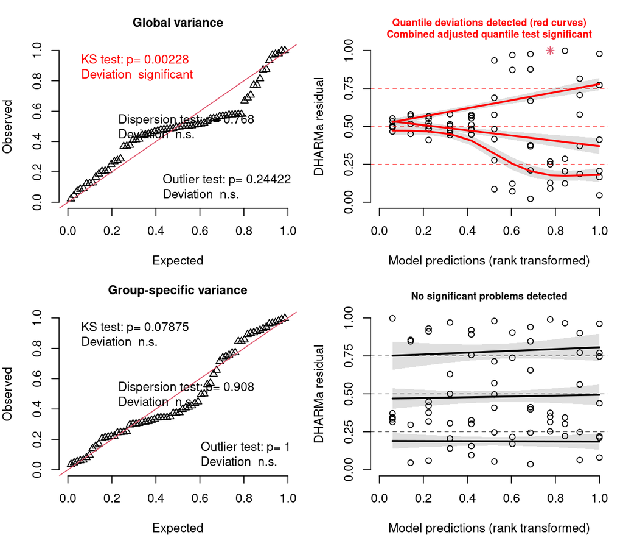

Diagnostic plots from DHARMa simulated residuals for models with and without group-specific residual variance. Top: random-intercept model with a single (global) residual variance. Bottom: random-intercept model allowing group-specific residual variance. Left: quantile–quantile plot comparing simulated residuals to the expected distribution. Right: residuals plotted against predicted values; black lines show the median (0.5) and lower/upper quartiles (0.25, 0.75) with shaded 95% simulation envelopes. Deviations from expected values suggest potential model misspecification

```r
set.seed(709)

res1 <- simulateResiduals(model_RI, n = 500)
res2 <- simulateResiduals(model_RI_difvar, n = 500)

op <- par(mfrow = c(2, 2), mar = c(4, 4, 3, 1))

plotQQunif(res1, main = "Global variance")
plotResiduals(res1, main = "")
## qu = 0.25, log(sigma) = -3.309298 : outer Newton did not converge fully.

plotQQunif(res2, main = "Group-specific variance")
plotResiduals(res2, main = "")
```

**Open code**

```r
par(op)
```

### 18.2.2 Fit final model

**Open code**

```r
model_final <- glmmTMB::glmmTMB(
  Proportion ~ Time + (1 | Experiment),
  data = data_long %>%
    filter(
      grepl('G2M_CYCLE_FC', Table),
      !is.na(Proportion)
    ),
  REML = TRUE,
  dispformula = ~ 0 + Time
)
```

### 18.2.3 Results

**Open code**

```r
kableExtra::kable(car::Anova(model_final))
```

|  | Chisq | Df | Pr(>Chisq) |
| --- | --- | --- | --- |
| Time | 2088.025 | 11 | 0 |

**Open code**

```r
summary(model_final)
##  Family: gaussian  ( identity )
## Formula:          Proportion ~ Time + (1 | Experiment)
## Dispersion:                  ~0 + Time
## Data: data_long %>% filter(grepl("G2M_CYCLE_FC", Table), !is.na(Proportion))
##
##      AIC      BIC   logLik deviance df.resid
##    200.2    256.4    -75.1    150.2       57
##
## Random effects:
##
## Conditional model:
##  Groups     Name        Variance  Std.Dev.
##  Experiment (Intercept) 2.776e-12 1.666e-06
##  Residual                      NA        NA
## Number of obs: 70, groups:  Experiment, 7
##
## Conditional model:
##                       Estimate Std. Error z value Pr(>|z|)
## (Intercept)           0.002857   0.002857    1.00    0.317
## Time12 hours          0.755714   0.119824    6.31 2.85e-10 ***
## Time14 hours          1.544286   0.102735   15.03  < 2e-16 ***
## Time18 hours          6.088571   0.845493    7.20 5.97e-13 ***
## Time20 hours         11.802857   1.202861    9.81  < 2e-16 ***
## Time24 hours         24.181429   1.160687   20.83  < 2e-16 ***
## Time40 hours         17.111143   2.765331    6.19 6.10e-10 ***
## Time32 hours         24.007143   0.745566   32.20  < 2e-16 ***
## Time50 hours         18.329643   2.417702    7.58 3.42e-14 ***
## Time70 hours         10.867143   2.240214    4.85 1.23e-06 ***
## TimeControl 70 hours  0.699643   0.119921    5.83 5.41e-09 ***
## TimeControl 24 hours  0.810476   0.113546    7.14 9.48e-13 ***
## ---
## Signif. codes:  0 '***' 0.001 '**' 0.01 '*' 0.05 '.' 0.1 ' ' 1
##
## Dispersion model:
##                      Estimate Std. Error z value Pr(>|z|)
## Time0 hours           -4.8850     0.2887 -16.922  < 2e-16 ***
## Time12 hours          -1.1491     0.2887  -3.980 6.88e-05 ***
## Time14 hours          -1.3030     0.2887  -4.514 6.37e-06 ***
## Time18 hours           0.8051     0.2887   2.789 0.005287 **
## Time20 hours           1.1577     0.2887   4.010 6.07e-05 ***
## Time24 hours           1.1220     0.2887   3.887 0.000102 ***
## Time40 hours           1.8219     0.3536   5.153 2.56e-07 ***
## Time32 hours           0.5111     0.3536   1.446 0.148287
## Time50 hours           1.5760     0.4082   3.860 0.000113 ***
## Time70 hours           1.4997     0.4082   3.674 0.000239 ***
## TimeControl 70 hours  -1.4281     0.4082  -3.498 0.000469 ***
## TimeControl 24 hours  -1.2800     0.3162  -4.048 5.17e-05 ***
## ---
## Signif. codes:  0 '***' 0.001 '**' 0.01 '*' 0.05 '.' 0.1 ' ' 1

contrast <- con_tab(model_final)

kableExtra::kable(
  contrast,
  caption = "Estimated pairwise differences in the proportion of G2M-phase EdU⁺ β cells (%; flow cytometry), obtained from a linear mixed-effects model with experiment as a random intercept, time as a categorical predictor, and allowance for group-specific residual variance. Columns: `contrast` (time points compared), `estimate` (mean difference in %), `CI` (Bonferroni-adjusted 95% confidence interval [lower, upper]), `SE` (standard error), `df` (degrees of freedom), `t.ratio` (test statistic), `p.value` (Bonferroni-adjusted p-value), and `stars` (significance code)"
)
```

Estimated pairwise differences in the proportion of G2M-phase EdU⁺ β cells (%; flow cytometry), obtained from a linear mixed-effects model with experiment as a random intercept, time as a categorical predictor, and allowance for group-specific residual variance. Columns: `contrast` (time points compared), `estimate` (mean difference in %), `CI` (Bonferroni-adjusted 95% confidence interval [lower, upper]), `SE` (standard error), `df` (degrees of freedom), `t.ratio` (test statistic), `p.value` (Bonferroni-adjusted p-value), and `stars` (significance code)

| contrast | estimate | CI | SE | df | t.ratio | p.value | stars |
| --- | --- | --- | --- | --- | --- | --- | --- |
| 0 hours - 12 hours | -0.76 | [-1.18, -0.33] | 0.12 | 57 | -6.31 | 0.0000030 | *** |
| 0 hours - 14 hours | -1.54 | [-1.91, -1.18] | 0.10 | 57 | -15.03 | 0.0000000 | *** |
| 0 hours - 18 hours | -6.09 | [-9.10, -3.08] | 0.85 | 57 | -7.20 | 0.0000001 | *** |
| 0 hours - 20 hours | -11.80 | [-16.08, -7.52] | 1.20 | 57 | -9.81 | 0.0000000 | *** |
| 0 hours - 24 hours | -24.18 | [-28.31, -20.05] | 1.16 | 57 | -20.83 | 0.0000000 | *** |
| 0 hours - 40 hours | -17.11 | [-26.95, -7.27] | 2.77 | 57 | -6.19 | 0.0000047 | *** |
| 0 hours - 32 hours | -24.01 | [-26.66, -21.35] | 0.75 | 57 | -32.20 | 0.0000000 | *** |
| 0 hours - 50 hours | -18.33 | [-26.94, -9.72] | 2.42 | 57 | -7.58 | 0.0000000 | *** |
| 0 hours - 70 hours | -10.87 | [-18.84, -2.89] | 2.24 | 57 | -4.85 | 0.0006529 | *** |
| 0 hours - Control 70 hours | -0.70 | [-1.13, -0.27] | 0.12 | 57 | -5.83 | 0.0000177 | *** |
| 0 hours - Control 24 hours | -0.81 | [-1.21, -0.41] | 0.11 | 57 | -7.14 | 0.0000001 | *** |
| 12 hours - 14 hours | -0.79 | [-1.35, -0.23] | 0.16 | 57 | -5.00 | 0.0003858 | *** |
| 12 hours - 18 hours | -5.33 | [-8.37, -2.29] | 0.85 | 57 | -6.25 | 0.0000038 | *** |
| 12 hours - 20 hours | -11.05 | [-15.35, -6.74] | 1.21 | 57 | -9.14 | 0.0000000 | *** |
| 12 hours - 24 hours | -23.43 | [-27.58, -19.27] | 1.17 | 57 | -20.08 | 0.0000000 | *** |
| 12 hours - 40 hours | -16.36 | [-26.21, -6.50] | 2.77 | 57 | -5.91 | 0.0000134 | *** |
| 12 hours - 32 hours | -23.25 | [-25.94, -20.56] | 0.76 | 57 | -30.79 | 0.0000000 | *** |
| 12 hours - 50 hours | -17.57 | [-26.19, -8.96] | 2.42 | 57 | -7.26 | 0.0000001 | *** |
| 12 hours - 70 hours | -10.11 | [-18.10, -2.13] | 2.24 | 57 | -4.51 | 0.0021886 | ** |
| 12 hours - Control 70 hours | 0.06 | [-0.55, 0.66] | 0.17 | 57 | 0.33 | 1.0000000 | ns |
| 12 hours - Control 24 hours | -0.05 | [-0.64, 0.53] | 0.17 | 57 | -0.33 | 1.0000000 | ns |
| 14 hours - 18 hours | -4.54 | [-7.58, -1.51] | 0.85 | 57 | -5.34 | 0.0001129 | *** |
| 14 hours - 20 hours | -10.26 | [-14.56, -5.96] | 1.21 | 57 | -8.50 | 0.0000000 | *** |
| 14 hours - 24 hours | -22.64 | [-26.78, -18.49] | 1.17 | 57 | -19.43 | 0.0000000 | *** |
| 14 hours - 40 hours | -15.57 | [-25.42, -5.72] | 2.77 | 57 | -5.63 | 0.0000387 | *** |
| 14 hours - 32 hours | -22.46 | [-25.14, -19.78] | 0.75 | 57 | -29.85 | 0.0000000 | *** |
| 14 hours - 50 hours | -16.79 | [-25.40, -8.17] | 2.42 | 57 | -6.94 | 0.0000003 | *** |
| 14 hours - 70 hours | -9.32 | [-17.31, -1.34] | 2.24 | 57 | -4.16 | 0.0072243 | ** |
| 14 hours - Control 70 hours | 0.84 | [0.28, 1.41] | 0.16 | 57 | 5.35 | 0.0001068 | *** |
| 14 hours - Control 24 hours | 0.73 | [0.19, 1.28] | 0.15 | 57 | 4.79 | 0.0007998 | *** |
| 18 hours - 20 hours | -5.71 | [-10.95, -0.48] | 1.47 | 57 | -3.89 | 0.0176620 | * |
| 18 hours - 24 hours | -18.09 | [-23.20, -12.98] | 1.44 | 57 | -12.60 | 0.0000000 | *** |
| 18 hours - 40 hours | -11.02 | [-21.32, -0.73] | 2.89 | 57 | -3.81 | 0.0224921 | * |
| 18 hours - 32 hours | -17.92 | [-21.93, -13.91] | 1.13 | 57 | -15.90 | 0.0000000 | *** |
| 18 hours - 50 hours | -12.24 | [-21.36, -3.12] | 2.56 | 57 | -4.78 | 0.0008424 | *** |
| 18 hours - 70 hours | -4.78 | [-13.30, 3.74] | 2.39 | 57 | -2.00 | 1.0000000 | ns |
| 18 hours - Control 70 hours | 5.39 | [2.35, 8.43] | 0.85 | 57 | 6.31 | 0.0000029 | *** |
| 18 hours - Control 24 hours | 5.28 | [2.24, 8.31] | 0.85 | 57 | 6.19 | 0.0000047 | *** |
| 20 hours - 24 hours | -12.38 | [-18.33, -6.43] | 1.67 | 57 | -7.41 | 0.0000000 | *** |
| 20 hours - 40 hours | -5.31 | [-16.04, 5.43] | 3.02 | 57 | -1.76 | 1.0000000 | ns |
| 20 hours - 32 hours | -12.20 | [-17.24, -7.17] | 1.42 | 57 | -8.62 | 0.0000000 | *** |
| 20 hours - 50 hours | -6.53 | [-16.14, 3.09] | 2.70 | 57 | -2.42 | 1.0000000 | ns |
| 20 hours - 70 hours | 0.94 | [-8.11, 9.99] | 2.54 | 57 | 0.37 | 1.0000000 | ns |
| 20 hours - Control 70 hours | 11.10 | [6.80, 15.41] | 1.21 | 57 | 9.19 | 0.0000000 | *** |
| 20 hours - Control 24 hours | 10.99 | [6.69, 15.29] | 1.21 | 57 | 9.10 | 0.0000000 | *** |
| 24 hours - 40 hours | 7.07 | [-3.60, 17.75] | 3.00 | 57 | 2.36 | 1.0000000 | ns |
| 24 hours - 32 hours | 0.17 | [-4.74, 5.08] | 1.38 | 57 | 0.13 | 1.0000000 | ns |
| 24 hours - 50 hours | 5.85 | [-3.69, 15.40] | 2.68 | 57 | 2.18 | 1.0000000 | ns |
| 24 hours - 70 hours | 13.31 | [4.33, 22.29] | 2.52 | 57 | 5.28 | 0.0001399 | *** |
| 24 hours - Control 70 hours | 23.48 | [19.33, 27.64] | 1.17 | 57 | 20.12 | 0.0000000 | *** |
| 24 hours - Control 24 hours | 23.37 | [19.22, 27.52] | 1.17 | 57 | 20.04 | 0.0000000 | *** |
| 40 hours - 32 hours | -6.90 | [-17.09, 3.30] | 2.86 | 57 | -2.41 | 1.0000000 | ns |
| 40 hours - 50 hours | -1.22 | [-14.29, 11.86] | 3.67 | 57 | -0.33 | 1.0000000 | ns |
| 40 hours - 70 hours | 6.24 | [-6.42, 18.91] | 3.56 | 57 | 1.75 | 1.0000000 | ns |
| 40 hours - Control 70 hours | 16.41 | [6.56, 26.26] | 2.77 | 57 | 5.93 | 0.0000124 | *** |
| 40 hours - Control 24 hours | 16.30 | [6.45, 26.15] | 2.77 | 57 | 5.89 | 0.0000144 | *** |
| 32 hours - 50 hours | 5.68 | [-3.33, 14.68] | 2.53 | 57 | 2.24 | 1.0000000 | ns |
| 32 hours - 70 hours | 13.14 | [4.74, 21.54] | 2.36 | 57 | 5.57 | 0.0000483 | *** |
| 32 hours - Control 70 hours | 23.31 | [20.62, 26.00] | 0.76 | 57 | 30.87 | 0.0000000 | *** |
| 32 hours - Control 24 hours | 23.20 | [20.51, 25.88] | 0.75 | 57 | 30.76 | 0.0000000 | *** |
| 50 hours - 70 hours | 7.46 | [-4.27, 19.19] | 3.30 | 57 | 2.26 | 1.0000000 | ns |
| 50 hours - Control 70 hours | 17.63 | [9.01, 26.25] | 2.42 | 57 | 7.28 | 0.0000001 | *** |
| 50 hours - Control 24 hours | 17.52 | [8.90, 26.13] | 2.42 | 57 | 7.24 | 0.0000001 | *** |
| 70 hours - Control 70 hours | 10.17 | [2.18, 18.15] | 2.24 | 57 | 4.53 | 0.0020067 | ** |
| 70 hours - Control 24 hours | 10.06 | [2.07, 18.04] | 2.24 | 57 | 4.48 | 0.0023764 | ** |
| Control 70 hours - Control 24 hours | -0.11 | [-0.70, 0.48] | 0.17 | 57 | -0.67 | 1.0000000 | ns |

### 18.2.4 Visualisation

**Open code**

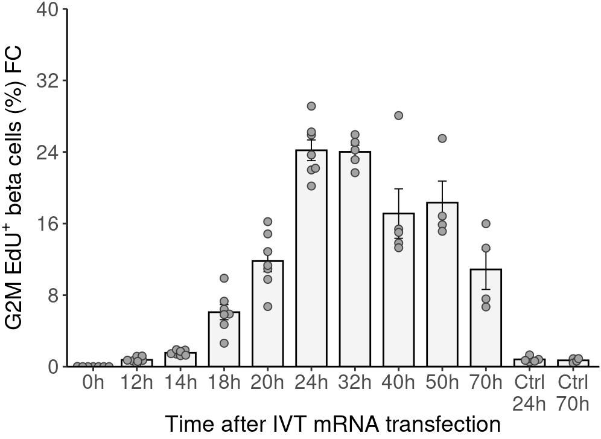

Proportion of G2M-phase EdU⁺ beta cells (% by flow cytometry) at different time points after IVT mRNA transfection. Bars show means ± SEM

```r
scale <- 2.5

p <- data_long %>%
  filter(
      grepl('G2M_CYCLE_FC', Table),
      !is.na(Proportion)
    ) %>%
  mutate(
    Time = factor(
      Time,
      levels = unique(Time),
      labels = gsub(" hour[s]?", "h", gsub("Control", "Ctrl", unique(Time)))
    ),
    Time = stringr::str_trim(Time)
  ) %>%
  mutate(
    Time = forcats::fct_relevel(Time, "Ctrl 24h", "Ctrl 70h", after = Inf)
  ) %>%
  ggplot(
    aes(x = Time, y = Proportion)
  ) +
  stat_summary(
    fun = 'mean',
    geom = 'col',
    fill = 'grey80', color = 'black',
    width = 0.7,
    alpha = 0.2
  ) +
  stat_summary(fun.data = mean_se, geom = "errorbar", width = 0.2, linewidth = 0.324) +
  scale_y_continuous(
    breaks = seq(0, 100/scale, 20/scale),
    name = expression("G2M EdU"^"+"~"beta cells (%) FC"),
    expand = expansion(mult = c(0, 0), add = c(0, 0))
  ) +
  coord_cartesian(ylim = c(0, 100/scale)) +
  scale_x_discrete(name = "Time after IVT mRNA transfection",
    labels = function(x) gsub("Ctrl (.*)", "Ctrl\n\\1", x)) +
  geom_beeswarm(
    cex = 1.01,
    fill = 'grey64',
    size = 1.97,
    shape = 21,
    color = rgb(0.2, 0.2, 0.2, 0.9),
    stroke = 0.5
  ) +
  theme_classic() +
  theme(
    plot.margin = margin(t = 5.5, r = 1, b = 1, l = 1),
    axis.text.x = element_text(size = ax_text2),
    axis.text.y = element_text(size = ax_text2),
    axis.title.x = element_text(
      size = tit_text2,
      margin = margin(t = mar2)
      ),
    axis.title.y = element_text(size = tit_text2)
  )

p
```

**Open code**

```r
if (!file.exists("gitignore/figures/fig_16.pdf")) {
  ggsave("gitignore/figures/fig_16.pdf", plot = p, width = figw3, height = figh3, units = "in")
  }
```

### 18.2.5 Summary statistics over timpoints

**Open code**

```r
kableExtra::kable(
  data_long %>%
    dplyr::filter(grepl("G2M_CYCLE_FC", Table)) %>%
    tidyr::drop_na(Proportion) %>%
    dplyr::group_by(Time) %>%
    dplyr::summarise(
      mean = mean(Proportion),
      median = quantile(Proportion, probs = 0.5),
      SD = sd(Proportion),
      SEM = sem(Proportion)
    ),
  caption = "Summary statistics for the proportion of G2M-phase EdU⁺ beta cells (% by flow cytometry) at different time points after IVT mRNA transfection. Mean, median, SD, and SEM are shown; SD, standard deviation; SEM, standard error of the mean"
)
```

Summary statistics for the proportion of G2M-phase EdU⁺ beta cells (% by flow cytometry) at different time points after IVT mRNA transfection. Mean, median, SD, and SEM are shown; SD, standard deviation; SEM, standard error of the mean

| Time | mean | median | SD | SEM |
| --- | --- | --- | --- | --- |
| 0 hours | 0.0028571 | 0.000 | 0.0075593 | 0.0028571 |
| 12 hours | 0.7585714 | 0.700 | 0.3169347 | 0.1197901 |
| 14 hours | 1.5471429 | 1.450 | 0.2717054 | 0.1026950 |
| 18 hours | 6.0914286 | 5.880 | 2.2369505 | 0.8454878 |
| 20 hours | 11.8057143 | 11.320 | 3.1824616 | 1.2028574 |
| 24 hours | 24.1842857 | 23.670 | 3.0708786 | 1.1606830 |
| 40 hours | 17.1140000 | 15.010 | 6.1834642 | 2.7653293 |
| 32 hours | 24.0100000 | 24.220 | 1.6671233 | 0.7455602 |
| 50 hours | 18.3325000 | 16.345 | 4.8353998 | 2.4176999 |
| 70 hours | 10.8700000 | 10.410 | 4.4804241 | 2.2402120 |
| Control 70 hours | 0.7025000 | 0.755 | 0.2397742 | 0.1198871 |
| Control 24 hours | 0.8133333 | 0.755 | 0.2780408 | 0.1135097 |

# 19 Divided cycle FC

## 19.1 Show Data

**Open code**

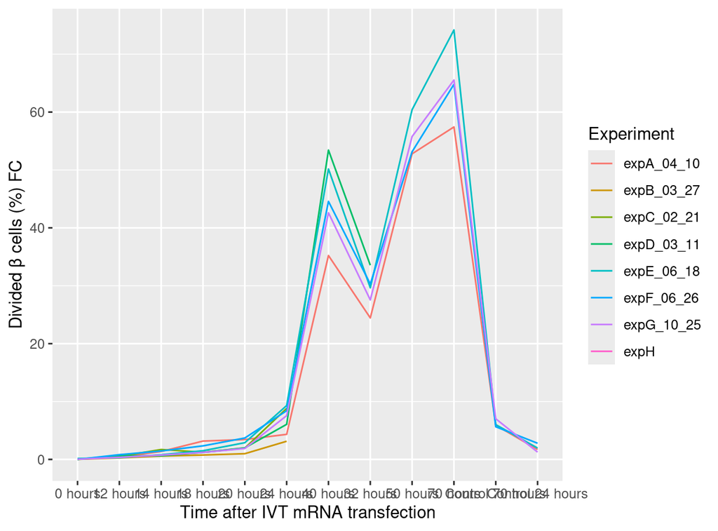

Mean proportion of divided β cells (% by flow cytometry) at different time points after IVT mRNA transfection and across individual experiments

```r
data_long %>% filter(grepl('DIVIDED_CYCLE_FC', Table)) %>%
  ggplot(
    aes(x = Time, y = Proportion, group = Experiment, color = Experiment)
    ) +
  geom_line() +
  scale_y_continuous(
    name = "Divided β cells (%) FC"
  ) +
  scale_x_discrete(name = "Time after IVT mRNA transfection")
## Warning: Removed 16 rows containing missing values or values outside the scale range
## (`geom_line()`).
```

$\Rightarrow$ Variances sharply increase as the proportion goes upward; there is a clear sign of serious heteroscedasticity

## 19.2 Models

### 19.2.1 Choose model

AIC/BIC

**Open code**

```r
model_NR <- glmmTMB::glmmTMB(
  Proportion ~ Time,
  data = data_long %>%
    filter(
      grepl('DIVIDED_CYCLE_FC', Table),
      !is.na(Proportion)
    ) %>%
    mutate(Time = factor(Time)),
  REML = FALSE
)

model_RI <- glmmTMB::glmmTMB(
  Proportion ~ Time + (1 | Experiment),
  data = data_long %>%
    filter(
      grepl('DIVIDED_CYCLE_FC', Table),
      !is.na(Proportion)
    ) %>%
    mutate(Time = factor(Time)),
  REML = FALSE
)

model_NR_difvar <- glmmTMB::glmmTMB(
  Proportion ~ Time,
  data = data_long %>%
    filter(
      grepl('DIVIDED_CYCLE_FC', Table),
      !is.na(Proportion)
    ) %>%
    mutate(Time = factor(Time)),
  REML = FALSE,
  dispformula = ~ 0 + Time,
)

model_RI_difvar <- glmmTMB::glmmTMB(
  Proportion ~ Time + (1 | Experiment),
  data = data_long %>%
    filter(
      grepl('DIVIDED_CYCLE_FC', Table),
      !is.na(Proportion)
    ) %>%
    mutate(Time = factor(Time)),
  REML = FALSE,
  dispformula = ~ Time
)

kableExtra::kable(AIC(model_NR, model_RI, model_NR_difvar, model_RI_difvar))
```

|  | df | AIC |
| --- | --- | --- |
| model_NR | 13 | 358.0519 |
| model_RI | 14 | 354.3907 |
| model_NR_difvar | 24 | 215.5430 |
| model_RI_difvar | 25 | 217.5434 |

**Open code**

```r
kableExtra::kable(BIC(model_NR, model_RI, model_NR_difvar, model_RI_difvar))
```

|  | df | BIC |
| --- | --- | --- |
| model_NR | 13 | 387.2824 |
| model_RI | 14 | 385.8696 |
| model_NR_difvar | 24 | 269.5069 |
| model_RI_difvar | 25 | 273.7557 |

Diagnostics

**Open code**

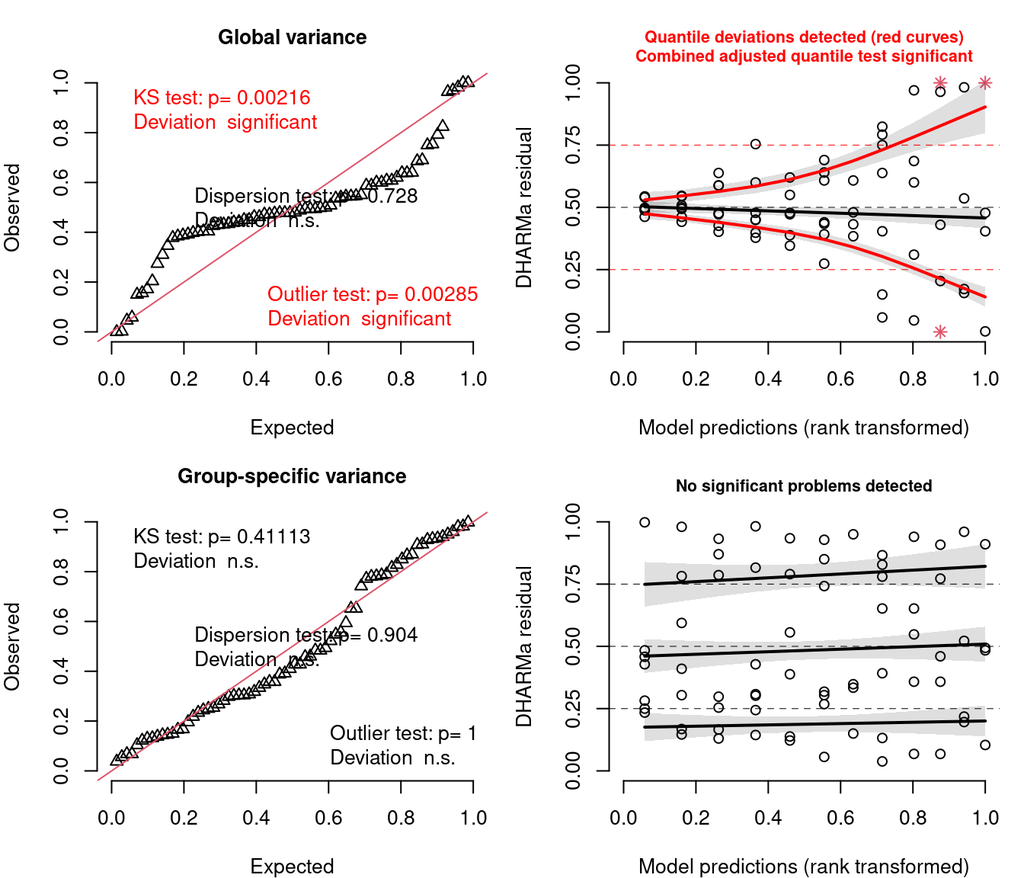

Diagnostic plots from DHARMa simulated residuals for models with and without group-specific residual variance. Top: random-intercept model with a single (global) residual variance. Bottom: random-intercept model allowing group-specific residual variance. Left: quantile–quantile plot comparing simulated residuals to the expected distribution. Right: residuals plotted against predicted values; black lines show the median (0.5) and lower/upper quartiles (0.25, 0.75) with shaded 95% simulation envelopes. Deviations from expected values suggest potential model misspecification

```r
set.seed(709)

res1 <- simulateResiduals(model_RI, n = 500)
res2 <- simulateResiduals(model_RI_difvar, n = 500)

op <- par(mfrow = c(2, 2), mar = c(4, 4, 3, 1))

plotQQunif(res1, main = "Global variance")
plotResiduals(res1, main = "")

plotQQunif(res2, main = "Group-specific variance")
plotResiduals(res2, main = "")
```

**Open code**

```r
par(op)
```

### 19.2.2 Fit final model

**Open code**

```r
model_final <- glmmTMB::glmmTMB(
  Proportion ~ Time + (1 | Experiment),
  data = data_long %>%
    filter(
      grepl('DIVIDED_CYCLE_FC', Table),
      !is.na(Proportion)
    ) %>%
    mutate(Time = factor(Time)),
  REML = TRUE,
  dispformula = ~ 0 + Time
)
```

### 19.2.3 Results

**Open code**

```r
kableExtra::kable(car::Anova(model_final))
```

|  | Chisq | Df | Pr(>Chisq) |
| --- | --- | --- | --- |
| Time | 2555.572 | 11 | 0 |

**Open code**

```r
summary(model_final)
##  Family: gaussian  ( identity )
## Formula:          Proportion ~ Time + (1 | Experiment)
## Dispersion:                  ~0 + Time
## Data:
## data_long %>% filter(grepl("DIVIDED_CYCLE_FC", Table), !is.na(Proportion)) %>%
##     mutate(Time = factor(Time))
##
##      AIC      BIC   logLik deviance df.resid
##    216.2    272.4    -83.1    166.2       57
##
## Random effects:
##
## Conditional model:
##  Groups     Name        Variance  Std.Dev.
##  Experiment (Intercept) 6.345e-11 7.965e-06
##  Residual                      NA        NA
## Number of obs: 70, groups:  Experiment, 7
##
## Conditional model:
##                      Estimate Std. Error z value Pr(>|z|)
## (Intercept)           0.03714    0.02112   1.758   0.0787 .
## Time12 hours          0.43429    0.07746   5.606 2.07e-08 ***
## Time14 hours          1.00714    0.17386   5.793 6.92e-09 ***
## Time18 hours          1.59571    0.31521   5.062 4.14e-07 ***
## Time20 hours          2.37000    0.36580   6.479 9.24e-11 ***
## Time24 hours          6.76429    0.89340   7.571 3.69e-14 ***
## Time40 hours         45.16086    3.15595  14.310  < 2e-16 ***
## Time32 hours         29.06086    1.51116  19.231  < 2e-16 ***
## Time50 hours         55.49786    1.75954  31.541  < 2e-16 ***
## Time70 hours         65.44536    3.42754  19.094  < 2e-16 ***
## TimeControl 70 hours  6.10536    0.30335  20.127  < 2e-16 ***
## TimeControl 24 hours  1.84952    0.25025   7.391 1.46e-13 ***
## ---
## Signif. codes:  0 '***' 0.001 '**' 0.01 '*' 0.05 '.' 0.1 ' ' 1
##
## Dispersion model:
##                      Estimate Std. Error z value Pr(>|z|)
## Time0 hours          -2.88435    0.28868  -9.992  < 2e-16 ***
## Time12 hours         -1.62363    0.28868  -5.624 1.86e-08 ***
## Time14 hours         -0.78400    0.28868  -2.716 0.006610 **
## Time18 hours         -0.18380    0.28868  -0.637 0.524313
## Time20 hours         -0.03438    0.28868  -0.119 0.905209
## Time24 hours          0.85995    0.28868   2.979 0.002892 **
## Time40 hours          1.95398    0.35355   5.527 3.26e-08 ***
## Time32 hours          1.21750    0.35355   3.444 0.000574 ***
## Time50 hours          1.25813    0.40825   3.082 0.002058 **
## Time70 hours          1.92497    0.40825   4.715 2.41e-06 ***
## TimeControl 70 hours -0.50216    0.40825  -1.230 0.218681
## TimeControl 24 hours -0.49300    0.31623  -1.559 0.118996
## ---
## Signif. codes:  0 '***' 0.001 '**' 0.01 '*' 0.05 '.' 0.1 ' ' 1

contrast <- con_tab(model_final)

kableExtra::kable(
  contrast,
  caption = "Estimated pairwise differences in the proportion of divided β cells (%; flow cytometry), obtained from a linear mixed-effects model with experiment as a random intercept, time as a categorical predictor and with allowance of group-specific residual variance. Columns: `contrast` (time points compared), `estimate` (mean difference in %), `CI` (Bonferroni-adjusted 95% confidence interval [lower, upper]), `SE` (standard error), `df` (degrees of freedom), `t.ratio` (test statistic), `p.value` (Bonferroni-adjusted p-value), and `stars` (significance code)"
)
```

Estimated pairwise differences in the proportion of divided β cells (%; flow cytometry), obtained from a linear mixed-effects model with experiment as a random intercept, time as a categorical predictor and with allowance of group-specific residual variance. Columns: `contrast` (time points compared), `estimate` (mean difference in %), `CI` (Bonferroni-adjusted 95% confidence interval [lower, upper]), `SE` (standard error), `df` (degrees of freedom), `t.ratio` (test statistic), `p.value` (Bonferroni-adjusted p-value), and `stars` (significance code)

| contrast | estimate | CI | SE | df | t.ratio | p.value | stars |
| --- | --- | --- | --- | --- | --- | --- | --- |
| 0 hours - 12 hours | -0.43 | [-0.71, -0.16] | 0.08 | 57 | -5.61 | 0.0000415 | *** |
| 0 hours - 14 hours | -1.01 | [-1.63, -0.39] | 0.17 | 57 | -5.79 | 0.0000207 | *** |
| 0 hours - 18 hours | -1.60 | [-2.72, -0.47] | 0.32 | 57 | -5.06 | 0.0003056 | *** |
| 0 hours - 20 hours | -2.37 | [-3.67, -1.07] | 0.37 | 57 | -6.48 | 0.0000015 | *** |
| 0 hours - 24 hours | -6.76 | [-9.94, -3.58] | 0.89 | 57 | -7.57 | 0.0000000 | *** |
| 0 hours - 40 hours | -45.16 | [-56.39, -33.93] | 3.16 | 57 | -14.31 | 0.0000000 | *** |
| 0 hours - 32 hours | -29.06 | [-34.44, -23.68] | 1.51 | 57 | -19.23 | 0.0000000 | *** |
| 0 hours - 50 hours | -55.50 | [-61.76, -49.23] | 1.76 | 57 | -31.54 | 0.0000000 | *** |
| 0 hours - 70 hours | -65.45 | [-77.65, -53.25] | 3.43 | 57 | -19.09 | 0.0000000 | *** |
| 0 hours - Control 70 hours | -6.11 | [-7.19, -5.03] | 0.30 | 57 | -20.13 | 0.0000000 | *** |
| 0 hours - Control 24 hours | -1.85 | [-2.74, -0.96] | 0.25 | 57 | -7.39 | 0.0000000 | *** |
| 12 hours - 14 hours | -0.57 | [-1.24, 0.10] | 0.19 | 57 | -3.05 | 0.2305862 | ns |
| 12 hours - 18 hours | -1.16 | [-2.31, -0.01] | 0.32 | 57 | -3.59 | 0.0449808 | * |
| 12 hours - 20 hours | -1.94 | [-3.26, -0.61] | 0.37 | 57 | -5.19 | 0.0001898 | *** |
| 12 hours - 24 hours | -6.33 | [-9.52, -3.14] | 0.90 | 57 | -7.06 | 0.0000002 | *** |
| 12 hours - 40 hours | -44.73 | [-55.96, -33.49] | 3.16 | 57 | -14.17 | 0.0000000 | *** |
| 12 hours - 32 hours | -28.63 | [-34.01, -23.24] | 1.51 | 57 | -18.92 | 0.0000000 | *** |
| 12 hours - 50 hours | -55.06 | [-61.33, -48.80] | 1.76 | 57 | -31.27 | 0.0000000 | *** |
| 12 hours - 70 hours | -65.01 | [-77.21, -52.81] | 3.43 | 57 | -18.96 | 0.0000000 | *** |
| 12 hours - Control 70 hours | -5.67 | [-6.78, -4.56] | 0.31 | 57 | -18.20 | 0.0000000 | *** |
| 12 hours - Control 24 hours | -1.42 | [-2.34, -0.49] | 0.26 | 57 | -5.44 | 0.0000774 | *** |
| 14 hours - 18 hours | -0.59 | [-1.87, 0.69] | 0.36 | 57 | -1.64 | 1.0000000 | ns |
| 14 hours - 20 hours | -1.36 | [-2.80, 0.07] | 0.40 | 57 | -3.37 | 0.0882582 | ns |
| 14 hours - 24 hours | -5.76 | [-9.00, -2.52] | 0.91 | 57 | -6.33 | 0.0000027 | *** |
| 14 hours - 40 hours | -44.15 | [-55.40, -32.90] | 3.16 | 57 | -13.97 | 0.0000000 | *** |
| 14 hours - 32 hours | -28.05 | [-33.47, -22.64] | 1.52 | 57 | -18.45 | 0.0000000 | *** |
| 14 hours - 50 hours | -54.49 | [-60.78, -48.20] | 1.77 | 57 | -30.82 | 0.0000000 | *** |
| 14 hours - 70 hours | -64.44 | [-76.65, -52.22] | 3.43 | 57 | -18.78 | 0.0000000 | *** |
| 14 hours - Control 70 hours | -5.10 | [-6.34, -3.86] | 0.35 | 57 | -14.63 | 0.0000000 | *** |
| 14 hours - Control 24 hours | -0.84 | [-1.92, 0.24] | 0.30 | 57 | -2.78 | 0.4880290 | ns |
| 18 hours - 20 hours | -0.77 | [-2.49, 0.94] | 0.48 | 57 | -1.61 | 1.0000000 | ns |
| 18 hours - 24 hours | -5.17 | [-8.54, -1.80] | 0.95 | 57 | -5.46 | 0.0000718 | *** |
| 18 hours - 40 hours | -43.57 | [-54.85, -32.28] | 3.17 | 57 | -13.74 | 0.0000000 | *** |
| 18 hours - 32 hours | -27.47 | [-32.96, -21.97] | 1.54 | 57 | -17.80 | 0.0000000 | *** |
| 18 hours - 50 hours | -53.90 | [-60.26, -47.54] | 1.79 | 57 | -30.16 | 0.0000000 | *** |
| 18 hours - 70 hours | -63.85 | [-76.10, -51.60] | 3.44 | 57 | -18.55 | 0.0000000 | *** |
| 18 hours - Control 70 hours | -4.51 | [-6.06, -2.96] | 0.44 | 57 | -10.33 | 0.0000000 | *** |
| 18 hours - Control 24 hours | -0.25 | [-1.68, 1.17] | 0.40 | 57 | -0.63 | 1.0000000 | ns |
| 20 hours - 24 hours | -4.39 | [-7.83, -0.96] | 0.96 | 57 | -4.55 | 0.0018596 | ** |
| 20 hours - 40 hours | -42.79 | [-54.10, -31.48] | 3.18 | 57 | -13.47 | 0.0000000 | *** |
| 20 hours - 32 hours | -26.69 | [-32.22, -21.16] | 1.55 | 57 | -17.17 | 0.0000000 | *** |
| 20 hours - 50 hours | -53.13 | [-59.52, -46.73] | 1.80 | 57 | -29.57 | 0.0000000 | *** |
| 20 hours - 70 hours | -63.08 | [-75.34, -50.81] | 3.45 | 57 | -18.30 | 0.0000000 | *** |
| 20 hours - Control 70 hours | -3.74 | [-5.42, -2.05] | 0.47 | 57 | -7.88 | 0.0000000 | *** |
| 20 hours - Control 24 hours | 0.52 | [-1.05, 2.09] | 0.44 | 57 | 1.18 | 1.0000000 | ns |
| 24 hours - 40 hours | -38.40 | [-50.07, -26.72] | 3.28 | 57 | -11.71 | 0.0000000 | *** |
| 24 hours - 32 hours | -22.30 | [-28.54, -16.05] | 1.76 | 57 | -12.70 | 0.0000000 | *** |
| 24 hours - 50 hours | -48.73 | [-55.76, -41.71] | 1.97 | 57 | -24.70 | 0.0000000 | *** |
| 24 hours - 70 hours | -58.68 | [-71.29, -46.07] | 3.54 | 57 | -16.57 | 0.0000000 | *** |
| 24 hours - Control 70 hours | 0.66 | [-2.70, 4.02] | 0.94 | 57 | 0.70 | 1.0000000 | ns |
| 24 hours - Control 24 hours | 4.91 | [1.61, 8.22] | 0.93 | 57 | 5.30 | 0.0001286 | *** |
| 40 hours - 32 hours | 16.10 | [3.65, 28.55] | 3.50 | 57 | 4.60 | 0.0015764 | ** |
| 40 hours - 50 hours | -10.34 | [-23.20, 2.52] | 3.61 | 57 | -2.86 | 0.3891062 | ns |
| 40 hours - 70 hours | -20.28 | [-36.87, -3.70] | 4.66 | 57 | -4.35 | 0.0037129 | ** |
| 40 hours - Control 70 hours | 39.06 | [27.77, 50.34] | 3.17 | 57 | 12.32 | 0.0000000 | *** |
| 40 hours - Control 24 hours | 43.31 | [32.04, 54.58] | 3.17 | 57 | 13.68 | 0.0000000 | *** |
| 32 hours - 50 hours | -26.44 | [-34.69, -18.18] | 2.32 | 57 | -11.40 | 0.0000000 | *** |
| 32 hours - 70 hours | -36.38 | [-49.72, -23.05] | 3.75 | 57 | -9.71 | 0.0000000 | *** |
| 32 hours - Control 70 hours | 22.96 | [17.47, 28.44] | 1.54 | 57 | 14.90 | 0.0000000 | *** |
| 32 hours - Control 24 hours | 27.21 | [21.76, 32.66] | 1.53 | 57 | 17.77 | 0.0000000 | *** |
| 50 hours - 70 hours | -9.95 | [-23.66, 3.77] | 3.85 | 57 | -2.58 | 0.8196166 | ns |
| 50 hours - Control 70 hours | 49.39 | [43.04, 55.75] | 1.79 | 57 | 27.67 | 0.0000000 | *** |
| 50 hours - Control 24 hours | 53.65 | [47.32, 59.97] | 1.78 | 57 | 30.19 | 0.0000000 | *** |
| 70 hours - Control 70 hours | 59.34 | [47.09, 71.59] | 3.44 | 57 | 17.25 | 0.0000000 | *** |
| 70 hours - Control 24 hours | 63.60 | [51.36, 75.83] | 3.44 | 57 | 18.51 | 0.0000000 | *** |
| Control 70 hours - Control 24 hours | 4.26 | [2.86, 5.65] | 0.39 | 57 | 10.85 | 0.0000000 | *** |

### 19.2.4 Visualisation

**Open code**

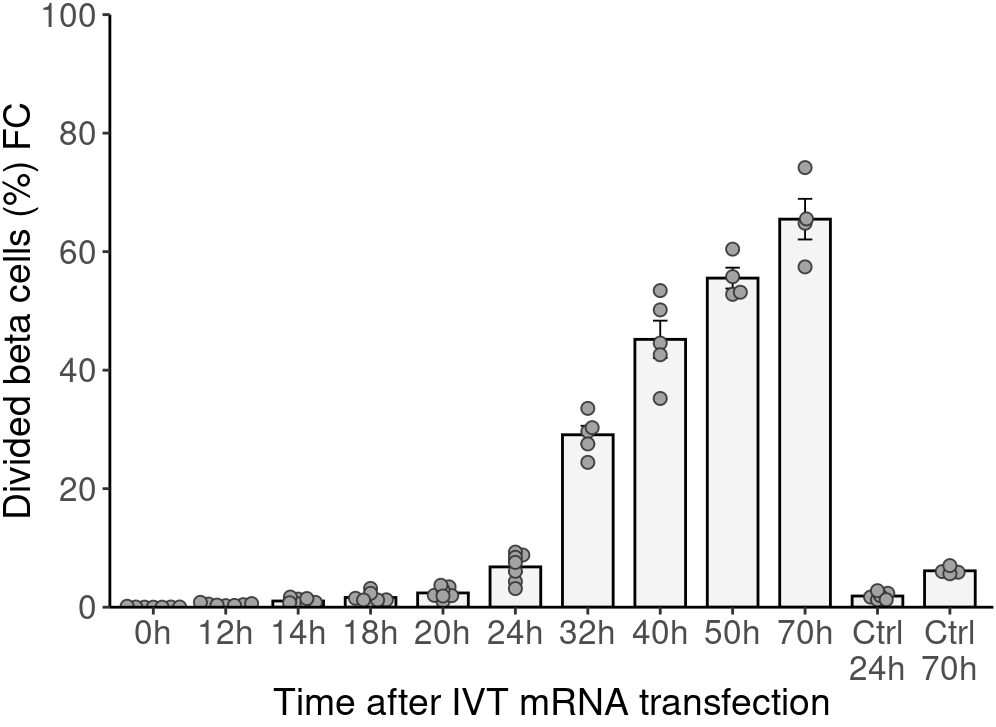

Proportion of divided beta cells (% by flow cytometry) at different time points after IVT mRNA transfection. Bars show means ± SEM

```r
scale <- 1

p <- data_long %>%
  filter(
      grepl('DIVIDED_CYCLE_FC', Table),
      !is.na(Proportion)
    ) %>%
  mutate(
    Time = factor(
      Time,
      levels = unique(Time),
      labels = gsub(" hour[s]?", "h", gsub("Control", "Ctrl", unique(Time)))
    ),
    Time = stringr::str_trim(Time)
  ) %>%
  mutate(
    Time = forcats::fct_relevel(Time, "Ctrl 24h", "Ctrl 70h", after = Inf)
  ) %>%
  ggplot(
    aes(x = Time, y = Proportion)
  ) +
  stat_summary(
    fun = 'mean',
    geom = 'col',
    fill = 'grey80', color = 'black',
    width = 0.7,
    alpha = 0.2
  ) +
  stat_summary(fun.data = mean_se, geom = "errorbar", width = 0.2, linewidth = 0.324) +
  scale_y_continuous(
    breaks = seq(0, 100/scale, 20/scale),
    name = "Divided beta cells (%) FC",
    expand = expansion(mult = c(0, 0), add = c(0, 0))
  ) +
  coord_cartesian(ylim = c(0, 100/scale)) +
  scale_x_discrete(name = "Time after IVT mRNA transfection",
    labels = function(x) gsub("Ctrl (.*)", "Ctrl\n\\1", x)) +
  geom_beeswarm(
    cex = 1.01,
    fill = 'grey64',
    size = 1.97,
    shape = 21,
    color = rgb(0.2, 0.2, 0.2, 0.9),
    stroke = 0.5
  ) +
  theme_classic() +
  theme(
    plot.margin = margin(t = 5.5, r = 1, b = 1, l = 1),
    axis.text.x = element_text(size = ax_text2),
    axis.text.y = element_text(size = ax_text2),
    axis.title.x = element_text(
      size = tit_text2,
      margin = margin(t = mar2)
      ),
    axis.title.y = element_text(size = tit_text2, margin = margin(r = 0.4))
  )

p
```

**Open code**

```r
if (!file.exists("gitignore/figures/fig_17.pdf")) {
  ggsave("gitignore/figures/fig_17.pdf", plot = p, width = figw3, height = figh3, units = "in")
  ggsave("gitignore/figures/fig_17.svg", plot = p, width = figw3, height = figh3, units = "in")
  }
```

### 19.2.5 Summary statistics over timpoints

**Open code**

```r
kableExtra::kable(
  data_long %>%
    dplyr::filter(grepl("DIVIDED_CYCLE_FC", Table)) %>%
    tidyr::drop_na(Proportion) %>%
    dplyr::group_by(Time) %>%
    dplyr::summarise(
      mean = mean(Proportion),
      median = quantile(Proportion, probs = 0.5),
      SD = sd(Proportion),
      SEM = sem(Proportion)
    ),
  caption = "Summary statistics for the proportion of divided beta cells (% by flow cytometry) at different time points after IVT mRNA transfection. Mean, median, SD, and SEM are shown; SD, standard deviation; SEM, standard error of the mean"
)
```

Summary statistics for the proportion of divided beta cells (% by flow cytometry) at different time points after IVT mRNA transfection. Mean, median, SD, and SEM are shown; SD, standard deviation; SEM, standard error of the mean

| Time | mean | median | SD | SEM |
| --- | --- | --- | --- | --- |
| 0 hours | 0.0371429 | 0.030 | 0.0558911 | 0.0211248 |
| 12 hours | 0.4714286 | 0.420 | 0.1971825 | 0.0745280 |
| 14 hours | 1.0442857 | 0.810 | 0.4565763 | 0.1725696 |
| 18 hours | 1.6328571 | 1.240 | 0.8321000 | 0.3145043 |
| 20 hours | 2.4071429 | 2.000 | 0.9662076 | 0.3651921 |
| 24 hours | 6.8014286 | 7.560 | 2.3630448 | 0.8931470 |
| 40 hours | 45.1980000 | 44.570 | 7.0567535 | 3.1558761 |
| 32 hours | 29.0980000 | 29.650 | 3.3787231 | 1.5110109 |
| 50 hours | 55.5350000 | 54.465 | 3.5188303 | 1.7594151 |
| 70 hours | 65.4825000 | 65.160 | 6.8549514 | 3.4274757 |
| Control 70 hours | 6.1425000 | 5.955 | 0.6052203 | 0.3026102 |
| Control 24 hours | 1.8866667 | 1.835 | 0.6107918 | 0.2493547 |

# 20 2nd S cycle FC

## 20.1 Show Data

**Open code**

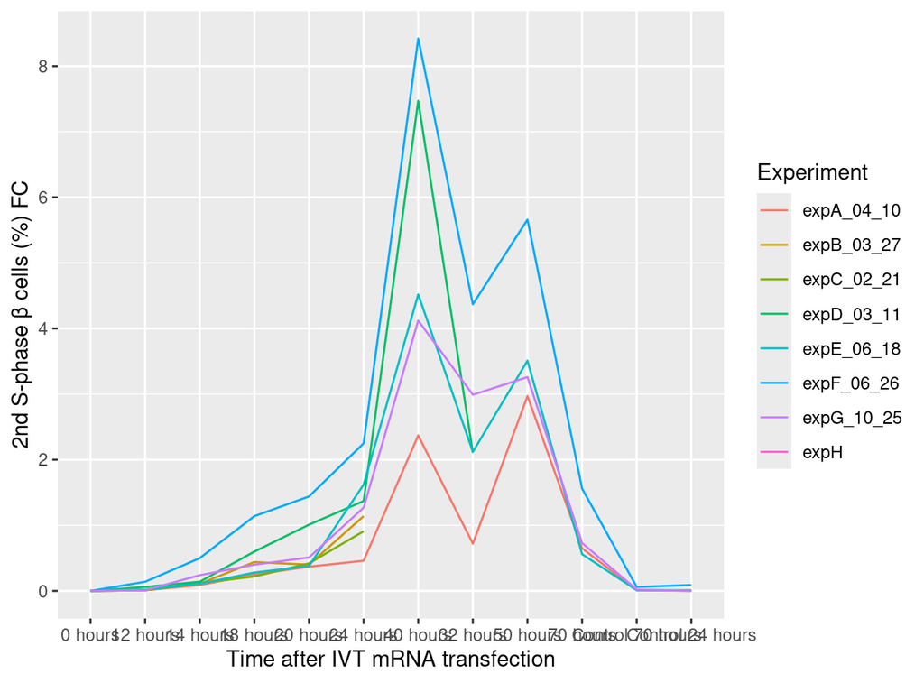

Mean proportion of 2nd S-phase β cells (% by flow cytometry) at different time points after IVT mRNA transfection and across individual experiments

```r
data_long %>% filter(grepl('2ND_S_CYCLE_FC', Table)) %>%
  ggplot(
    aes(x = Time, y = Proportion, group = Experiment, color = Experiment)
    ) +
  geom_line() +
  scale_y_continuous(
    name = "2nd S-phase β cells (%) FC"
  ) +
  scale_x_discrete(name = "Time after IVT mRNA transfection")
## Warning: Removed 16 rows containing missing values or values outside the scale range
## (`geom_line()`).
```

$\Rightarrow$ Variances sharply vary, clear heteroscedasticity

## 20.2 Models

### 20.2.1 Choose model

AIC/BIC

**Open code**

```r
model_NR <- glmmTMB::glmmTMB(
  Proportion ~ Time,
  data = data_long %>%
    filter(
      grepl('2ND_S_CYCLE_FC', Table),
      !is.na(Proportion)
    ) %>%
    mutate(Time = factor(Time)),
  REML = FALSE
)

model_RI <- glmmTMB::glmmTMB(
  Proportion ~ Time + (1 | Experiment),
  data = data_long %>%
    filter(
      grepl('2ND_S_CYCLE_FC', Table),
      !is.na(Proportion)
    ) %>%
    mutate(Time = factor(Time)),
  REML = FALSE
)

model_NR_difvar <- glmmTMB::glmmTMB(
  Proportion ~ Time,
  data = data_long %>%
    filter(
      grepl('2ND_S_CYCLE_FC', Table),
      !is.na(Proportion)
    ) %>%
    mutate(Time = factor(Time)),
  REML = FALSE,
  dispformula = ~ 0 + Time
)
## Warning in finalizeTMB(TMBStruc, obj, fit, h, data.tmb.old): failed to invert
## Hessian from numDeriv::jacobian(), falling back to internal vcov estimate
## Warning in finalizeTMB(TMBStruc, obj, fit, h, data.tmb.old): Model convergence
## problem; false convergence (8). See vignette('troubleshooting'),
## help('diagnose')

model_RI_difvar <- glmmTMB::glmmTMB(
  Proportion ~ Time + (1 | Experiment),
  data = data_long %>%
    filter(
      grepl('2ND_S_CYCLE_FC', Table),
      !is.na(Proportion)
    ) %>%
    mutate(Time = factor(Time)),
  REML = FALSE,
  dispformula = ~ 0 + Time
)

kableExtra::kable(AIC(model_NR, model_RI,  model_RI_difvar))
```

|  | df | AIC |
| --- | --- | --- |
| model_NR | 13 | 187.288958 |
| model_RI | 14 | 175.463412 |
| model_RI_difvar | 25 | -1.351265 |

**Open code**

```r
kableExtra::kable(BIC(model_NR, model_RI,  model_RI_difvar))
```

|  | df | BIC |
| --- | --- | --- |
| model_NR | 13 | 216.51940 |
| model_RI | 14 | 206.94235 |
| model_RI_difvar | 25 | 54.86112 |

Diagnostics

**Open code**

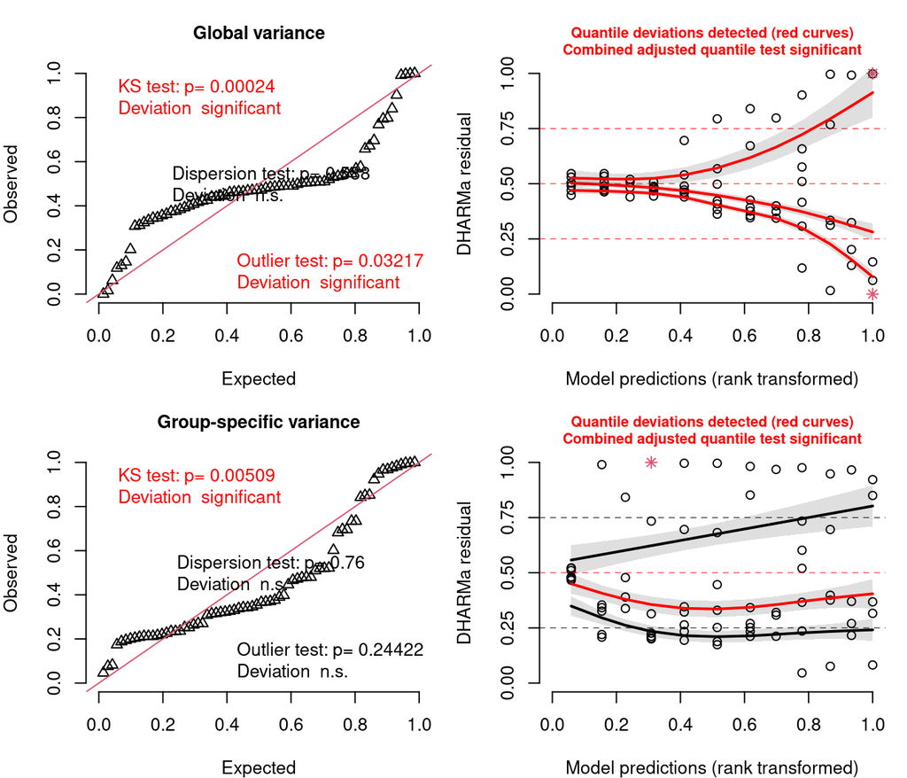

Diagnostic plots from DHARMa simulated residuals for models with and without group-specific residual variance. Top: random-intercept model with a single (global) residual variance. Bottom: random-intercept model allowing group-specific residual variance. Left: quantile–quantile plot comparing simulated residuals to the expected distribution. Right: residuals plotted against predicted values; black lines show the median (0.5) and lower/upper quartiles (0.25, 0.75) with shaded 95% simulation envelopes. Deviations from expected values suggest potential model misspecification

```r
set.seed(709)

res1 <- simulateResiduals(model_RI, n = 500)
res2 <- simulateResiduals(model_RI_difvar, n = 500)

op <- par(mfrow = c(2, 2), mar = c(4, 4, 3, 1))

plotQQunif(res1, main = "Global variance")
plotResiduals(res1, main = "")
## qu = 0.75, log(sigma) = -2.420295 : outer Newton did not converge fully.

plotQQunif(res2, main = "Group-specific variance")
plotResiduals(res2, main = "")
```

**Open code**

```r
par(op)
```

$\Rightarrow$ The random-intercept model with group-specific variance provided the best fit according to both AIC and BIC, and sharply improved model diagnostics although some assumptions violation remains. Random-intercept model with allowance of group-specific residual variance will be retained.

AIC and BIC for model without random intercept but allowing group-specific variance did not converge and is not thus presented.

### 20.2.2 Fit final model

**Open code**

```r
model_final <- glmmTMB::glmmTMB(
  Proportion ~ Time + (1 | Experiment),
  data = data_long %>%
    filter(
      grepl('2ND_S_CYCLE_FC', Table),
      !is.na(Proportion)
    ),
  REML = TRUE,
  dispformula = ~ 0 + Time
)
```

### 20.2.3 Results

**Open code**

```r
kableExtra::kable(car::Anova(model_final))
```

|  | Chisq | Df | Pr(>Chisq) |
| --- | --- | --- | --- |
| Time | 193.8273 | 11 | 0 |

**Open code**

```r
contrast <- con_tab(model_final)

kableExtra::kable(
  contrast,
  caption = "Estimated pairwise differences in the proportion of 2nd S-phase β cells (%; flow cytometry), obtained from a linear mixed-effects model with experiment as a random intercept, time as a categorical predictor, and allowance for group-specific residual variance. Columns: `contrast` (time points compared), `estimate` (mean difference in %), `CI` (Bonferroni-adjusted 95% confidence interval [lower, upper]), `SE` (standard error), `df` (degrees of freedom), `t.ratio` (test statistic), `p.value` (Bonferroni-adjusted p-value), and `stars` (significance code)"
)
```

Estimated pairwise differences in the proportion of 2nd S-phase β cells (%; flow cytometry), obtained from a linear mixed-effects model with experiment as a random intercept, time as a categorical predictor, and allowance for group-specific residual variance. Columns: `contrast` (time points compared), `estimate` (mean difference in %), `CI` (Bonferroni-adjusted 95% confidence interval [lower, upper]), `SE` (standard error), `df` (degrees of freedom), `t.ratio` (test statistic), `p.value` (Bonferroni-adjusted p-value), and `stars` (significance code)

| contrast | estimate | CI | SE | df | t.ratio | p.value | stars |
| --- | --- | --- | --- | --- | --- | --- | --- |
| 0 hours - 12 hours | -0.04 | [-0.09, 0.01] | 0.01 | 57 | -2.62 | 0.7482096 | ns |
| 0 hours - 14 hours | -0.19 | [-0.35, -0.02] | 0.05 | 57 | -3.97 | 0.0132729 | * |
| 0 hours - 18 hours | -0.48 | [-0.87, -0.08] | 0.11 | 57 | -4.31 | 0.0043552 | ** |
| 0 hours - 20 hours | -0.65 | [-1.17, -0.13] | 0.15 | 57 | -4.42 | 0.0029141 | ** |
| 0 hours - 24 hours | -1.29 | [-2.01, -0.57] | 0.20 | 57 | -6.35 | 0.0000025 | *** |
| 0 hours - 40 hours | -5.38 | [-9.30, -1.45] | 1.10 | 57 | -4.87 | 0.0006015 | *** |
| 0 hours - 32 hours | -2.46 | [-4.55, -0.37] | 0.59 | 57 | -4.19 | 0.0065722 | ** |
| 0 hours - 50 hours | -3.85 | [-5.95, -1.74] | 0.59 | 57 | -6.50 | 0.0000014 | *** |
| 0 hours - 70 hours | -0.87 | [-1.62, -0.12] | 0.21 | 57 | -4.15 | 0.0074496 | ** |
| 0 hours - Control 70 hours | -0.02 | [-0.08, 0.04] | 0.02 | 57 | -1.35 | 1.0000000 | ns |
| 0 hours - Control 24 hours | -0.02 | [-0.07, 0.02] | 0.01 | 57 | -1.77 | 1.0000000 | ns |
| 12 hours - 14 hours | -0.15 | [-0.31, 0.01] | 0.05 | 57 | -3.26 | 0.1230091 | ns |
| 12 hours - 18 hours | -0.44 | [-0.83, -0.05] | 0.11 | 57 | -3.99 | 0.0126799 | * |
| 12 hours - 20 hours | -0.61 | [-1.13, -0.09] | 0.15 | 57 | -4.18 | 0.0066781 | ** |
| 12 hours - 24 hours | -1.25 | [-1.97, -0.53] | 0.20 | 57 | -6.17 | 0.0000049 | *** |
| 12 hours - 40 hours | -5.34 | [-9.26, -1.41] | 1.10 | 57 | -4.84 | 0.0006778 | *** |
| 12 hours - 32 hours | -2.42 | [-4.51, -0.33] | 0.59 | 57 | -4.12 | 0.0081077 | ** |
| 12 hours - 50 hours | -3.81 | [-5.92, -1.70] | 0.59 | 57 | -6.44 | 0.0000018 | *** |
| 12 hours - 70 hours | -0.84 | [-1.58, -0.09] | 0.21 | 57 | -3.98 | 0.0131778 | * |
| 12 hours - Control 70 hours | 0.01 | [-0.03, 0.06] | 0.01 | 57 | 1.14 | 1.0000000 | ns |
| 12 hours - Control 24 hours | 0.01 | [-0.01, 0.04] | 0.01 | 57 | 2.02 | 1.0000000 | ns |
| 14 hours - 18 hours | -0.29 | [-0.71, 0.13] | 0.12 | 57 | -2.43 | 1.0000000 | ns |
| 14 hours - 20 hours | -0.46 | [-1.00, 0.08] | 0.15 | 57 | -3.01 | 0.2542637 | ns |
| 14 hours - 24 hours | -1.10 | [-1.84, -0.36] | 0.21 | 57 | -5.30 | 0.0001268 | *** |
| 14 hours - 40 hours | -5.19 | [-9.12, -1.26] | 1.10 | 57 | -4.70 | 0.0011129 | ** |
| 14 hours - 32 hours | -2.27 | [-4.37, -0.17] | 0.59 | 57 | -3.86 | 0.0195046 | * |
| 14 hours - 50 hours | -3.66 | [-5.77, -1.55] | 0.59 | 57 | -6.17 | 0.0000050 | *** |
| 14 hours - 70 hours | -0.69 | [-1.45, 0.08] | 0.21 | 57 | -3.19 | 0.1527061 | ns |
| 14 hours - Control 70 hours | 0.16 | [-0.00, 0.33] | 0.05 | 57 | 3.52 | 0.0556926 | ns |
| 14 hours - Control 24 hours | 0.16 | [0.00, 0.33] | 0.05 | 57 | 3.62 | 0.0410402 | * |
| 18 hours - 20 hours | -0.17 | [-0.82, 0.48] | 0.18 | 57 | -0.94 | 1.0000000 | ns |
| 18 hours - 24 hours | -0.81 | [-1.63, 0.01] | 0.23 | 57 | -3.53 | 0.0552370 | ns |
| 18 hours - 40 hours | -4.90 | [-8.84, -0.95] | 1.11 | 57 | -4.42 | 0.0029477 | ** |
| 18 hours - 32 hours | -1.98 | [-4.11, 0.14] | 0.60 | 57 | -3.32 | 0.1044061 | ns |
| 18 hours - 50 hours | -3.37 | [-5.51, -1.23] | 0.60 | 57 | -5.60 | 0.0000420 | *** |
| 18 hours - 70 hours | -0.40 | [-1.24, 0.45] | 0.24 | 57 | -1.67 | 1.0000000 | ns |
| 18 hours - Control 70 hours | 0.45 | [0.06, 0.85] | 0.11 | 57 | 4.11 | 0.0084581 | ** |
| 18 hours - Control 24 hours | 0.45 | [0.06, 0.84] | 0.11 | 57 | 4.13 | 0.0079157 | ** |
| 20 hours - 24 hours | -0.64 | [-1.53, 0.25] | 0.25 | 57 | -2.57 | 0.8457450 | ns |
| 20 hours - 40 hours | -4.73 | [-8.69, -0.77] | 1.11 | 57 | -4.25 | 0.0052774 | ** |
| 20 hours - 32 hours | -1.81 | [-3.96, 0.34] | 0.60 | 57 | -2.99 | 0.2693212 | ns |
| 20 hours - 50 hours | -3.20 | [-5.37, -1.03] | 0.61 | 57 | -5.25 | 0.0001535 | *** |
| 20 hours - 70 hours | -0.23 | [-1.13, 0.68] | 0.26 | 57 | -0.88 | 1.0000000 | ns |
| 20 hours - Control 70 hours | 0.62 | [0.10, 1.15] | 0.15 | 57 | 4.27 | 0.0048590 | ** |
| 20 hours - Control 24 hours | 0.62 | [0.11, 1.14] | 0.15 | 57 | 4.29 | 0.0046694 | ** |
| 24 hours - 40 hours | -4.09 | [-8.08, -0.10] | 1.12 | 57 | -3.64 | 0.0382914 | * |
| 24 hours - 32 hours | -1.17 | [-3.38, 1.04] | 0.62 | 57 | -1.88 | 1.0000000 | ns |
| 24 hours - 50 hours | -2.56 | [-4.78, -0.33] | 0.63 | 57 | -4.09 | 0.0090039 | ** |
| 24 hours - 70 hours | 0.42 | [-0.62, 1.45] | 0.29 | 57 | 1.43 | 1.0000000 | ns |
| 24 hours - Control 70 hours | 1.27 | [0.54, 1.99] | 0.20 | 57 | 6.24 | 0.0000038 | *** |
| 24 hours - Control 24 hours | 1.27 | [0.54, 1.99] | 0.20 | 57 | 6.25 | 0.0000037 | *** |
| 40 hours - 32 hours | 2.92 | [-1.53, 7.36] | 1.25 | 57 | 2.34 | 1.0000000 | ns |
| 40 hours - 50 hours | 1.53 | [-2.93, 5.98] | 1.25 | 57 | 1.22 | 1.0000000 | ns |
| 40 hours - 70 hours | 4.50 | [0.51, 8.50] | 1.12 | 57 | 4.01 | 0.0117446 | * |
| 40 hours - Control 70 hours | 5.35 | [1.43, 9.28] | 1.10 | 57 | 4.85 | 0.0006465 | *** |
| 40 hours - Control 24 hours | 5.35 | [1.43, 9.28] | 1.10 | 57 | 4.85 | 0.0006459 | *** |
| 32 hours - 50 hours | -1.39 | [-4.36, 1.58] | 0.83 | 57 | -1.67 | 1.0000000 | ns |
| 32 hours - 70 hours | 1.58 | [-0.63, 3.80] | 0.62 | 57 | 2.54 | 0.9077452 | ns |
| 32 hours - Control 70 hours | 2.43 | [0.35, 4.52] | 0.59 | 57 | 4.15 | 0.0074630 | ** |
| 32 hours - Control 24 hours | 2.43 | [0.35, 4.52] | 0.59 | 57 | 4.15 | 0.0074455 | ** |
| 50 hours - 70 hours | 2.98 | [0.74, 5.21] | 0.63 | 57 | 4.74 | 0.0009725 | *** |
| 50 hours - Control 70 hours | 3.83 | [1.72, 5.93] | 0.59 | 57 | 6.46 | 0.0000016 | *** |
| 50 hours - Control 24 hours | 3.82 | [1.72, 5.93] | 0.59 | 57 | 6.46 | 0.0000016 | *** |
| 70 hours - Control 70 hours | 0.85 | [0.10, 1.60] | 0.21 | 57 | 4.04 | 0.0105427 | * |
| 70 hours - Control 24 hours | 0.85 | [0.10, 1.60] | 0.21 | 57 | 4.05 | 0.0103575 | * |
| Control 70 hours - Control 24 hours | 0.00 | [-0.04, 0.04] | 0.01 | 57 | 0.00 | 1.0000000 | ns |

### 20.2.4 Visualisation

**Open code**

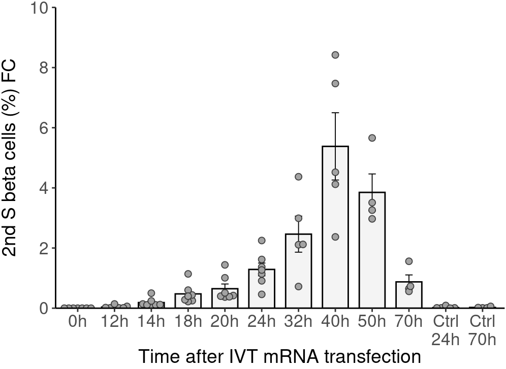

Proportion of 2nd S-phase beta cells (% by flow cytometry) at different time points after IVT mRNA transfection. Bars show means ± SEM

```r
scale <- 10

p <- data_long %>%
  filter(
      grepl('2ND_S_CYCLE_FC', Table),
      !is.na(Proportion)
    ) %>%
  mutate(
    Time = factor(
      Time,
      levels = unique(Time),
      labels = gsub(" hour[s]?", "h", gsub("Control", "Ctrl", unique(Time)))
    ),
    Time = stringr::str_trim(Time)
  ) %>%
  mutate(
    Time = forcats::fct_relevel(Time, "Ctrl 24h", "Ctrl 70h", after = Inf)
  ) %>%
  ggplot(
    aes(x = Time, y = Proportion)
  ) +
  stat_summary(
    fun = 'mean',
    geom = 'col',
    fill = 'grey80', color = 'black',
    width = 0.7,
    alpha = 0.2
  ) +
  stat_summary(fun.data = mean_se, geom = "errorbar", width = 0.2, linewidth = 0.324) +
  scale_y_continuous(
    breaks = seq(0, 100/scale, 20/scale),
    name = "2nd S beta cells (%) FC",
    expand = expansion(mult = c(0, 0), add = c(0, 0))
  ) +
  coord_cartesian(ylim = c(0, 100/scale)) +
  scale_x_discrete(name = "Time after IVT mRNA transfection",
    labels = function(x) gsub("Ctrl (.*)", "Ctrl\n\\1", x)) +
  geom_beeswarm(
    cex = 1.01,
    fill = 'grey64',
    size = 1.97,
    shape = 21,
    color = rgb(0.2, 0.2, 0.2, 0.9),
    stroke = 0.5
  ) +
  theme_classic() +
  theme(
    plot.margin = margin(t = 5.5, r = 1, b = 1, l = 1),
    axis.text.x = element_text(size = ax_text2),
    axis.text.y = element_text(size = ax_text2),
    axis.title.x = element_text(
      size = tit_text2,
      margin = margin(t = mar2)
      ),
    axis.title.y = element_text(size = tit_text2, margin = margin(r = 7.4))
  )

p
```

**Open code**

```r
if (!file.exists("gitignore/figures/fig_18.pdf")) {
  ggsave("gitignore/figures/fig_18.pdf", plot = p, width = figw3, height = figh3, units = "in")
  ggsave("gitignore/figures/fig_18.svg", plot = p, width = figw3, height = figh3, units = "in")
  }
```

### 20.2.5 Summary statistics over timpoints

**Open code**

```r
kableExtra::kable(
  data_long %>%
    dplyr::filter(grepl("2ND_S_CYCLE_FC", Table)) %>%
    tidyr::drop_na(Proportion) %>%
    dplyr::group_by(Time) %>%
    dplyr::summarise(
      mean = mean(Proportion),
      median = quantile(Proportion, probs = 0.5),
      SD = sd(Proportion),
      SEM = sem(Proportion)
    ),
  caption = "Summary statistics for the proportion of 2nd S-phase beta cells (% by flow cytometry) at different time points after IVT mRNA transfection. Mean, median, SD, and SEM are shown; SD, standard deviation; SEM, standard error of the mean"
)
```

Summary statistics for the proportion of 2nd S-phase beta cells (% by flow cytometry) at different time points after IVT mRNA transfection. Mean, median, SD, and SEM are shown; SD, standard deviation; SEM, standard error of the mean

| Time | mean | median | SD | SEM |
| --- | --- | --- | --- | --- |
| 0 hours | 0.0000000 | 0.000 | 0.0000000 | 0.0000000 |
| 12 hours | 0.0371429 | 0.010 | 0.0488925 | 0.0184796 |
| 14 hours | 0.1871429 | 0.120 | 0.1464826 | 0.0553652 |
| 18 hours | 0.4757143 | 0.400 | 0.3210326 | 0.1213389 |
| 20 hours | 0.6471429 | 0.420 | 0.4163218 | 0.1573548 |
| 24 hours | 1.2885714 | 1.270 | 0.5617066 | 0.2123051 |
| 40 hours | 5.3800000 | 4.520 | 2.4998500 | 1.1179669 |
| 32 hours | 2.4620000 | 2.120 | 1.3411450 | 0.5997783 |
| 50 hours | 3.8500000 | 3.385 | 1.2266757 | 0.6133379 |
| 70 hours | 0.8750000 | 0.690 | 0.4619163 | 0.2309581 |
| Control 70 hours | 0.0250000 | 0.015 | 0.0238048 | 0.0119024 |
| Control 24 hours | 0.0200000 | 0.010 | 0.0346410 | 0.0141421 |

# 21 Cell cycle occupation long

## 21.1 Create relavant datasets

**Open code**

```r
## to get means
data_occup <- data_long %>%
  mutate(
    Time = gsub(" hour[s]?", "h", gsub("Control", "Ctrl", Time))
  ) %>%
   mutate(
    Time = gsub("24h ", "24h", Time)
  ) %>%
  filter(
    grepl('Cell_cycle_occupation4', Table)
  ) %>%
  tidyr::drop_na(Proportion) %>%
  rename(
    Population = `Name.of.population`
  ) %>%
  dplyr::select(Time, Population, Proportion) %>%
  pivot_wider(
    names_from = Population,
    values_from = Proportion,
    values_fn = mean
  ) %>%
  mutate(Other = 100 - `S EdU+` - `G0G1 EdU-` -  `G2M EdU+` - `DIVIDED` - `2ND S`) %>%
  mutate(Other = if_else(Other < 0, 0, Other))

data_occup
## # A tibble: 12 × 7
##    Time     `G0G1 EdU-` `S EdU+` `G2M EdU+` DIVIDED `2ND S`    Other
##    <chr>          <dbl>    <dbl>      <dbl>   <dbl>   <dbl>    <dbl>
##  1 0h              99.4     0.53    0.00286  0.0371  0      0
##  2 12h             95.7     3.02    0.759    0.471   0.0371 0
##  3 14h             85.8    11.0     1.55     1.04    0.187  4.07e- 1
##  4 18h             69.6    22.2     6.09     1.63    0.476  1.29e- 2
##  5 20h             59.3    25.8    11.8      2.41    0.647  0
##  6 24h             43.4    24.3    24.2      6.80    1.29   0
##  7 32h             33.9    10.5    24.0     29.1     2.46   0
##  8 40h             27.6     4.71   17.1     45.2     5.38   2.66e-15
##  9 50h             20.2     2.06   18.3     55.5     3.85   2.50e- 3
## 10 70h             21.6     1.21   10.9     65.5     0.875  2.50e- 3
## 11 Ctrl 24h        96.1     1.17    0.813    1.89    0.02   0
## 12 Ctrl 70h        91.9     1.22    0.702    6.14    0.025  0

## to get SEM
sem_df <- data_long %>%
  mutate(
    Time = gsub(" hour[s]?", "h", gsub("Control", "Ctrl", Time))
  ) %>%
  mutate(
    Time = gsub("24h ", "24h", Time)
  ) %>%
  filter(
    grepl('Cell_cycle_occupation4', Table)
  ) %>%
  tidyr::drop_na(Proportion) %>%
  rename(Population = `Name.of.population`) %>%
  group_by(Time, Population) %>%
  summarise(sem = sd(Proportion)/sqrt(n()), .groups = "drop") %>%
  left_join(data_occup, by = "Time") %>%
  mutate(
    xmid = case_when(
      Population == "G0G1 EdU-" ~ `G0G1 EdU-`,
      Population == "S EdU+" ~ `G0G1 EdU-` + `S EdU+`,
      Population == "G2M EdU+" ~ `G0G1 EdU-` + `S EdU+` + `G2M EdU+`,
      Population == "DIVIDED" ~ `G0G1 EdU-` + `S EdU+` + `G2M EdU+` + `DIVIDED`,
      Population == "2ND S" ~ `G0G1 EdU-` + `S EdU+` + `G2M EdU+` + `DIVIDED` +
        `2ND S`
  )
)

kableExtra::kable(sem_df %>% select(Time, Population, sem))
```

| Time | Population | sem |
| --- | --- | --- |
| 0h | 2ND S | 0.0000000 |
| 0h | DIVIDED | 0.0211248 |
| 0h | G0G1 EdU- | 0.1761551 |
| 0h | G2M EdU+ | 0.0028571 |
| 0h | S EdU+ | 0.1712281 |
| 12h | 2ND S | 0.0184796 |
| 12h | DIVIDED | 0.0745280 |
| 12h | G0G1 EdU- | 0.5833191 |
| 12h | G2M EdU+ | 0.1197901 |
| 12h | S EdU+ | 0.4283491 |
| 14h | 2ND S | 0.0553652 |
| 14h | DIVIDED | 0.1725696 |
| 14h | G0G1 EdU- | 1.1478877 |
| 14h | G2M EdU+ | 0.1026950 |
| 14h | S EdU+ | 0.9727781 |
| 18h | 2ND S | 0.1213389 |
| 18h | DIVIDED | 0.3145043 |
| 18h | G0G1 EdU- | 1.7419965 |
| 18h | G2M EdU+ | 0.8454878 |
| 18h | S EdU+ | 1.3798662 |
| 20h | 2ND S | 0.1573548 |
| 20h | DIVIDED | 0.3651921 |
| 20h | G0G1 EdU- | 2.0188102 |
| 20h | G2M EdU+ | 1.2028574 |
| 20h | S EdU+ | 2.1494926 |
| 24h | 2ND S | 0.2123051 |
| 24h | DIVIDED | 0.8931470 |
| 24h | G0G1 EdU- | 2.8467699 |
| 24h | G2M EdU+ | 1.1606830 |
| 24h | S EdU+ | 2.8504347 |
| 32h | 2ND S | 0.5997783 |
| 32h | DIVIDED | 1.5110109 |
| 32h | G0G1 EdU- | 2.1699825 |
| 32h | G2M EdU+ | 0.7455602 |
| 32h | S EdU+ | 0.4705061 |
| 40h | 2ND S | 1.1179669 |
| 40h | DIVIDED | 3.1558761 |
| 40h | G0G1 EdU- | 5.2822505 |
| 40h | G2M EdU+ | 2.7653293 |
| 40h | S EdU+ | 0.6614333 |
| 50h | 2ND S | 0.6133379 |
| 50h | DIVIDED | 1.7594151 |
| 50h | G0G1 EdU- | 2.6370481 |
| 50h | G2M EdU+ | 2.4176999 |
| 50h | S EdU+ | 0.2503123 |
| 70h | 2ND S | 0.2309581 |
| 70h | DIVIDED | 3.4274757 |
| 70h | G0G1 EdU- | 4.2021272 |
| 70h | G2M EdU+ | 2.2402120 |
| 70h | S EdU+ | 0.3163430 |
| Ctrl 24h | 2ND S | 0.0141421 |
| Ctrl 24h | DIVIDED | 0.2493547 |
| Ctrl 24h | G0G1 EdU- | 0.4183459 |
| Ctrl 24h | G2M EdU+ | 0.1135097 |
| Ctrl 24h | S EdU+ | 0.2757414 |
| Ctrl 70h | 2ND S | 0.0119024 |
| Ctrl 70h | DIVIDED | 0.3026102 |
| Ctrl 70h | G0G1 EdU- | 0.5519115 |
| Ctrl 70h | G2M EdU+ | 0.1198871 |
| Ctrl 70h | S EdU+ | 0.2790012 |

## 21.2 Plot

**Open code**

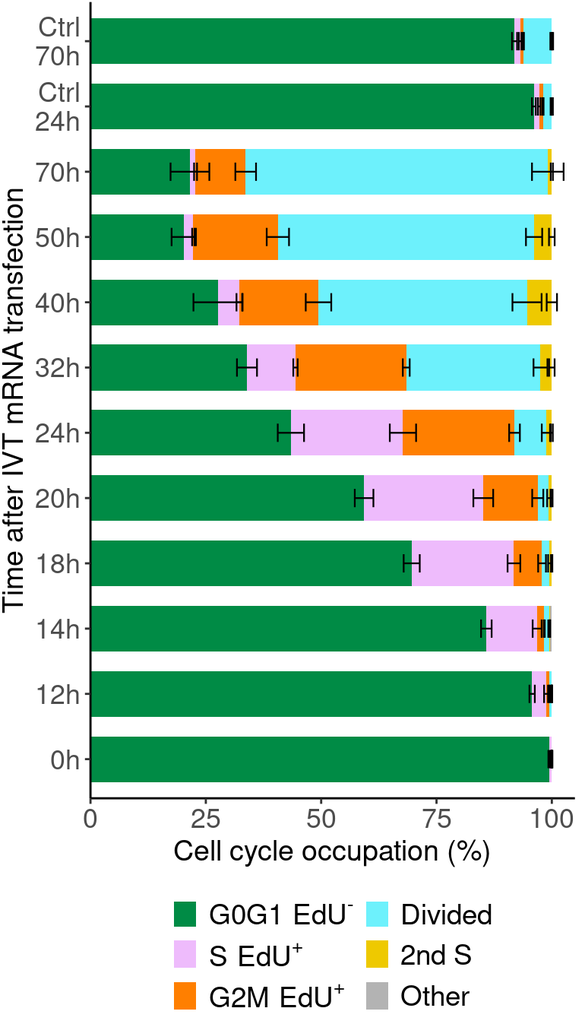

Proportion of beta cells in G0G1 EdU⁻, S EdU⁺, G2M EdU⁺, Divided and 2nd S phase (% by flow cytometry) at different time points after IVT mRNA transfection. Bars show means ± SEM (for individual phases; “Other” calculated as 100% − G0G1 EdU⁻ − S EdU⁺ − G2M EdU⁺ − Divided − 2nd S)

```r
p <- data_occup %>%
  tidyr::pivot_longer(
    cols = c(`G0G1 EdU-`, `S EdU+`, `G2M EdU+`, `DIVIDED`, `2ND S`, Other),
    names_to = "Phase",
    values_to = "Percent"
  ) %>%
  dplyr::mutate(
    Phase = factor(
      Phase,
      levels = c("Other", "2ND S", "DIVIDED", "G2M EdU+", "S EdU+", "G0G1 EdU-")
    )
  ) %>%
  dplyr::mutate(
    Percent = if_else(Percent < 0, 0, Percent)
  ) %>%
   dplyr::mutate(Time = factor(
    Time,
    levels = c(
      "0h",
      "12h",
      "14h",
      "18h",
      "20h",
      "24h",
      "32h",
      "40h",
      "50h",
      "70h",
      "Ctrl 24h",
      "Ctrl 70h"
    )
  )) %>%
  ggplot(
    aes(
      y = Time,
      x = Percent,
      fill = Phase
    )
  ) +
  geom_col(width = 0.7) +
  scale_fill_manual(
    values = c(
      "G0G1 EdU-" = "springgreen4",
      "S EdU+" = "#EEBBFC",
      "G2M EdU+" = "darkorange1",
      "DIVIDED" = "#6DF1FC",
      "2ND S" = "gold2",
      "Other" = "grey70"
    ),
    breaks = c("G0G1 EdU-", "S EdU+", "G2M EdU+", "DIVIDED", "2ND S", "Other"),
    labels = c(
  "G0G1 EdU-" = expression(G0G1~EdU^"-"),
  "S EdU+"    = expression(S~EdU^"+"),
  "G2M EdU+"  = expression(G2M~EdU^"+"),
  "DIVIDED"   = "Divided",
  "2ND S"     = "2nd S",
  "Other"     = "Other"
),
    name = NULL
  ) +
  labs(
    x = "Cell cycle occupation (%)",
    y = "Time after IVT mRNA transfection"
  ) +
  scale_x_continuous(
    limits = c(0, 105),
    expand = expansion(mult = c(0, 0), add = c(0, 0))
  ) +
  #coord_cartesian(xlim = c(0, 105), clip = "off") +
  scale_y_discrete(
    labels = function(x) {
      gsub(
        "(Ctrl|\\+RO|-RO)\\s*", "\\1\n", x
      )
    }
  ) +
  theme_classic() +
  theme(
    axis.line.y = element_line(color = "black"),
    axis.line.x = element_line(color = "black"),
    legend.position = "bottom",
    plot.margin = margin(t = 1, r = 5, b = 1, l = 1),
    axis.text.x = element_text(size = ax_text4),
    axis.text.y = element_text(size = ax_text4),
    axis.title.x = element_text(size = tit_text4),
    axis.title.y = element_text(size = tit_text4),
    legend.text = element_text(size = leg_text4),
    legend.key.size = unit(0.85, "lines")
  ) +
  guides(
    fill = guide_legend(nrow = 3)
  ) +
  geom_errorbarh(
    data = sem_df,
    aes(
      y = Time,
      xmin = xmid - sem,
      xmax = xmid + sem
    ),
    height = 0.28,
    inherit.aes = FALSE,
    linewidth = 0.4,
    color = "black"
  ) +
  scale_color_manual(
    guide = "none"
  )

p
```

**Open code**

```r
if (!file.exists("gitignore/figures/fig_24.pdf")) {
  ggsave(
    "gitignore/figures/fig_24.pdf",
    plot = p,
    width = figw4,
    height = 7.02,
    units = "in"
  )
}
```

# 22 RO G0G1 FC

## 22.1 Show Data

**Open code**

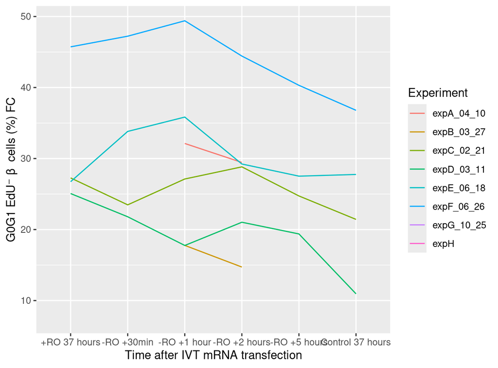

Mean proportion of G0G1-phase EdU⁻ β cells (% by flow cytometry) at different time points after IVT mRNA transfection and across individual experiments

```r
data_long %>% filter(grepl('RO_G0G1', Table)) %>%
  ggplot(
    aes(x = Time, y = Proportion, group = Experiment, color = Experiment)
    ) +
  geom_line() +
  scale_y_continuous(
    name = "G0G1 EdU⁻ β  cells (%) FC"
  ) +
  scale_x_discrete(name = "Time after IVT mRNA transfection")
## Warning: Removed 12 rows containing missing values or values outside the scale range
## (`geom_line()`).
```

$\Rightarrow$ variances appeared to differ slightly between groups

## 22.2 Models

### 22.2.1 Choose model

AIC/BIC

**Open code**

```r
model_NR <- glmmTMB::glmmTMB(
  Proportion ~ Time,
  data = data_long %>%
    filter(
      grepl('RO_G0G1', Table),
      !is.na(Proportion)
    ) %>%
    mutate(Time = factor(Time)),
  REML = FALSE
)

model_RI <- glmmTMB::glmmTMB(
  Proportion ~ Time + (1 | Experiment),
  data = data_long %>%
    filter(
      grepl('RO_G0G1', Table),
      !is.na(Proportion)
    ) %>%
    mutate(Time = factor(Time)),
  REML = FALSE
)

model_NR_difvar <- glmmTMB::glmmTMB(
  Proportion ~ Time,
  data = data_long %>%
    filter(
      grepl('RO_G0G1', Table),
      !is.na(Proportion)
    ) %>%
    mutate(Time = factor(Time)),
  REML = FALSE,
  dispformula = ~ 0 + Time
)

model_RI_difvar <- glmmTMB::glmmTMB(
  Proportion ~ Time + (1 | Experiment),
  data = data_long %>%
    filter(
      grepl('RO_G0G1', Table),
      !is.na(Proportion)
    ) %>%
    mutate(Time = factor(Time)),
  REML = FALSE,
  dispformula = ~ 0 + Time
)

kableExtra::kable(AIC(model_NR, model_RI, model_NR_difvar, model_RI_difvar))
```

|  | df | AIC |
| --- | --- | --- |
| model_NR | 7 | 248.2213 |
| model_RI | 8 | 192.3702 |
| model_NR_difvar | 12 | 257.2007 |
| model_RI_difvar | 13 | 194.8794 |

**Open code**

```r
kableExtra::kable(BIC(model_NR, model_RI, model_NR_difvar, model_RI_difvar))
```

|  | df | BIC |
| --- | --- | --- |
| model_NR | 7 | 258.4814 |
| model_RI | 8 | 204.0961 |
| model_NR_difvar | 12 | 274.7896 |
| model_RI_difvar | 13 | 213.9339 |

Diagnostics

**Open code**

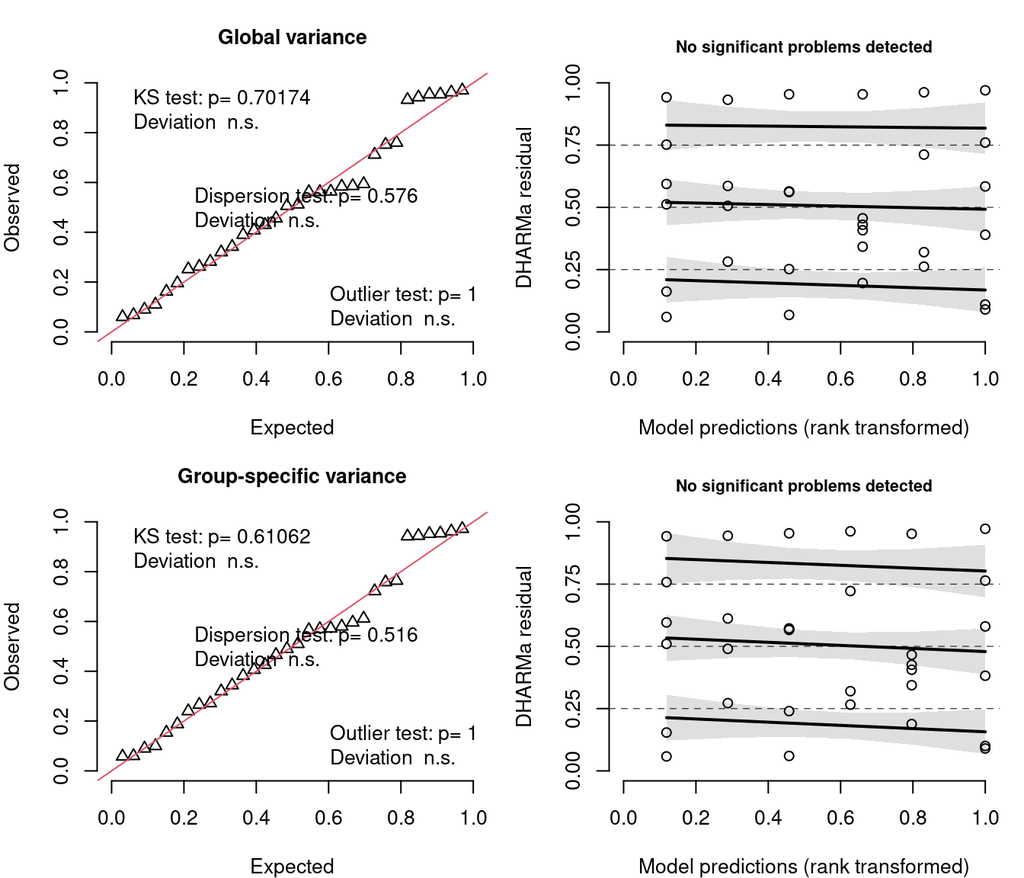

Diagnostic plots from DHARMa simulated residuals for models with and without group-specific residual variance. Top: random-intercept model with a single (global) residual variance. Bottom: random-intercept model allowing group-specific residual variance. Left: quantile–quantile plot comparing simulated residuals to the expected distribution. Right: residuals plotted against predicted values; black lines show the median (0.5) and lower/upper quartiles (0.25, 0.75) with shaded 95% simulation envelopes. Deviations from expected values suggest potential model misspecification

```r
set.seed(709)

res1 <- simulateResiduals(model_RI, n = 500)
res2 <- simulateResiduals(model_RI_difvar, n = 500)

op <- par(mfrow = c(2, 2), mar = c(4, 4, 3, 1))

plotQQunif(res1, main = "Global variance")
plotResiduals(res1, main = "")

plotQQunif(res2, main = "Group-specific variance")
plotResiduals(res2, main = "")
```

**Open code**

```r
par(op)
```

$\Rightarrow$ The random-intercept model provide the best fit. No reason to allow group-specific residual variance

### 22.2.2 Fit final model

**Open code**

```r
model_final <- glmmTMB::glmmTMB(
  Proportion ~ Time + (1 | Experiment),
  data = data_long %>%
    filter(
      grepl('RO_G0G1', Table),
      !is.na(Proportion)
    ),
  REML = TRUE
)
```

### 22.2.3 Results

**Open code**

```r
kableExtra::kable(car::Anova(model_final))
## Warning in printHypothesis(L, rhs, names(b)): one or more coefficients in the hypothesis include
##      arithmetic operators in their names;
##   the printed representation of the hypothesis will be omitted
```

|  | Chisq | Df | Pr(>Chisq) |
| --- | --- | --- | --- |
| Time | 36.35741 | 5 | 8e-07 |

**Open code**

```r
summary(model_final)
##  Family: gaussian  ( identity )
## Formula:          Proportion ~ Time + (1 | Experiment)
## Data: data_long %>% filter(grepl("RO_G0G1", Table), !is.na(Proportion))
##
##      AIC      BIC   logLik deviance df.resid
##    175.0    186.8    -79.5    159.0       30
##
## Random effects:
##
## Conditional model:
##  Groups     Name        Variance Std.Dev.
##  Experiment (Intercept) 98.302   9.915
##  Residual                8.179   2.860
## Number of obs: 32, groups:  Experiment, 6
##
## Dispersion estimate for gaussian family (sigma^2): 8.18
##
## Conditional model:
##                      Estimate Std. Error z value Pr(>|z|)
## (Intercept)           28.8033     4.2127   6.837 8.07e-12 ***
## Time-RO +30min         0.1452     1.8911   0.077   0.9388
## Time-RO +1 hour        1.1983     1.6512   0.726   0.4680
## Time-RO +2 hours      -0.8550     1.6512  -0.518   0.6046
## Time-RO +5 hours      -3.4523     1.8911  -1.826   0.0679 .
## TimeControl 37 hours  -7.4667     1.6512  -4.522 6.12e-06 ***
## ---
## Signif. codes:  0 '***' 0.001 '**' 0.01 '*' 0.05 '.' 0.1 ' ' 1

contrast <- con_tab(model_final)

kableExtra::kable(
  contrast,
  caption = "Estimated pairwise differences in the proportion of G0G1-phase EdU⁻ β cells (%; flow cytometry), obtained from a linear mixed-effects model with experiment as a random intercept and time as a categorical predictor. Columns: `contrast` (time points compared), `estimate` (mean difference in %), `CI` (Bonferroni-adjusted 95% confidence interval [lower, upper]), `SE` (standard error), `df` (degrees of freedom), `t.ratio` (test statistic), `p.value` (Bonferroni-adjusted p-value), and `stars` (significance code)"
)
```

Estimated pairwise differences in the proportion of G0G1-phase EdU⁻ β cells (%; flow cytometry), obtained from a linear mixed-effects model with experiment as a random intercept and time as a categorical predictor. Columns: `contrast` (time points compared), `estimate` (mean difference in %), `CI` (Bonferroni-adjusted 95% confidence interval [lower, upper]), `SE` (standard error), `df` (degrees of freedom), `t.ratio` (test statistic), `p.value` (Bonferroni-adjusted p-value), and `stars` (significance code)

| contrast | estimate | CI | SE | df | t.ratio | p.value | stars |
| --- | --- | --- | --- | --- | --- | --- | --- |
| (+RO 37 hours) - (-RO +30min) | -0.15 | [-6.18, 5.89] | 1.89 | 30 | -0.08 | 1.0000000 | ns |
| (+RO 37 hours) - (-RO +1 hour) | -1.20 | [-6.46, 4.07] | 1.65 | 30 | -0.73 | 1.0000000 | ns |
| (+RO 37 hours) - (-RO +2 hours) | 0.85 | [-4.41, 6.12] | 1.65 | 30 | 0.52 | 1.0000000 | ns |
| (+RO 37 hours) - (-RO +5 hours) | 3.45 | [-2.58, 9.48] | 1.89 | 30 | 1.83 | 1.0000000 | ns |
| (+RO 37 hours) - Control 37 hours | 7.47 | [2.20, 12.73] | 1.65 | 30 | 4.52 | 0.0013422 | ** |
| (-RO +30min) - (-RO +1 hour) | -1.05 | [-7.08, 4.98] | 1.89 | 30 | -0.56 | 1.0000000 | ns |
| (-RO +30min) - (-RO +2 hours) | 1.00 | [-5.03, 7.03] | 1.89 | 30 | 0.53 | 1.0000000 | ns |
| (-RO +30min) - (-RO +5 hours) | 3.60 | [-2.85, 10.05] | 2.02 | 30 | 1.78 | 1.0000000 | ns |
| (-RO +30min) - Control 37 hours | 7.61 | [1.58, 13.64] | 1.89 | 30 | 4.03 | 0.0053460 | ** |
| (-RO +1 hour) - (-RO +2 hours) | 2.05 | [-3.21, 7.32] | 1.65 | 30 | 1.24 | 1.0000000 | ns |
| (-RO +1 hour) - (-RO +5 hours) | 4.65 | [-1.38, 10.68] | 1.89 | 30 | 2.46 | 0.2986597 | ns |
| (-RO +1 hour) - Control 37 hours | 8.67 | [3.40, 13.93] | 1.65 | 30 | 5.25 | 0.0001735 | *** |
| (-RO +2 hours) - (-RO +5 hours) | 2.60 | [-3.43, 8.63] | 1.89 | 30 | 1.37 | 1.0000000 | ns |
| (-RO +2 hours) - Control 37 hours | 6.61 | [1.35, 11.88] | 1.65 | 30 | 4.00 | 0.0056610 | ** |
| (-RO +5 hours) - Control 37 hours | 4.01 | [-2.02, 10.04] | 1.89 | 30 | 2.12 | 0.6320900 | ns |

### 22.2.4 Visualisation

**Open code**

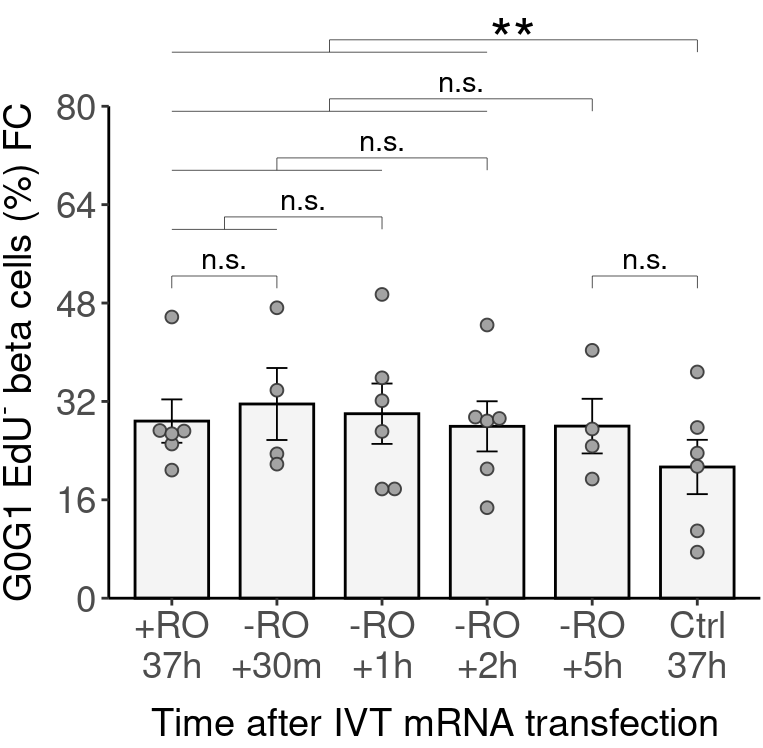

Proportion of G0G1-phase EdU⁻ beta cells (% by flow cytometry) at different time points after IVT mRNA transfection. Bars show means ± SEM. ***, P < 0.001; **, P < 0.01; *, P < 0.05(adjusted P-values by Bonferroni correction). Statistical significance was assessed with linear mixed-effects model, including experiment as a random effect and time as a categorical predictor

```r
scale <- 10/8

p <- data_long %>%
  filter(grepl("RO_G0G1", Table), !is.na(Proportion)) %>%
  mutate(
    Time = gsub("Control", "Ctrl", Time),
    Time = gsub(" hour[s]?", "h", Time),
    Time = gsub("min", "m", Time),
    #Time = gsub(" ", "", Time),
    Time = fct_inorder(Time)
  ) %>%
  ggplot(
    aes(x = Time, y = Proportion)
  ) +
  stat_summary(
    fun = 'mean',
    geom = 'col',
    fill = 'grey80', color = 'black',
    width = 0.7,
    alpha = 0.2
  ) +
  stat_summary(fun.data = mean_se, geom = "errorbar", width = 0.2, linewidth = 0.324) +
  scale_y_continuous(
    breaks = seq(0, 100/scale, 20/scale),
    name = expression("G0G1 EdU"^"-"~"beta cells (%) FC"),
    expand = expansion(mult = c(0, 0), add = c(0, 0))
  ) +
  coord_cartesian(ylim = c(0, 100/scale), clip = "off") +
  scale_x_discrete(name = "Time after IVT mRNA transfection",
  labels = function(x) gsub(
    "(Ctrl|\\+RO|-RO)\\s*", "\\1\n", x
  )
) +
  geom_beeswarm(
    cex = 2,
    fill = 'grey64',
    size = 1.92,
    shape = 21,
    color = rgb(0.2, 0.2, 0.2, 0.9),
    stroke = 0.5
  ) +
  theme_classic() +
  theme(
    plot.margin = margin(t = 40, r = 1, b = 1, l = 1),
    axis.text.x = element_text(size = ax_text3),
    axis.text.y = element_text(size = ax_text3),
    axis.title.x = element_text(size = tit_text3, margin = margin(t = mar3)),
    axis.title.y = element_text(size = tit_text3, margin = margin(r = 3))
  )

start <- 115/scale
tr <- 0
byp <- 12/scale

p <- add_starm(6, c(1:4), start - tr, '**', scal = scale); tr <-  tr + byp
p <- add_starm(5, c(1:4), start - tr, '<sup>n.s.</sup>', scal = scale); tr <-  tr + byp
p <- add_starm(4, c(1:3), start - tr, '<sup>n.s.</sup>', scal = scale); tr <-  tr + byp
p <- add_starm(3, c(1:2), start - tr, '<sup>n.s.</sup>', scal = scale); tr <-  tr + byp
p <- add_starm(5, 6, start - tr, '<sup>n.s.</sup>', scal = scale)
p <- add_starm(1, 2, start - tr, '<sup>n.s.</sup>', scal = scale)

p
```

**Open code**

```r
if (!file.exists("gitignore/figures/fig_19.pdf")) {
  ggsave("gitignore/figures/fig_19.pdf", plot = p, width = figw5, height = figh5, units = "in")
  ggsave("gitignore/figures/fig_19.svg", plot = p, width = figw5, height = figh5, units = "in")
  }
```

### 22.2.5 Summary statistics over timpoints

**Open code**

```r
kableExtra::kable(
  data_long %>%
    dplyr::filter(grepl("RO_G0G1", Table)) %>%
    tidyr::drop_na(Proportion) %>%
    dplyr::group_by(Time) %>%
    dplyr::summarise(
      mean = mean(Proportion),
      median = quantile(Proportion, probs = 0.5),
      SD = sd(Proportion),
      SEM = sem(Proportion)
    ),
  caption = "Summary statistics for the proportion of G0G1-phase EdU⁻ beta cells (% by flow cytometry) at different time points after IVT mRNA transfection. Mean, median, SD, and SEM are shown; SD, standard deviation; SEM, standard error of the mean"
)
```

Summary statistics for the proportion of G0G1-phase EdU⁻ beta cells (% by flow cytometry) at different time points after IVT mRNA transfection. Mean, median, SD, and SEM are shown; SD, standard deviation; SEM, standard error of the mean

| Time | mean | median | SD | SEM |
| --- | --- | --- | --- | --- |
| +RO 37 hours | 28.80333 | 26.960 | 8.640226 | 3.527357 |
| -RO +30min | 31.58250 | 28.650 | 11.707526 | 5.853763 |
| -RO +1 hour | 30.00167 | 29.620 | 12.022020 | 4.907969 |
| -RO +2 hours | 27.94833 | 29.030 | 9.991721 | 4.079103 |
| -RO +5 hours | 27.98500 | 26.125 | 8.883747 | 4.441874 |
| Control 37 hours | 21.33667 | 22.515 | 10.814889 | 4.415160 |

# 23 RO_S_EdU FC

## 23.1 Show Data

**Open code**

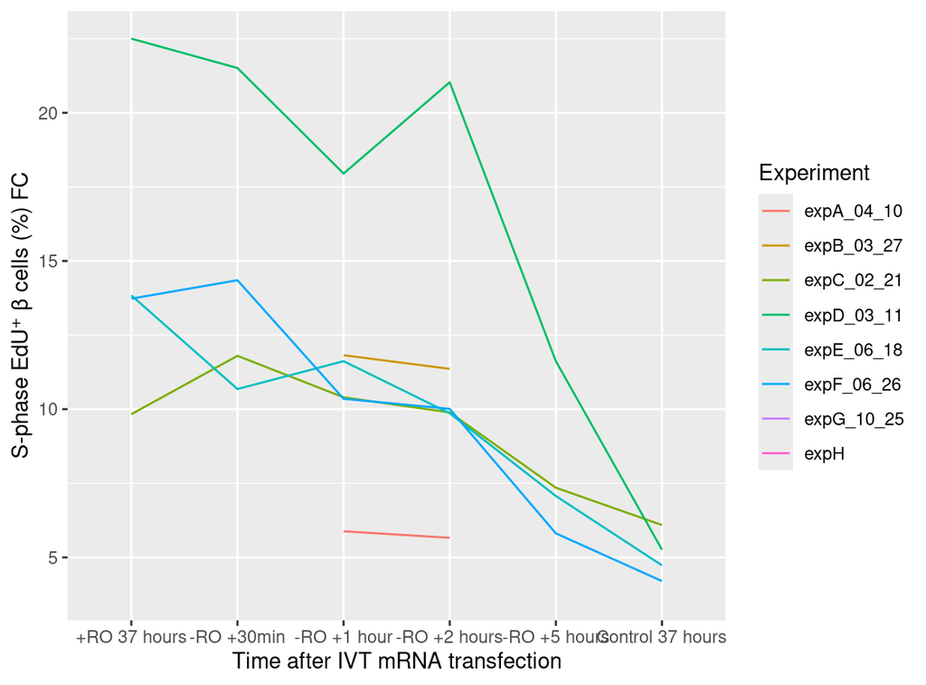

Mean proportion of S-phase EdU⁺ β cells (% by flow cytometry) at different time points after IVT mRNA transfection and across individual experiments

```r
data_long %>% filter(grepl('RO_S', Table)) %>%
  ggplot(
    aes(x = Time, y = Proportion, group = Experiment, color = Experiment)
    ) +
  geom_line() +
  scale_y_continuous(
    name = "S-phase EdU⁺ β cells (%) FC"
  ) +
  scale_x_discrete(name = "Time after IVT mRNA transfection")
## Warning: Removed 12 rows containing missing values or values outside the scale range
## (`geom_line()`).
```

$\Rightarrow$ variances appeared to differ slightly between groups

## 23.2 Models

### 23.2.1 Choose model

AIC/BIC

**Open code**

```r
model_NR <- glmmTMB::glmmTMB(
  Proportion ~ Time,
  data = data_long %>%
    filter(
      grepl('RO_S', Table),
      !is.na(Proportion)
    ) %>%
    mutate(Time = factor(Time)),
  REML = FALSE
)

model_RI <- glmmTMB::glmmTMB(
  Proportion ~ Time + (1 | Experiment),
  data = data_long %>%
    filter(
      grepl('RO_S', Table),
      !is.na(Proportion)
    ) %>%
    mutate(Time = factor(Time)),
  REML = FALSE
)

model_NR_difvar <- glmmTMB::glmmTMB(
  Proportion ~ Time,
  data = data_long %>%
    filter(
      grepl('RO_S', Table),
      !is.na(Proportion)
    ) %>%
    mutate(Time = factor(Time)),
  REML = FALSE,
  dispformula = ~ 0 + Time
)

model_RI_difvar <- glmmTMB::glmmTMB(
  Proportion ~ Time + (1 | Experiment),
  data = data_long %>%
    filter(
      grepl('RO_S', Table),
      !is.na(Proportion)
    ) %>%
    mutate(Time = factor(Time)),
  REML = FALSE,
  dispformula = ~ 0 + Time
)

kableExtra::kable(AIC(model_NR, model_RI, model_NR_difvar, model_RI_difvar))
```

|  | df | AIC |
| --- | --- | --- |
| model_NR | 7 | 189.5989 |
| model_RI | 8 | 170.1704 |
| model_NR_difvar | 12 | 182.0185 |
| model_RI_difvar | 13 | 168.2787 |

**Open code**

```r
kableExtra::kable(BIC(model_NR, model_RI, model_NR_difvar, model_RI_difvar))
```

|  | df | BIC |
| --- | --- | --- |
| model_NR | 7 | 199.8591 |
| model_RI | 8 | 181.8963 |
| model_NR_difvar | 12 | 199.6073 |
| model_RI_difvar | 13 | 187.3333 |

Diagnostics

**Open code**

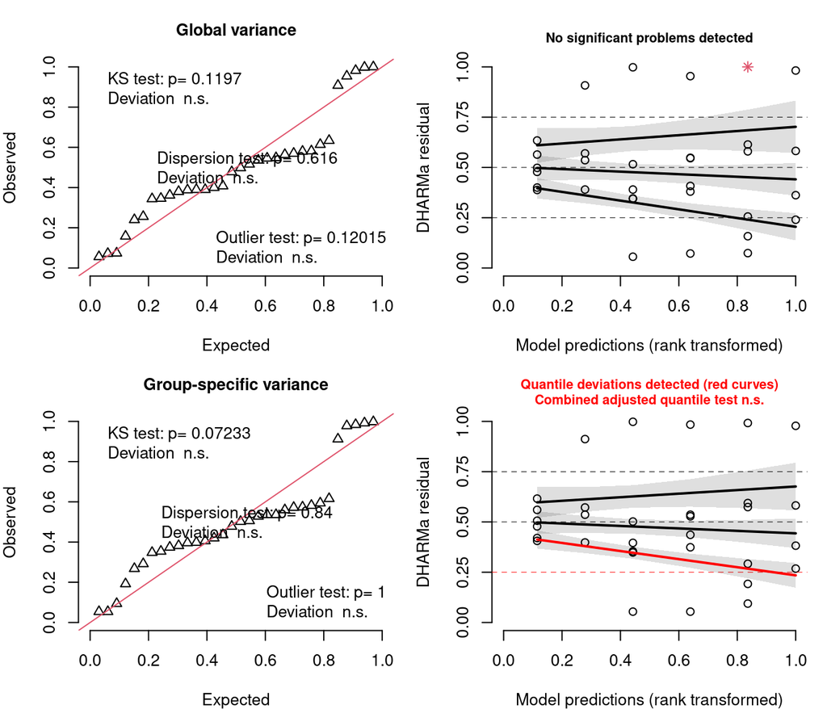

Diagnostic plots from DHARMa simulated residuals for models with and without group-specific residual variance. Top: random-intercept model with a single (global) residual variance. Bottom: random-intercept model allowing group-specific residual variance. Left: quantile–quantile plot comparing simulated residuals to the expected distribution. Right: residuals plotted against predicted values; black lines show the median (0.5) and lower/upper quartiles (0.25, 0.75) with shaded 95% simulation envelopes. Deviations from expected values suggest potential model misspecification

```r
set.seed(709)

res1 <- simulateResiduals(model_RI, n = 500)
res2 <- simulateResiduals(model_RI_difvar, n = 500)

op <- par(mfrow = c(2, 2), mar = c(4, 4, 3, 1))

plotQQunif(res1, main = "Global variance")
plotResiduals(res1, main = "")

plotQQunif(res2, main = "Group-specific variance")
plotResiduals(res2, main = "")
```

**Open code**

```r
par(op)
```

### 23.2.2 Fit final model

**Open code**

```r
model_final <- glmmTMB::glmmTMB(
  Proportion ~ Time + (1 | Experiment),
  data = data_long %>%
    filter(
      grepl('RO_S', Table),
      !is.na(Proportion)
    ),
  REML = TRUE
)
```

### 23.2.3 Results

**Open code**

```r
kableExtra::kable(car::Anova(model_final))
## Warning in printHypothesis(L, rhs, names(b)): one or more coefficients in the hypothesis include
##      arithmetic operators in their names;
##   the printed representation of the hypothesis will be omitted
```

|  | Chisq | Df | Pr(>Chisq) |
| --- | --- | --- | --- |
| Time | 55.72249 | 5 | 0 |

**Open code**

```r
summary(model_final)
##  Family: gaussian  ( identity )
## Formula:          Proportion ~ Time + (1 | Experiment)
## Data: data_long %>% filter(grepl("RO_S", Table), !is.na(Proportion))
##
##      AIC      BIC   logLik deviance df.resid
##    156.8    168.5    -70.4    140.8       30
##
## Random effects:
##
## Conditional model:
##  Groups     Name        Variance Std.Dev.
##  Experiment (Intercept) 11.849   3.442
##  Residual                5.582   2.363
## Number of obs: 32, groups:  Experiment, 6
##
## Dispersion estimate for gaussian family (sigma^2): 5.58
##
## Conditional model:
##                      Estimate Std. Error z value Pr(>|z|)
## (Intercept)           12.6700     1.7044   7.434 1.06e-13 ***
## Time-RO +30min         0.7581     1.5616   0.485 0.627336
## Time-RO +1 hour       -1.3333     1.3640  -0.978 0.328321
## Time-RO +2 hours      -1.3683     1.3640  -1.003 0.315784
## Time-RO +5 hours      -5.8644     1.5616  -3.755 0.000173 ***
## TimeControl 37 hours  -7.8283     1.3640  -5.739 9.52e-09 ***
## ---
## Signif. codes:  0 '***' 0.001 '**' 0.01 '*' 0.05 '.' 0.1 ' ' 1

contrast <- con_tab(model_final)

kableExtra::kable(
  contrast,
  caption = "Estimated pairwise differences in the proportion of S-phase EdU⁺ β cells (%; flow cytometry), obtained from a linear mixed-effects model with experiment as a random intercept and time as a categorical predictor. Columns: `contrast` (time points compared), `estimate` (mean difference in %), `CI` (Bonferroni-adjusted 95% confidence interval [lower, upper]), `SE` (standard error), `df` (degrees of freedom), `t.ratio` (test statistic), `p.value` (Bonferroni-adjusted p-value), and `stars` (significance code)"
)
```

Estimated pairwise differences in the proportion of S-phase EdU⁺ β cells (%; flow cytometry), obtained from a linear mixed-effects model with experiment as a random intercept and time as a categorical predictor. Columns: `contrast` (time points compared), `estimate` (mean difference in %), `CI` (Bonferroni-adjusted 95% confidence interval [lower, upper]), `SE` (standard error), `df` (degrees of freedom), `t.ratio` (test statistic), `p.value` (Bonferroni-adjusted p-value), and `stars` (significance code)

| contrast | estimate | CI | SE | df | t.ratio | p.value | stars |
| --- | --- | --- | --- | --- | --- | --- | --- |
| (+RO 37 hours) - (-RO +30min) | -0.76 | [-5.74, 4.22] | 1.56 | 30 | -0.49 | 1.0000000 | ns |
| (+RO 37 hours) - (-RO +1 hour) | 1.33 | [-3.02, 5.68] | 1.36 | 30 | 0.98 | 1.0000000 | ns |
| (+RO 37 hours) - (-RO +2 hours) | 1.37 | [-2.98, 5.72] | 1.36 | 30 | 1.00 | 1.0000000 | ns |
| (+RO 37 hours) - (-RO +5 hours) | 5.86 | [0.88, 10.84] | 1.56 | 30 | 3.76 | 0.0111650 | * |
| (+RO 37 hours) - Control 37 hours | 7.83 | [3.48, 12.18] | 1.36 | 30 | 5.74 | 0.0000434 | *** |
| (-RO +30min) - (-RO +1 hour) | 2.09 | [-2.89, 7.07] | 1.56 | 30 | 1.34 | 1.0000000 | ns |
| (-RO +30min) - (-RO +2 hours) | 2.13 | [-2.85, 7.11] | 1.56 | 30 | 1.36 | 1.0000000 | ns |
| (-RO +30min) - (-RO +5 hours) | 6.62 | [1.30, 11.95] | 1.67 | 30 | 3.96 | 0.0063194 | ** |
| (-RO +30min) - Control 37 hours | 8.59 | [3.61, 13.57] | 1.56 | 30 | 5.50 | 0.0000855 | *** |
| (-RO +1 hour) - (-RO +2 hours) | 0.03 | [-4.31, 4.38] | 1.36 | 30 | 0.03 | 1.0000000 | ns |
| (-RO +1 hour) - (-RO +5 hours) | 4.53 | [-0.45, 9.51] | 1.56 | 30 | 2.90 | 0.1033929 | ns |
| (-RO +1 hour) - Control 37 hours | 6.50 | [2.15, 10.84] | 1.36 | 30 | 4.76 | 0.0006845 | *** |
| (-RO +2 hours) - (-RO +5 hours) | 4.50 | [-0.48, 9.48] | 1.56 | 30 | 2.88 | 0.1092980 | ns |
| (-RO +2 hours) - Control 37 hours | 6.46 | [2.11, 10.81] | 1.36 | 30 | 4.74 | 0.0007358 | *** |
| (-RO +5 hours) - Control 37 hours | 1.96 | [-3.02, 6.94] | 1.56 | 30 | 1.26 | 1.0000000 | ns |

### 23.2.4 Visualisation

**Open code**

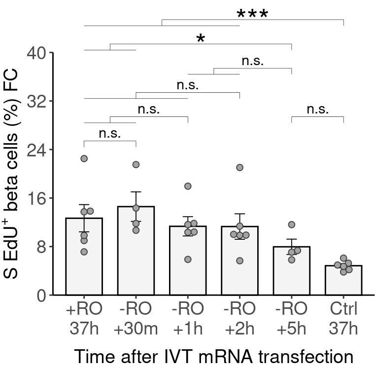

Proportion of S-phase EdU⁺ beta cells (% by flow cytometry) at different time points after IVT mRNA transfection. Bars show means ± SEM. ***, P < 0.001; **, P < 0.01; *, P < 0.05(adjusted P-values by Bonferroni correction). Statistical significance was assessed with linear mixed-effects model, including experiment as a random effect and time as a categorical predictor

```r
scale <- 10/4

p <- data_long %>%
  filter(grepl("RO_S", Table), !is.na(Proportion)) %>%
  mutate(
    Time = gsub("Control", "Ctrl", Time),
    Time = gsub(" hour[s]?", "h", Time),
    Time = gsub("min", "m", Time),
    #Time = gsub(" ", "", Time),
    Time = fct_inorder(Time)
  ) %>%
  ggplot(
    aes(x = Time, y = Proportion)
  ) +
  stat_summary(
    fun = 'mean',
    geom = 'col',
    fill = 'grey80', color = 'black',
    width = 0.7,
    alpha = 0.2
  ) +
  stat_summary(fun.data = mean_se, geom = "errorbar", width = 0.2, linewidth = 0.324) +
  scale_y_continuous(
    breaks = seq(0, 100/scale, 20/scale),
    name = expression("S EdU"^"+"~"beta cells (%) FC"),
    expand = expansion(mult = c(0, 0), add = c(0, 0))
  ) +
  coord_cartesian(ylim = c(0, 100/scale), clip = "off") +
  scale_x_discrete(name = "Time after IVT mRNA transfection",
  labels = function(x) gsub(
    "(Ctrl|\\+RO|-RO)\\s*", "\\1\n", x
  )
) +
  geom_beeswarm(
    cex = 2,
    fill = 'grey64',
    size = 1.92,
    shape = 21,
    color = rgb(0.2, 0.2, 0.2, 0.9),
    stroke = 0.5
  ) +
  theme_classic() +
  theme(
    plot.margin = margin(t = 40, r = 1, b = 1, l = 1),
    axis.text.x = element_text(size = ax_text3),
    axis.text.y = element_text(size = ax_text3),
    axis.title.x = element_text(size = tit_text3, margin = margin(t = mar3)),
    axis.title.y = element_text(size = tit_text3, margin = margin(r = 1))
  )

start <- 115/scale
tr <- 0
byp <- 10/scale

p <- add_starm(6, c(1:4), start - tr, '***', scal = scale); tr <-  tr + byp
p <- add_starm(5, c(1:2), start - tr, '*', scal = scale); tr <-  tr + byp
p <- add_starm(5, c(3:4), start - tr, '<sup>n.s.</sup>', scal = scale); tr <-  tr + byp
p <- add_starm(4, c(1:3), start - tr, '<sup>n.s.</sup>', scal = scale); tr <-  tr + byp
p <- add_starm(3, c(1:2), start - tr, '<sup>n.s.</sup>', scal = scale)
p <- add_starm(5, 6, start - tr, '<sup>n.s.</sup>', scal = scale); tr <-  tr + byp
p <- add_starm(1, 2, start - tr, '<sup>n.s.</sup>', scal = scale)

p
```

**Open code**

```r
if (!file.exists("gitignore/figures/fig_20.pdf")) {
  ggsave("gitignore/figures/fig_20.pdf", plot = p, width = figw5, height = figh5, units = "in")
  ggsave("gitignore/figures/fig_20.svg", plot = p, width = figw5, height = figh5, units = "in")
  }
```

### 23.2.5 Summary statistics over timpoints

**Open code**

```r
kableExtra::kable(
  data_long %>%
    dplyr::filter(grepl("RO_S", Table)) %>%
    tidyr::drop_na(Proportion) %>%
    dplyr::group_by(Time) %>%
    dplyr::summarise(
      mean = mean(Proportion),
      median = quantile(Proportion, probs = 0.5),
      SD = sd(Proportion),
      SEM = sem(Proportion)
    ),
  caption = "Summary statistics for the proportion of S-phase EdU⁺ beta cells (% by flow cytometry) at different time points after IVT mRNA transfection. Mean, median, SD, and SEM are shown; SD, standard deviation; SEM, standard error of the mean"
)
```

Summary statistics for the proportion of S-phase EdU⁺ beta cells (% by flow cytometry) at different time points after IVT mRNA transfection. Mean, median, SD, and SEM are shown; SD, standard deviation; SEM, standard error of the mean

| Time | mean | median | SD | SEM |
| --- | --- | --- | --- | --- |
| +RO 37 hours | 12.670000 | 11.780 | 5.5031082 | 2.2466345 |
| -RO +30min | 14.585000 | 13.075 | 4.8653914 | 2.4326957 |
| -RO +1 hour | 11.336667 | 11.010 | 3.8904019 | 1.5882499 |
| -RO +2 hours | 11.301667 | 9.950 | 5.1422152 | 2.0993005 |
| -RO +5 hours | 7.962500 | 7.210 | 2.5286541 | 1.2643271 |
| Control 37 hours | 4.841667 | 4.845 | 0.8044729 | 0.3284247 |

# 24 RO G2M FC

## 24.1 Show Data

**Open code**

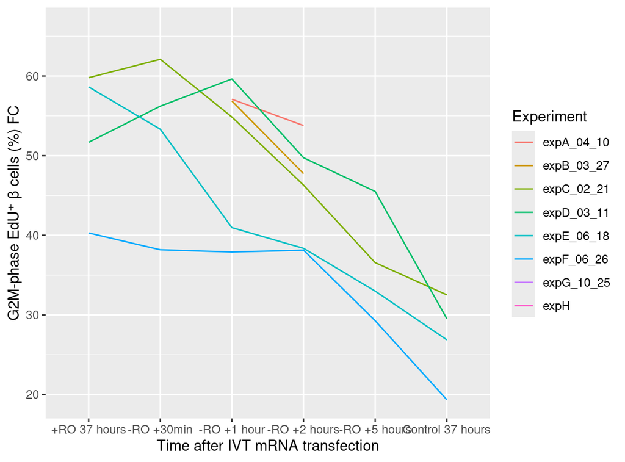

Mean proportion of G2M-phase EdU⁺ β cells (% by flow cytometry) at different time points after IVT mRNA transfection and across individual experiments

```r
data_long %>% filter(grepl('RO_G2M', Table)) %>%
  ggplot(
    aes(x = Time, y = Proportion, group = Experiment, color = Experiment)
    ) +
  geom_line() +
  scale_y_continuous(
    name = "G2M-phase EdU⁺ β cells (%) FC"
  ) +
  scale_x_discrete(name = "Time after IVT mRNA transfection")
## Warning: Removed 12 rows containing missing values or values outside the scale range
## (`geom_line()`).
```

$\Rightarrow$ variances appeared to differ slightly between groups

## 24.2 Models

### 24.2.1 Choose model

AIC/BIC

**Open code**

```r
model_NR <- glmmTMB::glmmTMB(
  Proportion ~ Time,
  data = data_long %>%
    filter(
      grepl('RO_G2M', Table),
      !is.na(Proportion)
    ) %>%
    mutate(Time = factor(Time)),
  REML = FALSE
)

model_RI <- glmmTMB::glmmTMB(
  Proportion ~ Time + (1 | Experiment),
  data = data_long %>%
    filter(
      grepl('RO_G2M', Table),
      !is.na(Proportion)
    ) %>%
    mutate(Time = factor(Time)),
  REML = FALSE
)

model_NR_difvar <- glmmTMB::glmmTMB(
  Proportion ~ Time,
  data = data_long %>%
    filter(
      grepl('RO_G2M', Table),
      !is.na(Proportion)
    ) %>%
    mutate(Time = factor(Time)),
  REML = FALSE,
  dispformula = ~ 0 + Time
)

model_RI_difvar <- glmmTMB::glmmTMB(
  Proportion ~ Time + (1 | Experiment),
  data = data_long %>%
    filter(
      grepl('RO_G2M', Table),
      !is.na(Proportion)
    ) %>%
    mutate(Time = factor(Time)),
  REML = FALSE,
  dispformula = ~ 0 + Time
)

kableExtra::kable(AIC(model_NR, model_RI, model_NR_difvar, model_RI_difvar))
```

|  | df | AIC |
| --- | --- | --- |
| model_NR | 7 | 233.1017 |
| model_RI | 8 | 214.1621 |
| model_NR_difvar | 12 | 240.6457 |
| model_RI_difvar | 13 | 220.4190 |

**Open code**

```r
kableExtra::kable(BIC(model_NR, model_RI, model_NR_difvar, model_RI_difvar))
```

|  | df | BIC |
| --- | --- | --- |
| model_NR | 7 | 243.3619 |
| model_RI | 8 | 225.8880 |
| model_NR_difvar | 12 | 258.2346 |
| model_RI_difvar | 13 | 239.4736 |

Diagnostics

**Open code**

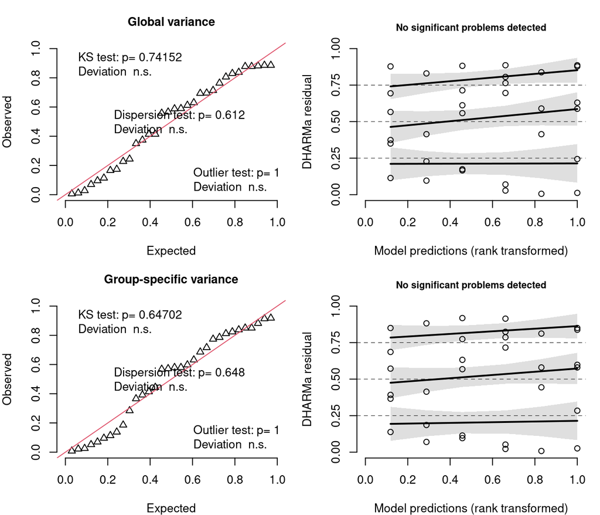

Diagnostic plots from DHARMa simulated residuals for models with and without group-specific residual variance. Top: random-intercept model with a single (global) residual variance. Bottom: random-intercept model allowing group-specific residual variance. Left: quantile–quantile plot comparing simulated residuals to the expected distribution. Right: residuals plotted against predicted values; black lines show the median (0.5) and lower/upper quartiles (0.25, 0.75) with shaded 95% simulation envelopes. Deviations from expected values suggest potential model misspecification

```r
set.seed(709)

res1 <- simulateResiduals(model_RI, n = 500)
res2 <- simulateResiduals(model_RI_difvar, n = 500)

op <- par(mfrow = c(2, 2), mar = c(4, 4, 3, 1))

plotQQunif(res1, main = "Global variance")
plotResiduals(res1, main = "")

plotQQunif(res2, main = "Group-specific variance")
plotResiduals(res2, main = "")
```

**Open code**

```r
par(op)
```

$\Rightarrow$ The random-intercept model provide the best fit. No reason to allow group-specific residual variance

### 24.2.2 Fit final model

**Open code**

```r
model_final <- glmmTMB::glmmTMB(
  Proportion ~ Time + (1 | Experiment),
  data = data_long %>%
    filter(
      grepl('RO_G2M', Table),
      !is.na(Proportion)
    ),
  REML = TRUE
)
```

### 24.2.3 Results

**Open code**

```r
kableExtra::kable(car::Anova(model_final))
## Warning in printHypothesis(L, rhs, names(b)): one or more coefficients in the hypothesis include
##      arithmetic operators in their names;
##   the printed representation of the hypothesis will be omitted
```

|  | Chisq | Df | Pr(>Chisq) |
| --- | --- | --- | --- |
| Time | 144.7592 | 5 | 0 |

**Open code**

```r
summary(model_final)
##  Family: gaussian  ( identity )
## Formula:          Proportion ~ Time + (1 | Experiment)
## Data: data_long %>% filter(grepl("RO_G2M", Table), !is.na(Proportion))
##
##      AIC      BIC   logLik deviance df.resid
##    192.5    204.3    -88.3    176.5       30
##
## Random effects:
##
## Conditional model:
##  Groups     Name        Variance Std.Dev.
##  Experiment (Intercept) 45.46    6.742
##  Residual               22.21    4.713
## Number of obs: 32, groups:  Experiment, 6
##
## Dispersion estimate for gaussian family (sigma^2): 22.2
##
## Conditional model:
##                      Estimate Std. Error z value Pr(>|z|)
## (Intercept)            56.947      3.358  16.958  < 2e-16 ***
## Time-RO +30min         -1.950      3.116  -0.626   0.5315
## Time-RO +1 hour        -5.733      2.721  -2.107   0.0351 *
## Time-RO +2 hours      -11.272      2.721  -4.143 3.43e-05 ***
## Time-RO +5 hours      -18.322      3.116  -5.879 4.12e-09 ***
## TimeControl 37 hours  -28.228      2.721 -10.375  < 2e-16 ***
## ---
## Signif. codes:  0 '***' 0.001 '**' 0.01 '*' 0.05 '.' 0.1 ' ' 1

contrast <- con_tab(model_final)

kableExtra::kable(
  contrast,
  caption = "Estimated pairwise differences in the proportion of G2M-phase EdU⁺ β cells (%; flow cytometry), obtained from a linear mixed-effects model with experiment as a random intercept and time as a categorical predictor. Columns: `contrast` (time points compared), `estimate` (mean difference in %), `CI` (Bonferroni-adjusted 95% confidence interval [lower, upper]), `SE` (standard error), `df` (degrees of freedom), `t.ratio` (test statistic), `p.value` (Bonferroni-adjusted p-value), and `stars` (significance code)"
)
```

Estimated pairwise differences in the proportion of G2M-phase EdU⁺ β cells (%; flow cytometry), obtained from a linear mixed-effects model with experiment as a random intercept and time as a categorical predictor. Columns: `contrast` (time points compared), `estimate` (mean difference in %), `CI` (Bonferroni-adjusted 95% confidence interval [lower, upper]), `SE` (standard error), `df` (degrees of freedom), `t.ratio` (test statistic), `p.value` (Bonferroni-adjusted p-value), and `stars` (significance code)

| contrast | estimate | CI | SE | df | t.ratio | p.value | stars |
| --- | --- | --- | --- | --- | --- | --- | --- |
| (+RO 37 hours) - (-RO +30min) | 1.95 | [-7.99, 11.89] | 3.12 | 30 | 0.63 | 1.0000000 | ns |
| (+RO 37 hours) - (-RO +1 hour) | 5.73 | [-2.94, 14.41] | 2.72 | 30 | 2.11 | 0.6535157 | ns |
| (+RO 37 hours) - (-RO +2 hours) | 11.27 | [2.60, 19.95] | 2.72 | 30 | 4.14 | 0.0038639 | ** |
| (+RO 37 hours) - (-RO +5 hours) | 18.32 | [8.38, 28.26] | 3.12 | 30 | 5.88 | 0.0000293 | *** |
| (+RO 37 hours) - Control 37 hours | 28.23 | [19.55, 36.90] | 2.72 | 30 | 10.37 | 0.0000000 | *** |
| (-RO +30min) - (-RO +1 hour) | 3.78 | [-6.15, 13.72] | 3.12 | 30 | 1.21 | 1.0000000 | ns |
| (-RO +30min) - (-RO +2 hours) | 9.32 | [-0.62, 19.26] | 3.12 | 30 | 2.99 | 0.0826406 | ns |
| (-RO +30min) - (-RO +5 hours) | 16.37 | [5.75, 27.00] | 3.33 | 30 | 4.91 | 0.0004464 | *** |
| (-RO +30min) - Control 37 hours | 26.28 | [16.34, 36.22] | 3.12 | 30 | 8.43 | 0.0000000 | *** |
| (-RO +1 hour) - (-RO +2 hours) | 5.54 | [-3.14, 14.21] | 2.72 | 30 | 2.04 | 0.7607137 | ns |
| (-RO +1 hour) - (-RO +5 hours) | 12.59 | [2.65, 22.53] | 3.12 | 30 | 4.04 | 0.0051362 | ** |
| (-RO +1 hour) - Control 37 hours | 22.49 | [13.82, 31.17] | 2.72 | 30 | 8.27 | 0.0000000 | *** |
| (-RO +2 hours) - (-RO +5 hours) | 7.05 | [-2.89, 16.99] | 3.12 | 30 | 2.26 | 0.4660827 | ns |
| (-RO +2 hours) - Control 37 hours | 16.96 | [8.28, 25.63] | 2.72 | 30 | 6.23 | 0.0000110 | *** |
| (-RO +5 hours) - Control 37 hours | 9.91 | [-0.03, 19.84] | 3.12 | 30 | 3.18 | 0.0513122 | ns |

### 24.2.4 Visualisation

**Open code**

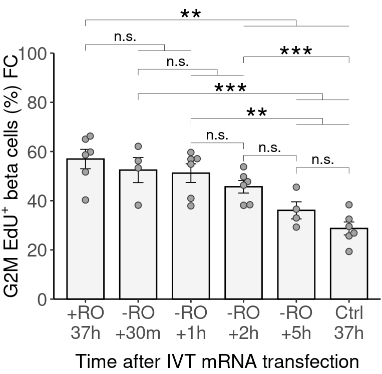

Proportion of G2M-phase EdU⁺ beta cells (% by flow cytometry) at different time points after IVT mRNA transfection. Bars show means ± SEM. ***, P < 0.001; **, P < 0.01; *, P < 0.05(adjusted P-values by Bonferroni correction). Statistical significance was assessed with linear mixed-effects model, including experiment as a random effect and time as a categorical predictor

```r
scale <- 1

p <- data_long %>%
  filter(grepl("RO_G2M", Table), !is.na(Proportion)) %>%
  mutate(
    Time = gsub("Control", "Ctrl", Time),
    Time = gsub(" hour[s]?", "h", Time),
    Time = gsub("min", "m", Time),
    #Time = gsub(" ", "", Time),
    Time = fct_inorder(Time)
  ) %>%
  ggplot(
    aes(x = Time, y = Proportion)
  ) +
  stat_summary(
    fun = 'mean',
    geom = 'col',
    fill = 'grey80', color = 'black',
    width = 0.7,
    alpha = 0.2
  ) +
  stat_summary(fun.data = mean_se, geom = "errorbar", width = 0.2, linewidth = 0.324) +
  scale_y_continuous(
    breaks = seq(0, 100/scale, 20/scale),
    name = expression("G2M EdU"^"+"~"beta cells (%) FC"),
    expand = expansion(mult = c(0, 0), add = c(0, 0))
  ) +
  coord_cartesian(ylim = c(0, 100/scale), clip = "off") +
  scale_x_discrete(name = "Time after IVT mRNA transfection",
  labels = function(x) gsub(
    "(Ctrl|\\+RO|-RO)\\s*", "\\1\n", x
  )
) +
  geom_beeswarm(
    cex = 2,
    fill = 'grey64',
    size = 1.92,
    shape = 21,
    color = rgb(0.2, 0.2, 0.2, 0.9),
    stroke = 0.5
  ) +
  theme_classic() +
  theme(
    plot.margin = margin(t = 40, r = 1, b = 1, l = 1),
    axis.text.x = element_text(size = ax_text3),
    axis.text.y = element_text(size = ax_text3),
    axis.title.x = element_text(size = tit_text3, margin = margin(t = mar3)),
    axis.title.y = element_text(size = tit_text3, margin = margin(r = mar1b3))
  )

start <- 115/scale
tr <- 0
byp <- 10/scale

p <- add_starm(1, c(4:6), start - tr, '**', scal = scale); tr <-  tr + byp
p <- add_starm(1, c(2:3), start - tr, '<sup>n.s.</sup>', scal = scale); tr <-  tr + byp*0.5
p <- add_starm(4, 6, start - tr, '***', scal = scale); tr <-  tr + byp*0.5
p <- add_starm(2, c(3:4), start - tr, '<sup>n.s.</sup>', scal = scale); tr <-  tr + byp
p <- add_starm(2, c(5:6), start - tr, '***', scal = scale); tr <-  tr + byp
p <- add_starm(3, c(5:6), start - tr, '**', scal = scale); tr <-  tr + byp
p <- add_starm(3, 4, start - tr, '<sup>n.s.</sup>', scal = scale); tr <-  tr + byp*0.5
p <- add_starm(4, 5, start - tr, '<sup>n.s.</sup>', scal = scale); tr <-  tr + byp*0.5
p <- add_starm(5, 6, start - tr, '<sup>n.s.</sup>', scal = scale)
p
```

**Open code**

```r
if (!file.exists("gitignore/figures/fig_21.pdf")) {
  ggsave("gitignore/figures/fig_21.pdf", plot = p, width = figw5, height = figh5, units = "in")
  ggsave("gitignore/figures/fig_21.svg", plot = p, width = figw5, height = figh5, units = "in")
  }
```

### 24.2.5 Summary statistics over timpoints

**Open code**

```r
kableExtra::kable(
  data_long %>%
    dplyr::filter(grepl("RO_G2M", Table)) %>%
    tidyr::drop_na(Proportion) %>%
    dplyr::group_by(Time) %>%
    dplyr::summarise(
      mean = mean(Proportion),
      median = quantile(Proportion, probs = 0.5),
      SD = sd(Proportion),
      SEM = sem(Proportion)
    ),
  caption = "Summary statistics for the proportion of G2M-phase EdU⁺ beta cells (% by flow cytometry) at different time points after IVT mRNA transfection. Mean, median, SD, and SEM are shown; SD, standard deviation; SEM, standard error of the mean"
)
```

Summary statistics for the proportion of G2M-phase EdU⁺ beta cells (% by flow cytometry) at different time points after IVT mRNA transfection. Mean, median, SD, and SEM are shown; SD, standard deviation; SEM, standard error of the mean

| Time | mean | median | SD | SEM |
| --- | --- | --- | --- | --- |
| +RO 37 hours | 56.94667 | 59.210 | 9.676815 | 3.950543 |
| -RO +30min | 52.45250 | 54.765 | 10.192315 | 5.096158 |
| -RO +1 hour | 51.21333 | 55.855 | 9.303160 | 3.797999 |
| -RO +2 hours | 45.67500 | 47.020 | 6.281821 | 2.564542 |
| -RO +5 hours | 36.08000 | 34.775 | 6.949604 | 3.474802 |
| Control 37 hours | 28.71833 | 28.200 | 6.453422 | 2.634599 |

# 25 RO DIVIDED

## 25.1 Show Data

**Open code**

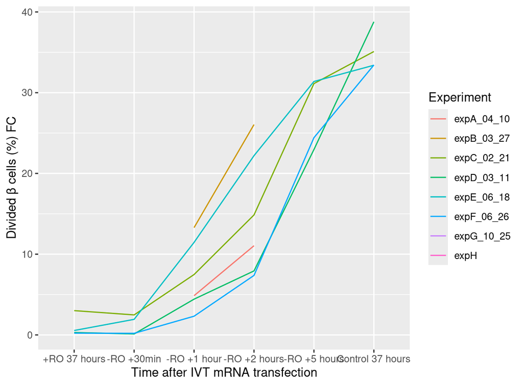

Mean proportion of divided β cells (% by flow cytometry) at different time points after IVT mRNA transfection and across individual experiments

```r
data_long %>% filter(grepl('RO_DIVIDED', Table)) %>%
  ggplot(
    aes(x = Time, y = Proportion, group = Experiment, color = Experiment)
    ) +
  geom_line() +
  scale_y_continuous(
    name = "Divided β cells (%) FC"
  ) +
  scale_x_discrete(name = "Time after IVT mRNA transfection")
## Warning: Removed 12 rows containing missing values or values outside the scale range
## (`geom_line()`).
```

$\Rightarrow$ Variances appear to differ

## 25.2 Models

### 25.2.1 Choose model

AIC/BIC

**Open code**

```r
model_NR <- glmmTMB::glmmTMB(
  Proportion ~ Time,
  data = data_long %>%
    filter(
      grepl('RO_DIVIDED', Table),
      !is.na(Proportion)
    ) %>%
    mutate(Time = factor(Time)),
  REML = FALSE
)

model_RI <- glmmTMB::glmmTMB(
  Proportion ~ Time + (1 | Experiment),
  data = data_long %>%
    filter(
      grepl('RO_DIVIDED', Table),
      !is.na(Proportion)
    ) %>%
    mutate(Time = factor(Time)),
  REML = FALSE
)

model_NR_difvar <- glmmTMB::glmmTMB(
  Proportion ~ Time,
  data = data_long %>%
    filter(
      grepl('RO_DIVIDED', Table),
      !is.na(Proportion)
    ) %>%
    mutate(Time = factor(Time)),
  REML = FALSE,
  dispformula = ~ 0 + Time
)

model_RI_difvar <- glmmTMB::glmmTMB(
  Proportion ~ Time + (1 | Experiment),
  data = data_long %>%
    filter(
      grepl('RO_DIVIDED', Table),
      !is.na(Proportion)
    ) %>%
    mutate(Time = factor(Time)),
  REML = FALSE,
  dispformula = ~ 0 + Time
)

kableExtra::kable(AIC(model_NR, model_RI, model_NR_difvar, model_RI_difvar))
```

|  | df | AIC |
| --- | --- | --- |
| model_NR | 7 | 192.2521 |
| model_RI | 8 | 189.8668 |
| model_NR_difvar | 12 | 178.5181 |
| model_RI_difvar | 13 | 172.7608 |

**Open code**

```r
kableExtra::kable(BIC(model_NR, model_RI, model_NR_difvar, model_RI_difvar))
```

|  | df | BIC |
| --- | --- | --- |
| model_NR | 7 | 202.5122 |
| model_RI | 8 | 201.5927 |
| model_NR_difvar | 12 | 196.1069 |
| model_RI_difvar | 13 | 191.8153 |

Diagnostics

**Open code**

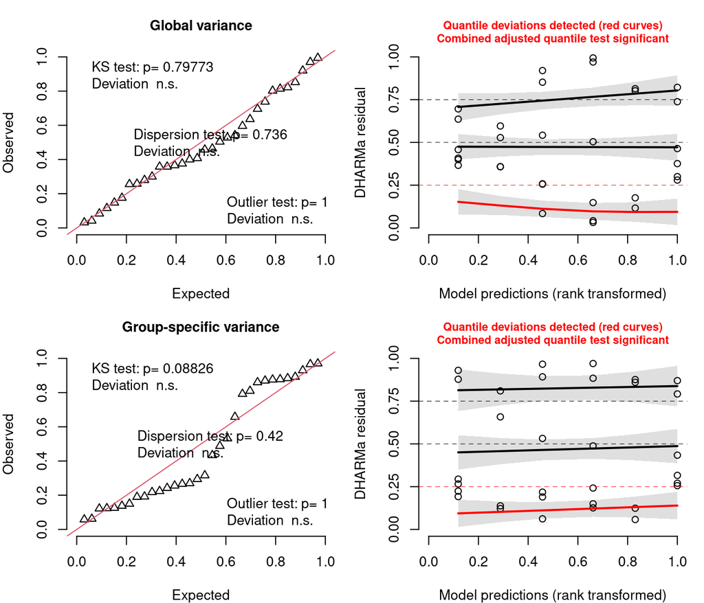

Diagnostic plots from DHARMa simulated residuals for models with and without group-specific residual variance. Top: random-intercept model with a single (global) residual variance. Bottom: random-intercept model allowing group-specific residual variance. Left: quantile–quantile plot comparing simulated residuals to the expected distribution. Right: residuals plotted against predicted values; black lines show the median (0.5) and lower/upper quartiles (0.25, 0.75) with shaded 95% simulation envelopes. Deviations from expected values suggest potential model misspecification

```r
set.seed(709)

res1 <- simulateResiduals(model_RI, n = 500)
res2 <- simulateResiduals(model_RI_difvar, n = 500)

op <- par(mfrow = c(2, 2), mar = c(4, 4, 3, 1))

plotQQunif(res1, main = "Global variance")
plotResiduals(res1, main = "")

plotQQunif(res2, main = "Group-specific variance")
plotResiduals(res2, main = "")
```

**Open code**

```r
par(op)
```

$\Rightarrow$ Allowance of group-specific residual variance notably improves AIC and BIC and will be thus retained. Although diagnostics shows a slight breaking of assumptions, allowance of the group-specific residual variance did not improve it noticeably

### 25.2.2 Fit final model

**Open code**

```r
model_final <- glmmTMB::glmmTMB(
  Proportion ~ Time + (1 | Experiment),
  data = data_long %>%
    filter(
      grepl('RO_DIVIDED', Table),
      !is.na(Proportion)
    ),
  REML = TRUE,
  dispformula = ~ 0 + Time
)
```

### 25.2.3 Results

**Open code**

```r
kableExtra::kable(car::Anova(model_final))
## Warning in printHypothesis(L, rhs, names(b)): one or more coefficients in the hypothesis include
##      arithmetic operators in their names;
##   the printed representation of the hypothesis will be omitted
```

|  | Chisq | Df | Pr(>Chisq) |
| --- | --- | --- | --- |
| Time | 968.2491 | 5 | 0 |

**Open code**

```r
summary(model_final)
##  Family: gaussian  ( identity )
## Formula:          Proportion ~ Time + (1 | Experiment)
## Dispersion:                  ~0 + Time
## Data: data_long %>% filter(grepl("RO_DIVIDED", Table), !is.na(Proportion))
##
##      AIC      BIC   logLik deviance df.resid
##    161.4    180.5    -67.7    135.4       25
##
## Random effects:
##
## Conditional model:
##  Groups     Name        Variance Std.Dev.
##  Experiment (Intercept) 1.713    1.309
##  Residual                  NA       NA
## Number of obs: 32, groups:  Experiment, 6
##
## Conditional model:
##                      Estimate Std. Error z value Pr(>|z|)
## (Intercept)            1.3517     0.6262   2.158   0.0309 *
## Time-RO +30min         0.1152     0.3823   0.301   0.7632
## Time-RO +1 hour        5.9550     1.3768   4.325 1.52e-05 ***
## Time-RO +2 hours      13.5583     2.7308   4.965 6.87e-07 ***
## Time-RO +5 hours      26.4102     1.6713  15.802  < 2e-16 ***
## TimeControl 37 hours  34.1250     1.3452  25.368  < 2e-16 ***
## ---
## Signif. codes:  0 '***' 0.001 '**' 0.01 '*' 0.05 '.' 0.1 ' ' 1
##
## Dispersion model:
##                      Estimate Std. Error z value Pr(>|z|)
## Time+RO 37 hours      -0.2229     0.3758  -0.593 0.553164
## Time-RO +30min        -8.9719   571.5528  -0.016 0.987476
## Time-RO +1 hour        1.1867     0.3251   3.650 0.000263 ***
## Time-RO +2 hours       1.8933     0.3186   5.942 2.82e-09 ***
## Time-RO +5 hours       1.1799     0.4082   2.890 0.003851 **
## TimeControl 37 hours   1.1620     0.3235   3.592 0.000328 ***
## ---
## Signif. codes:  0 '***' 0.001 '**' 0.01 '*' 0.05 '.' 0.1 ' ' 1

contrast <- con_tab(model_final)

kableExtra::kable(
  contrast,
  caption = "Estimated pairwise differences in the proportion of divided β cells (%; flow cytometry), obtained from a linear mixed-effects model with experiment as a random intercept, time as a categorical predictor, and with allowance of group-specific residual variance. Columns: `contrast` (time points compared), `estimate` (mean difference in %), `CI` (Bonferroni-adjusted 95% confidence interval [lower, upper]), `SE` (standard error), `df` (degrees of freedom), `t.ratio` (test statistic), `p.value` (Bonferroni-adjusted p-value), and `stars` (significance code)"
)
```

Estimated pairwise differences in the proportion of divided β cells (%; flow cytometry), obtained from a linear mixed-effects model with experiment as a random intercept, time as a categorical predictor, and with allowance of group-specific residual variance. Columns: `contrast` (time points compared), `estimate` (mean difference in %), `CI` (Bonferroni-adjusted 95% confidence interval [lower, upper]), `SE` (standard error), `df` (degrees of freedom), `t.ratio` (test statistic), `p.value` (Bonferroni-adjusted p-value), and `stars` (significance code)

| contrast | estimate | CI | SE | df | t.ratio | p.value | stars |
| --- | --- | --- | --- | --- | --- | --- | --- |
| (+RO 37 hours) - (-RO +30min) | -0.12 | [-1.36, 1.12] | 0.38 | 25 | -0.30 | 1.0000000 | ns |
| (+RO 37 hours) - (-RO +1 hour) | -5.96 | [-10.42, -1.49] | 1.38 | 25 | -4.33 | 0.0032122 | ** |
| (+RO 37 hours) - (-RO +2 hours) | -13.56 | [-22.42, -4.70] | 2.73 | 25 | -4.96 | 0.0006122 | *** |
| (+RO 37 hours) - (-RO +5 hours) | -26.41 | [-31.83, -20.99] | 1.67 | 25 | -15.80 | 0.0000000 | *** |
| (+RO 37 hours) - Control 37 hours | -34.12 | [-38.49, -29.76] | 1.35 | 25 | -25.37 | 0.0000000 | *** |
| (-RO +30min) - (-RO +1 hour) | -5.84 | [-10.23, -1.45] | 1.35 | 25 | -4.32 | 0.0032647 | ** |
| (-RO +30min) - (-RO +2 hours) | -13.44 | [-22.26, -4.62] | 2.72 | 25 | -4.95 | 0.0006444 | *** |
| (-RO +30min) - (-RO +5 hours) | -26.30 | [-31.57, -21.02] | 1.63 | 25 | -16.16 | 0.0000000 | *** |
| (-RO +30min) - Control 37 hours | -34.01 | [-38.29, -29.73] | 1.32 | 25 | -25.77 | 0.0000000 | *** |
| (-RO +1 hour) - (-RO +2 hours) | -7.60 | [-17.41, 2.20] | 3.02 | 25 | -2.52 | 0.2805187 | ns |
| (-RO +1 hour) - (-RO +5 hours) | -20.46 | [-27.32, -13.59] | 2.12 | 25 | -9.67 | 0.0000000 | *** |
| (-RO +1 hour) - Control 37 hours | -28.17 | [-34.23, -22.11] | 1.87 | 25 | -15.08 | 0.0000000 | *** |
| (-RO +2 hours) - (-RO +5 hours) | -12.85 | [-23.13, -2.57] | 3.17 | 25 | -4.06 | 0.0064258 | ** |
| (-RO +2 hours) - Control 37 hours | -20.57 | [-30.33, -10.80] | 3.01 | 25 | -6.84 | 0.0000055 | *** |
| (-RO +5 hours) - Control 37 hours | -7.71 | [-14.51, -0.92] | 2.10 | 25 | -3.68 | 0.0167202 | * |

### 25.2.4 Visualisation

**Open code**

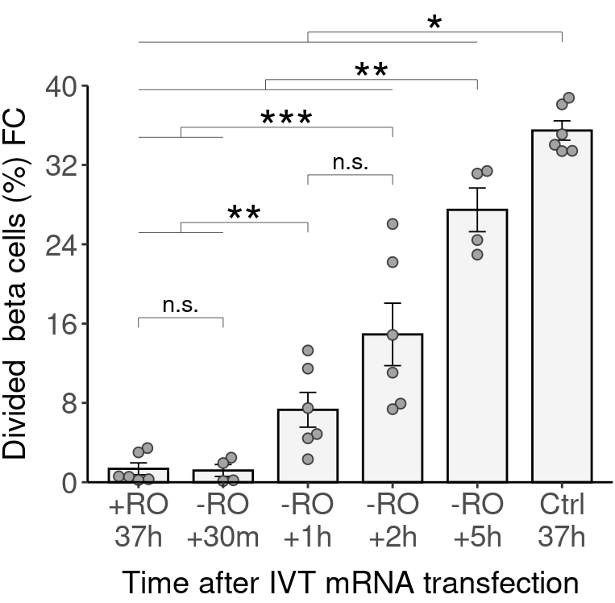

Proportion of divided beta cells (% by flow cytometry) at different time points after IVT mRNA transfection. Bars show means ± SEM. ***, P < 0.001; **, P < 0.01; *, P < 0.05(adjusted P-values by Bonferroni correction). Statistical significance was assessed with linear mixed-effects model, including experiment as a random effect, time as a categorical predictor, and with allowance of group-specific residual variance

```r
scale <- 10/4

p <- data_long %>%
  filter(grepl("RO_DIVIDED", Table), !is.na(Proportion)) %>%
  mutate(
    Time = gsub("Control", "Ctrl", Time),
    Time = gsub(" hour[s]?", "h", Time),
    Time = gsub("min", "m", Time),
    #Time = gsub(" ", "", Time),
    Time = fct_inorder(Time)
  ) %>%
  ggplot(
    aes(x = Time, y = Proportion)
  ) +
  stat_summary(
    fun = 'mean',
    geom = 'col',
    fill = 'grey80', color = 'black',
    width = 0.7,
    alpha = 0.2
  ) +
  stat_summary(fun.data = mean_se, geom = "errorbar", width = 0.2, linewidth = 0.324) +
  scale_y_continuous(
    breaks = seq(0, 100/scale, 20/scale),
    name = "Divided  beta cells (%) FC",
    expand = expansion(mult = c(0, 0), add = c(0, 0))
  ) +
  coord_cartesian(ylim = c(0, 100/scale), clip = "off") +
  scale_x_discrete(name = "Time after IVT mRNA transfection",
  labels = function(x) gsub(
    "(Ctrl|\\+RO|-RO)\\s*", "\\1\n", x
  )
) +
  geom_beeswarm(
    cex = 2,
    fill = 'grey64',
    size = 1.92,
    shape = 21,
    color = rgb(0.2, 0.2, 0.2, 0.9),
    stroke = 0.5
  ) +
  theme_classic() +
  theme(
    plot.margin = margin(t = 40, r = 1, b = 1, l = 1),
    axis.text.x = element_text(size = ax_text3),
    axis.text.y = element_text(size = ax_text3),
    axis.title.x = element_text(size = tit_text3, margin = margin(t = mar3)),
    axis.title.y = element_text(size = tit_text3, margin = margin(r = 6))
  )

start <- 115/scale
tr <- 0
byp <- 12/scale

p <- add_starm(6, c(1:5), start - tr, '*', scal = scale); tr <-  tr + byp
p <- add_starm(5, c(1:4), start - tr, '**', scal = scale); tr <-  tr + byp
p <- add_starm(4, c(1:2), start - tr, '***', scal = scale); tr <-  tr + byp
p <- add_starm(4, 3, start - tr, '<sup>n.s.</sup>', scal = scale); tr <-  tr + byp
p <- add_starm(3, c(1:2), start - tr, '**', scal = scale); tr <-  tr + byp*2
p <- add_starm(1, 2, start - tr, '<sup>n.s.</sup>', scal = scale)

p
```

**Open code**

```r
if (!file.exists("gitignore/figures/fig_22.pdf")) {
  ggsave(
    "gitignore/figures/fig_22.pdf",
    plot = p,
    width = figw5,
    height = figh5,
    units = "in")

  ggsave(
    "gitignore/figures/fig_22.svg",
    plot = p,
    width = figw5,
    height = figh5,
    units = "in")
  }
```

### 25.2.5 Summary statistics over timpoints

**Open code**

```r
kableExtra::kable(
  data_long %>%
    dplyr::filter(grepl("RO_DIVIDED", Table)) %>%
    tidyr::drop_na(Proportion) %>%
    dplyr::group_by(Time) %>%
    dplyr::summarise(
      mean = mean(Proportion),
      median = quantile(Proportion, probs = 0.5),
      SD = sd(Proportion),
      SEM = sem(Proportion)
    ),
  caption = "Summary statistics for the proportion of divided  beta cells (% by flow cytometry) at different time points after IVT mRNA transfection. Mean, median, SD, and SEM are shown; SD, standard deviation; SEM, standard error of the mean"
)
```

Summary statistics for the proportion of divided beta cells (% by flow cytometry) at different time points after IVT mRNA transfection. Mean, median, SD, and SEM are shown; SD, standard deviation; SEM, standard error of the mean

| Time | mean | median | SD | SEM |
| --- | --- | --- | --- | --- |
| +RO 37 hours | 1.351667 | 0.570 | 1.464287 | 0.5977927 |
| -RO +30min | 1.182500 | 1.065 | 1.202286 | 0.6011430 |
| -RO +1 hour | 7.306667 | 6.170 | 4.294385 | 1.7531755 |
| -RO +2 hours | 14.910000 | 12.955 | 7.716447 | 3.1502264 |
| -RO +5 hours | 27.477500 | 27.780 | 4.409969 | 2.2049844 |
| Control 37 hours | 35.476667 | 34.570 | 2.389717 | 0.9755978 |

# 26 RO Cell cycle occupation by FC

## 26.1 Create relavant datasets

**Open code**

```r
## to get means
data_occup <- data_long %>%
  mutate(
    Time = gsub(" hour[s]?", "h", gsub("Control", "Ctrl", Time))
  ) %>%
  filter(
    grepl('RO_Cell_cycle_occupation', Table)
  ) %>%
  tidyr::drop_na(Proportion) %>%
  rename(
    Population = `Name.of.population`
  ) %>%
  dplyr::select(Time, Population, Proportion) %>%
  pivot_wider(
    names_from = Population,
    values_from = Proportion,
    values_fn = mean
  ) %>%
  mutate(Other = 100 - `S EdU+` - `G0G1 EdU-` -  `G2M EdU+` - `DIVIDED` - `2nd S`)

data_occup
## # A tibble: 6 × 7
##   Time       `G0G1 EdU-` `S EdU+` `G2M EdU+` DIVIDED `2nd S`    Other
##   <chr>            <dbl>    <dbl>      <dbl>   <dbl>   <dbl>    <dbl>
## 1 +RO 37h           28.8    12.7        56.9    1.35   9.63  -9.40
## 2 -RO +30min        31.6    14.6        52.5    1.18   0.19   0.00750
## 3 -RO +1h           30.0    11.3        51.2    7.31   0.232 -0.0900
## 4 -RO +2h           27.9    11.3        45.7   14.9    0.142  0.0233
## 5 -RO +5h           28.0     7.96       36.1   27.5    0.195  0.300
## 6 Ctrl 37h          21.3     4.84       28.7   35.5    0.495  9.13

## to get SEM
sem_df <- data_long %>%
  mutate(
    Time = gsub(" hour[s]?", "h", gsub("Control", "Ctrl", Time))
  ) %>%
  filter(
    grepl('RO_Cell_cycle_occupation', Table)
  ) %>%
  tidyr::drop_na(Proportion) %>%
  rename(Population = `Name.of.population`) %>%
  group_by(Time, Population) %>%
  summarise(sem = sd(Proportion)/sqrt(n()), .groups = "drop") %>%
  left_join(data_occup, by = "Time") %>%
  mutate(
    xmid = case_when(
      Population == "G0G1 EdU-" ~ `G0G1 EdU-`,
      Population == "S EdU+" ~ `G0G1 EdU-` + `S EdU+`,
      Population == "G2M EdU+" ~ `G0G1 EdU-` + `S EdU+` + `G2M EdU+`,
      Population == "DIVIDED" ~ `G0G1 EdU-` + `S EdU+` + `G2M EdU+` + `DIVIDED`,
      Population == "2nd S" ~ `G0G1 EdU-` + `S EdU+` + `G2M EdU+` + `DIVIDED` +
        `2nd S`
  )
)

kableExtra::kable(sem_df %>% select(Time, Population, sem))
```

| Time | Population | sem |
| --- | --- | --- |
| +RO 37h | 2nd S | 1.8755793 |
| +RO 37h | DIVIDED | 0.5977927 |
| +RO 37h | G0G1 EdU- | 3.5273575 |
| +RO 37h | G2M EdU+ | 3.9505431 |
| +RO 37h | S EdU+ | 2.2466345 |
| -RO +1h | 2nd S | 0.0781629 |
| -RO +1h | DIVIDED | 1.7531755 |
| -RO +1h | G0G1 EdU- | 4.9079693 |
| -RO +1h | G2M EdU+ | 3.7979992 |
| -RO +1h | S EdU+ | 1.5882499 |
| -RO +2h | 2nd S | 0.0370060 |
| -RO +2h | DIVIDED | 3.1502264 |
| -RO +2h | G0G1 EdU- | 4.0791032 |
| -RO +2h | G2M EdU+ | 2.5645425 |
| -RO +2h | S EdU+ | 2.0993005 |
| -RO +30min | 2nd S | 0.0724569 |
| -RO +30min | DIVIDED | 0.6011430 |
| -RO +30min | G0G1 EdU- | 5.8537629 |
| -RO +30min | G2M EdU+ | 5.0961577 |
| -RO +30min | S EdU+ | 2.4326957 |
| -RO +5h | 2nd S | 0.0421703 |
| -RO +5h | DIVIDED | 2.2049844 |
| -RO +5h | G0G1 EdU- | 4.4418737 |
| -RO +5h | G2M EdU+ | 3.4748022 |
| -RO +5h | S EdU+ | 1.2643271 |
| Ctrl 37h | 2nd S | 0.1987251 |
| Ctrl 37h | DIVIDED | 0.9755978 |
| Ctrl 37h | G0G1 EdU- | 4.4151600 |
| Ctrl 37h | G2M EdU+ | 2.6345985 |
| Ctrl 37h | S EdU+ | 0.3284247 |

## 26.2 Plot

**Open code**

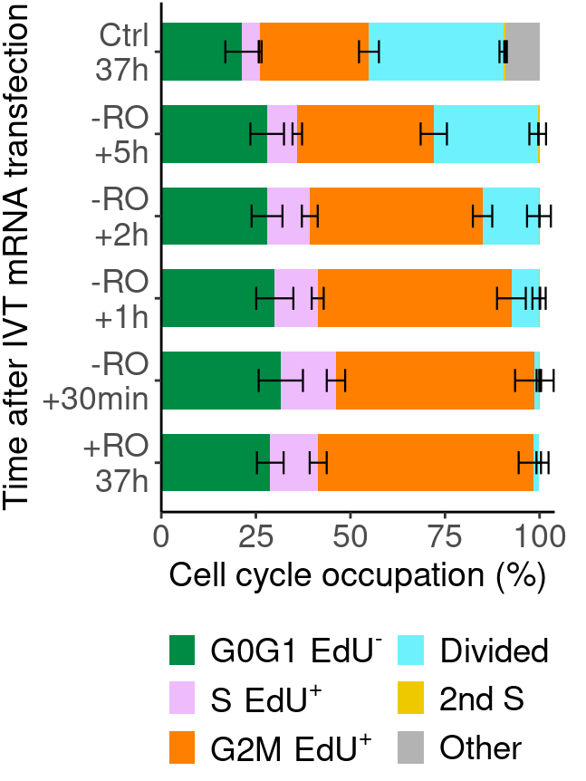

Proportion of beta cells in G0G1 EdU⁻, S EdU⁺, G2M EdU⁺, Divided and 2nd S phase (% by flow cytometry) at different time points after IVT mRNA transfection. Bars show means ± SEM (for individual phases; “Other” calculated as 100% − G0G1 EdU⁻ − S EdU⁺ − G2M EdU⁺ − Divided − 2nd S)

```r
p <- data_occup %>%
  tidyr::pivot_longer(
    cols = c(`G0G1 EdU-`, `S EdU+`, `G2M EdU+`, `DIVIDED`, `2nd S`, Other),
    names_to = "Phase",
    values_to = "Percent"
  ) %>%
  dplyr::mutate(
    Phase = factor(
      Phase,
      levels = c("Other", "2nd S", "DIVIDED", "G2M EdU+", "S EdU+", "G0G1 EdU-")
    )
  ) %>%
   dplyr::mutate(Time = factor(
    Time,
    levels = c(
      "+RO 37h",
      "-RO +30min",
      "-RO +1h",
      "-RO +2h",
      "-RO +5h",
      "Ctrl 37h"
    )
  )) %>%
  ggplot(
    aes(
      y = Time,
      x = Percent,
      fill = Phase
    )
  ) +
  geom_col(width = 0.7) +
  scale_fill_manual(
    values = c(
      "G0G1 EdU-" = "springgreen4",
      "S EdU+" = "#EEBBFC",
      "G2M EdU+" = "darkorange1",
      "DIVIDED" = "#6DF1FC",
      "2nd S" = "gold2",
      "Other" = "grey70"
    ),
    breaks = c("G0G1 EdU-", "S EdU+", "G2M EdU+", "DIVIDED", "2nd S", "Other"),
    labels = c(
  "G0G1 EdU-" = expression(G0G1~EdU^"-"),
  "S EdU+"    = expression(S~EdU^"+"),
  "G2M EdU+"  = expression(G2M~EdU^"+"),
  "DIVIDED"   = "Divided",
  "2nd S"     = "2nd S",
  "Other"     = "Other"
),
    name = NULL
  ) +
  labs(
    x = "Cell cycle occupation (%)",
    y = "Time after IVT mRNA transfection"
  ) +
  scale_x_continuous(
    limits = c(0, 104),
    expand = expansion(mult = c(0, 0), add = c(0, 0))
  ) +
  scale_y_discrete(
    labels = function(x) {
      gsub(
        "(Ctrl|\\+RO|-RO)\\s*", "\\1\n", x
      )
    }
  ) +
  theme_classic() +
  theme(
    axis.line.y = element_line(color = "black"),
    axis.line.x = element_line(color = "black"),
    legend.position = "bottom",
    plot.margin = margin(t = 1, r = 13, b = 1, l = 1),
    axis.text.x = element_text(size = ax_text4),
    axis.text.y = element_text(size = ax_text4),
    axis.title.x = element_text(size = tit_text4),
    axis.title.y = element_text(size = tit_text4),
    legend.text = element_text(size = leg_text4),
    legend.key.size = unit(0.85, "lines")
  ) +
  guides(
    fill = guide_legend(nrow = 3)
  ) +
  geom_errorbarh(
    data = sem_df,
    aes(
      y = Time,
      xmin = xmid - sem,
      xmax = xmid + sem
    ),
    height = 0.28,
    inherit.aes = FALSE,
    linewidth = 0.4,
    color = "black"
  ) +
  scale_color_manual(
    guide = "none"
  )

p
## Warning: Removed 3 rows containing missing values or values outside the scale range
## (`geom_col()`).
## Warning: Removed 1 row containing missing values or values outside the scale range
## (`geom_errorbarh()`).
```

**Open code**

```r
if (!file.exists("gitignore/figures/fig_23.pdf")) {
  ggsave(
    "gitignore/figures/fig_23.pdf",
    plot = p,
    width = figw2,
    height = figh2,
    units = "in"
  )

  ggsave(
    "gitignore/figures/fig_23.svg",
    plot = p,
    width = figw2,
    height = figh2,
    units = "in"
  )
}
```

# 27 Reproducibility

**Open code**

```r
sessionInfo()
## R version 4.4.3 (2025-02-28)
## Platform: x86_64-pc-linux-gnu
## Running under: Ubuntu 22.04.5 LTS
##
## Matrix products: default
## BLAS:   /usr/lib/x86_64-linux-gnu/blas/libblas.so.3.10.0
## LAPACK: /usr/lib/x86_64-linux-gnu/lapack/liblapack.so.3.10.0
##
## locale:
##  [1] LC_CTYPE=en_US.UTF-8       LC_NUMERIC=C
##  [3] LC_TIME=cs_CZ.UTF-8        LC_COLLATE=en_US.UTF-8
##  [5] LC_MONETARY=cs_CZ.UTF-8    LC_MESSAGES=en_US.UTF-8
##  [7] LC_PAPER=cs_CZ.UTF-8       LC_NAME=C
##  [9] LC_ADDRESS=C               LC_TELEPHONE=C
## [11] LC_MEASUREMENT=cs_CZ.UTF-8 LC_IDENTIFICATION=C
##
## time zone: Europe/Prague
## tzcode source: system (glibc)
##
## attached base packages:
## [1] stats     graphics  grDevices utils     datasets  methods   base
##
## other attached packages:
##  [1] DHARMa_0.4.7      ggbeeswarm_0.6.0  pROC_1.18.0       arm_1.12-2
##  [5] lme4_1.1-35.5     Matrix_1.7-0      MASS_7.3-65       car_3.1-2
##  [9] carData_3.0-5     emmeans_1.10.4    brms_2.21.0       Rcpp_1.1.0
## [13] rmsb_1.1-1        rms_6.8-1         Hmisc_5.1-3       nlme_3.1-168
## [17] glmmTMB_1.1.9     ggdist_3.3.2      cowplot_1.1.1     ggpubr_0.4.0
## [21] sjPlot_2.8.16     kableExtra_1.4.0  flextable_0.9.6   gtsummary_2.4.0
## [25] janitor_2.2.0     stringi_1.8.7     lubridate_1.9.4   forcats_1.0.0
## [29] stringr_1.5.1     dplyr_1.1.4       purrr_1.0.4       readr_2.1.5
## [33] tidyr_1.3.1       tibble_3.3.0      ggplot2_3.5.1     tidyverse_1.3.1
## [37] openxlsx_4.2.8    RJDBC_0.2-10      rJava_1.0-11      DBI_1.2.3
## [41] rstudioapi_0.16.0
##
## loaded via a namespace (and not attached):
##   [1] splines_4.4.3           later_1.4.7             polspline_1.1.25
##   [4] cellranger_1.1.0        datawizard_0.12.2       reprex_2.0.1
##   [7] rpart_4.1.24            lifecycle_1.0.4         Rdpack_2.1.4
##  [10] rstatix_0.7.0           doParallel_1.0.17       StanHeaders_2.32.10
##  [13] lattice_0.22-5          insight_1.5.2           backports_1.5.0
##  [16] magrittr_2.0.4          rmarkdown_2.27          yaml_2.3.10
##  [19] httpuv_1.6.5            otel_0.2.0              gap_1.6
##  [22] zip_2.2.0               askpass_1.1             pkgbuild_1.4.8
##  [25] minqa_1.2.4             multcomp_1.4-18         abind_1.4-5
##  [28] rvest_1.0.2             tensorA_0.36.2.1        nnet_7.3-20
##  [31] TH.data_1.1-0           sandwich_3.0-1          gdtools_0.3.7
##  [34] inline_0.3.19           crul_1.5.0              MatrixModels_0.5-3
##  [37] performance_0.12.2      bridgesampling_1.1-2    commonmark_1.9.1
##  [40] svglite_2.1.3           codetools_0.2-19        ggtext_0.1.2
##  [43] xml2_1.4.1              tidyselect_1.2.1        farver_2.1.0
##  [46] bayesplot_1.8.1         ggeffects_1.7.0         httpcode_0.3.0
##  [49] matrixStats_1.3.0       stats4_4.4.3            base64enc_0.1-3
##  [52] jsonlite_2.0.0          Formula_1.2-4           iterators_1.0.14
##  [55] ggridges_0.5.3          survival_3.7-0          systemfonts_1.0.4
##  [58] foreach_1.5.2           tools_4.4.3             ragg_1.4.0
##  [61] glue_1.8.0              gridExtra_2.3           xfun_0.52
##  [64] mgcv_1.9-1              distributional_0.4.0    loo_2.4.1
##  [67] withr_3.0.2             numDeriv_2016.8-1.1     fastmap_1.2.0
##  [70] boot_1.3-31             SparseM_1.81            openssl_1.4.6
##  [73] digest_0.6.37           timechange_0.3.0        R6_2.6.1
##  [76] mime_0.12               estimability_1.5.1      textshaping_0.3.6
##  [79] colorspace_2.0-2        markdown_1.13           utf8_1.2.6
##  [82] generics_0.1.4          fontLiberation_0.1.0    data.table_1.18.4
##  [85] httr_1.4.2              htmlwidgets_1.6.4       pkgconfig_2.0.3
##  [88] gtable_0.3.0            htmltools_0.5.8.1       fontBitstreamVera_0.1.1
##  [91] TMB_1.9.14              scales_1.3.0            posterior_1.6.0
##  [94] snakecase_0.11.1        knitr_1.50              tzdb_0.5.0
##  [97] uuid_1.0-3              coda_0.19-4.1           checkmate_2.3.2
## [100] curl_6.4.0              nloptr_2.0.0            zoo_1.8-9
## [103] sjlabelled_1.2.0        vipor_0.4.5             parallel_4.4.3
## [106] foreign_0.8-90          pillar_1.11.0           grid_4.4.3
## [109] vctrs_0.6.5             promises_1.5.0          dbplyr_2.1.1
## [112] xtable_1.8-4            cluster_2.1.8.1         beeswarm_0.4.0
## [115] htmlTable_2.4.0         evaluate_1.0.5          mvtnorm_1.1-3
## [118] cli_3.6.5               compiler_4.4.3          rlang_1.1.6
## [121] crayon_1.5.3            rstantools_2.1.1        ggsignif_0.6.3
## [124] labeling_0.4.2          modelr_0.1.8            plyr_1.8.6
## [127] sjmisc_2.8.10           fs_1.6.6                gap.datasets_0.0.6
## [130] rstan_2.32.6            viridisLite_0.4.0       QuickJSR_1.3.1
## [133] assertthat_0.2.1        munsell_0.5.0           Brobdingnag_1.2-7
## [136] V8_4.4.2                quantreg_5.98           fontquiver_0.2.1
## [139] sjstats_0.19.0          hms_1.1.3               qgam_2.0.0
## [142] gfonts_0.2.0            shiny_1.9.1             haven_2.4.3
## [145] rbibutils_2.2.7         gridtext_0.1.5          broom_1.0.10
## [148] RcppParallel_5.1.8      readxl_1.3.1            officer_0.6.6
```